# INFERÈNCIA CAUSAL GEOMÈTRICA: causalitat com a estructura geomètrica de l’espai-temps Mètode de conversió de pathways a un model causal geomètric 3D i validació empírica multiescala del graf resultant

david graupere villà

2025-09-25

# **TESI DE MÀSTER EN BIOESTADÍSTICA I BIOINFORMÀTICA UOC-UB**

# **INFERÈNCIA CAUSAL GEOMÈTRICA: causalitat com a estructura geomètrica de l’espai-temps**

# *Mètode de conversió de pathways a un model causal geomètric 3D i validació empírica multiescala del graf resultant*

# **1. Taula de continguts**

# **2. Abstract o resum**

In this work we introduce a Geometric Causal Model (GCM), a novel extension af standard DAGs thta embeds causal structure into a three-dimensional coordinate system in which axes represent causal dependency, causal effect, and hierarchical causal depth. This geometric representation allows for consistency checks, detection of spurious edges, and a topogeometric validation of causal flow.

# **3. Objectius**

## *3.1 Descripció metodològica de conversió de pathways a un model causal geomètric*

## *3.2 Validació causal geomètrica local estadística: tests d’independència condicionada*

## *3.2 Validació multiescala per machine learning o aprenentatge estadístic*

## *Random Forests (variables), SVM (validació local) i ANN/CNN (validació global)*

5.b.1. Validació de rellevància de les variables (nodes) mitjançant Random Forests, per avaluar la influència dels nodes sobre el model causal. 5.b.2. Validació local de les relacions locals d’arestes horitzontals amb SVM; cal avaluar una a una i en combinació quines arestes milloren o empitjoren la capacitat explicativa i/o predictiva del model.  
5.b.3. Validació global del DAG complet mitjançant ANN/CNN per avaluar la millora o deteriorament en predicció (també pot explorar-se l’efecte d’una cross edge en termes globals amb la seva inclusió i exclusió). 5.b.4. Integració dels resultats obtinguts a les tres escales (variable, local, global), i extracció de conclusions sobre la validesa i aplicabilitat del mètode.

# **4. Mètode**

Per mitjà d’un codi en R, primer hom trasllada un pathway biomèdic com a graf acíclic dirigit 2D (DAG); en segon lloc, en el marc de la teoria de grafs, tot seguit, hom descompon el DAG 2D en dos subgrafs com a subgrafs (vertical o de jerarquia i retrolaterals o de cross edges). Aquesta descomposició permet una anàlisi de les tres dimensions que hi ha a l’estructura subjacent del DAG i fer-ne la conversió a un model causal geomètric.

La descomposició dels subgrafs és un primer estadi, permeten copsar el DAG 2D de forma òptima, per exemple en termes d’estructura, quina mena de nodes uneixen els dos subgrafs (en aquest estudi són col·lididors-fulla, un únic vertical i la resta retroverticals); ara bé, a fi d’aplicar-hi inferència causal, cal arribar fins al model causal geomètric topoempíric.

Tot seguit validar experimentalment el model causal geomètric mitjançant tests locals i la tríada d’aprenentatge estadístic.

# **5. Anàlisi crítica dels resultats**

# **6. Discussió sobre l’aplicabilitat i l’abast del nou mètode**

6.1

cal tenir en compte que m’he trobat amb un món del tot nou i que cal crear eines per tal de navegar-hi, d’aquí que hi hagin situacions o objectes nous que requereixen la creació de tractaments o l’elaboració de conceptes per tal de manipular-los.

La gran quantitat de pathways (cascada de processos, xarxa bioquímica, via de senyalització…o en d’altres disciplines és anomenat com a diagrama de flux, sistema de control, pathway de transició, cadenes tròfiques, workflow…) que hi han, no sols en biologia o medicina sinó en tants d’altres camps, conté una gran quantitat d’informació sintetitzada després de molts d’anys de recerca, assaigs i articles; aquesta informació té una gran vàlua empírica, en esser la síntesi de l’estat de la qüestió no hi han unes dades registrades concretes que acompanyin el pathway en el seu marc global però també és informació empírica i molt robusta. En el marc de l’assignatura del màster de Biologia Estructural, hi ha una gran quantitat de malalties descrites com a pathway

# **7. Conclusions**

possibles línies de continuació de desenvolupament del mètode

El cas d’estudi de Sachs et al. és emprat com a banc de proves (golden standard), tanmateix hom no pretén que la comparança de resultats sigui una reproducció exacta, sinó que hi hagi una convergència en la coherència dels resultats. Tot i que el mètode proposat no té precedents directes i suposa un repte dotar-lo d’eines i de claus d’interpretació, els resultats són prou coherents amb els resultats de l’article original. També cal tenir en compte que és una metodologia en desenvolupament. Dit això, atès que els resultats en inferència causal del mètode semblen convergir amb els resultats de Sachs et al., hom publica aquest mètode a dins dels repositoris GitHub i Zenodo a fi de facilitar-ne la reutilització, del codi i la verificació del mètode per part d’altres recercadors.

# **8. Referències**

## *8.1 Llibres constitutius*

==> *Bosch Rué, Anna et al.*, Deep learning principios y fundamentos Editorial UOC 2025 ==> *Babette A.Brumback* 2022, Fundamentals of Causal Inference: With R (Chapman & Hall/CRC Texts in Statistical Science) ==> *Babette A.Brumback* 2022 Odd Exercises Solutions Manual for Fundamentals of Causal Inference (versió gairebé completa 59 pàg.) ==> *Castellví, Jordi* combinatòria i teoria de grafs FME 2020 ==> *Chollet, François* Deep Learning with R Manning Publications 2017 ==> *Genuer, Robin et al.* Random Forests with R Springer 2020 https://doi.org/10.1007/978-3-030-56485-8 ==> *Lefebvre, François* 2022, Study project Brumback: Fundamentals of Causal Inferences With R Tidyverse, https://franklef.github.io/FundamentalsCausalInference/index.html ==> *Lantz, Brett* Machine Learning with R Packt Publishing 2015 ==> *Pearl, Judea; Glymour, Madelyn; Jewell,Nicholas P.* 2016, Causal Inference in Statistics A Primer ==> *Pearl, Judea; Glymour, Madelyn; Jewell,Nicholas P.* (Text Authors) & Judea Pearl, Ang Li, Andrew Forney, and Johannes Textor (Solution Authors) Causal Inference in Statistics: A Primer Solution Manual (versió completa 76 pàg.) ==> *Kowalczyk, Alexandre* Support Vector Machines Succinctly Syncfusion 2017 ==> *Rocafort, Alfredo & Amat, Oriol*, 2017, Com fer recerca (treball de fi de grau, tesi de màster, tesi doctoral i altres projectes de recerca) ==> *Trias Pairó, Joan* Matemàtica discreta. Problemes resolts EDICIONS UPC 2001

## *8.2 Llibres consultius*

==>Cobo Erik et al., 2007, Bioestadística Para no Estadísticos. Bases Para Interpretar Artículos Científicos ==>Cunningham Scott, 2021, Causal Inference The Mixtape ==>Lash Timothy L. et al., 2021, Modern Epidemiology ==>Nguyen Mike, 2023, A Guide on Data Analysis ==>https://bookdown.org/mike/data_analysis/ ==>Rosenbaum Paul R., 2017, Observation and Experiment An Introduction to Causal Inference ==>Shipley Bill, 2016, Cause and Correlation in Biology

## *8.3 Treballs acadèmics: TFG, TFM, Tesis, Seminaris*

Bougioukas Konstantinos I., 2023, Practical Statistics in Medicine with R https://bougioukas-medstats-r.netlify.app/ Macías Piguave, d’Amanda Elizabeth, 2022, TFM Grafs Acíclics Dirigits (DAGs) i reproductibilitat d’estudis observacionals https://upcommons.upc.edu/handle/2117/362818

## *8.4 Articles*

Suchs, Karen et al. Causal Protein-Signaling Networks Derived from Multiparameter Single-Cell Data Article in Science · May 2005 DOI: 10.1126/science.1105809 · Source: PubMed https://www.researchgate.net/publication/7891495

Ankan Ankur Testing Graphical Causal Models Using the R Package “dagitty” Current Protocols, 1, e45. doi: 10.1002/cpz1.45 https://currentprotocols.onlinelibrary.wiley.com/doi/10.1002/cpz1.45

Tennant Peter WG et al., 2019, Use of directed acyclic graphs (DAGs) in applied health research: review and recommendations https://pubmed.ncbi.nlm.nih.gov/33330936/

Bengio Yoshua et al. Deep learning 8 MAY 2015 doi:10.1038/nature14539 https://www.nature.com/articles/nature14539

# **ANNEX1 CODI R COMENTAT**

```r
knitr::opts_chunk$set(rgl = TRUE)
#a la consola , no a dins del Rmd
#install.packages("remotes")
#remotes::install_github("jtextor/dagitty/r")
library(dagitty)
library(ggdag)
```

```r
library(graph)
library(igraph)
library(rgl)
library(ggplot2)
library(plot3D)
library(scales)
library(dplyr)
packageVersion("dagitty")
```

```
## [1] '0.3.4'
```

```r
packageVersion("ggdag")
```

```
## [1] '0.2.13'
```

```r
packageVersion("igraph")
```

```
## [1] '2.1.4'
```

```r
packageVersion("graph")
```

```
## [1] '1.82.0'
```

Hom carrega l’aplec de dades

```r
dades <- read.csv("C:/Users/graup/Desktop/TFM/protocol3/protein_signal.csv")
head(dades)
```

|  | Raf | Mek | Plcg | PIP2 | PIP3 | Erk | Akt | PKA | PKC | P38 | Jnk |
| --- | --- | --- | --- | --- | --- | --- | --- | --- | --- | --- | --- |
| 1 | 3.179665 | 3.030625 | 3.222752 | 2.836624 | 3.386284 | 1.910165 | 2.179628 | 3.464657 | 3.705143 | 3.921797 | 3.566766 |
| 2 | 3.313155 | 3.127535 | 3.367189 | 2.799483 | 2.527001 | 2.359419 | 2.461049 | 3.394200 | 3.002324 | 3.487035 | 3.753581 |
| 3 | 3.531847 | 3.554489 | 3.441636 | 2.582776 | 2.730851 | 2.263097 | 2.461049 | 3.452962 | 3.531599 | 3.773342 | 3.254741 |
| 4 | 3.621384 | 3.828081 | 3.640896 | 2.704508 | 1.727649 | 1.855651 | 2.021082 | 3.570291 | 3.611415 | 3.725917 | 3.328318 |
| 5 | 3.285691 | 3.206716 | 2.992451 | 2.562289 | 3.011359 | 2.414187 | 2.612864 | 3.331957 | 3.143080 | 3.679484 | 3.874796 |
| 6 | 3.032219 | 2.484086 | 3.522796 | 2.918565 | 2.654335 | 2.165465 | 2.359102 | 3.632987 | 3.611415 | 3.960633 | 3.726634 |

# **1. REDUCCIÓ D’UN PATHWAY SENSE CICLES A ARBRE**

## *1.1 Representació del pathway o network biològic (xarxa de dependències direccionals)*

Aquest pathway o network conté retroalimentacions funcionals o feedbacks biològics a fi de fer-lo coherent amb la bioquímica coneguda, però abans de passar a un arbre hauran d’esser tractades perquè els cicles no són acceptats per definició d’arbre ni tampoc per definició de DAG en 2D (al model geomètric hom veu que sí que podrien esser possibles cicles locals sense comprometre l’acilcicitat general)

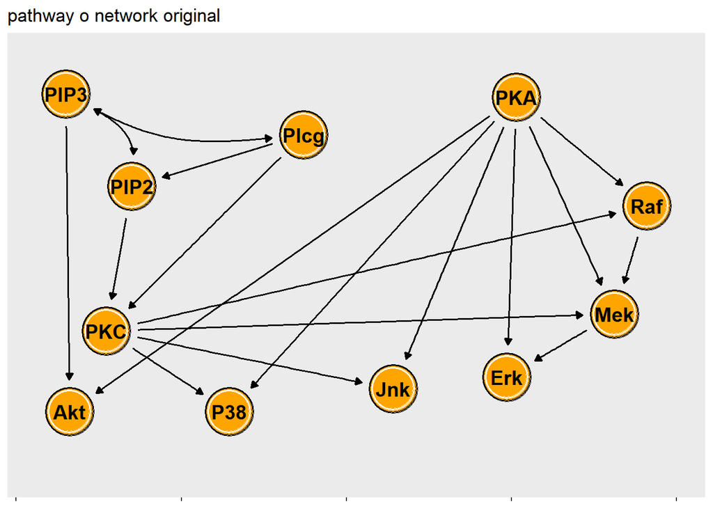

```r
pathway <- dagitty('dag {

bb="-0.5,-0.5,0.5,0.5"
Akt [pos="-0.419,0.379"]
Erk [pos="0.243,0.289"]
Jnk [pos="0.071,0.320"]
Mek [pos="0.406,0.126"]
P38 [pos="-0.177,0.378"]
PIP2 [pos="-0.325,-0.203"]
PIP3 [pos="-0.425,-0.442"]
PKA [pos="0.257,-0.434"]
PKC [pos="-0.364,0.170"]
Plcg [pos="-0.065,-0.337"]
Raf [pos="0.455,-0.153"]

PIP3 <-> PIP2
PIP3 <-> Plcg

Mek -> Erk
PIP2 -> PKC
PIP3 -> Akt
PKA -> Akt
PKA -> Erk
PKA -> Jnk
PKA -> Mek
PKA -> P38
PKA -> Raf
PKC -> Jnk
PKC -> Mek
PKC -> P38
PKC -> Raf
Plcg -> PIP2
Plcg -> PKC
Raf -> Mek
}
')


ggdag(pathway) +

  geom_dag_node(color = "orange", size = 15) +
  geom_dag_text(color = "black", size = 5) +
  coord_cartesian(ylim = rev(c(-0.5,0.5)))+

  ggtitle("pathway o network original") +
  theme ( panel.grid = element_blank(),
          axis.text = element_blank(),
          axis.title = element_blank())
```

El nombre d’arestes

```r
arestes_pathway <- node_status(pathway)$data
table(arestes_pathway[,4])
```

```
## direction
##  -> <->  --
##  16   2   0
```

## *1.2 Garantir l’aciclicitat general abans de reduir el pathway a arbre/bosc*

A més a més, és normal que les relacions bioquímiques puguin esser recíproques (feeback, cross-talks i cicles) però en un moment determinat del sistema cel·lular hi ha un flux predominant d’informació (d’estímul a resposta), per tant, una direcció causal efectiva que no nega tanmateix la reciprocitat biològica. D’aquí que Sachs i el seu equip parlin d’unidireccionalitat funcional; per exemple, PIP3 és la causa de canvi observat a Plcg, per tant, PIP3->Plcg; també amb PIP3->PIP2, atès que PIP3 és considerat qui genera el senyal (upstream).

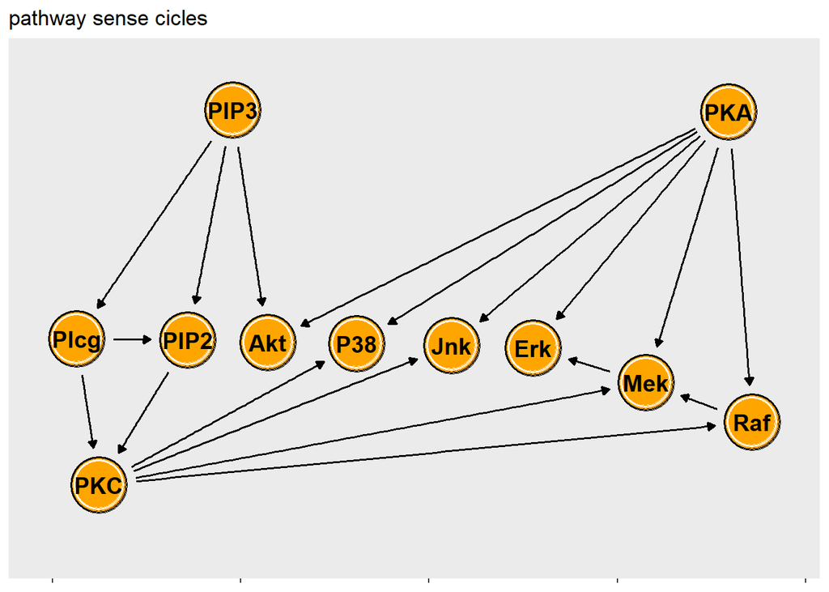

```r
pathway_net <- dagitty('dag {
bb="-0.5,-0.5,0.5,0.5"
Akt [pos="-0.214,0.076"]
Erk [pos="0.138,0.088"]
Jnk [pos="0.030,0.082"]
Mek [pos="0.288,0.165"]
P38 [pos="-0.096,0.079"]
PIP2 [pos="-0.320,0.071"]
PIP3 [pos="-0.261,-0.441"]
PKA [pos="0.398,-0.437"]
PKC [pos="-0.438,0.392"]
Plcg [pos="-0.468,0.067"]
Raf [pos="0.429,0.253"]
Mek -> Erk
PIP2 -> PKC
PIP3 -> Akt
PIP3 -> PIP2
PIP3 -> Plcg
PKA -> Akt
PKA -> Erk
PKA -> Jnk
PKA -> Mek
PKA -> P38
PKA -> Raf
PKC -> Jnk
PKC -> Mek
PKC -> P38
PKC -> Raf
Plcg -> PIP2
Plcg -> PKC
Raf -> Mek
}
')


ggdag(pathway_net, edge_type = "link") +

  geom_dag_node(color = "orange", size = 15) +
  geom_dag_text(color = "black", size = 5) +
  coord_cartesian(ylim = rev(c(-0.5,0.5)))+

  ggtitle("pathway sense cicles") +
  theme ( panel.grid = element_blank(),
          axis.text = element_blank(),
          axis.title = element_blank())
```

El nombre d’arestes

```r
arestes_pathway_net <- node_status(pathway_net)$data
table(arestes_pathway_net[,4])
```

```
## direction
##  -> <->  --
##  18   0   0
```

```r
length(impliedConditionalIndependencies(pathway_net))
```

```
## [1] 59
```

```r
impliedConditionalIndependencies(pathway_net)
```

```
## Akt _||_ Erk | Mek, PKA
## Akt _||_ Erk | PKA, PKC
## Akt _||_ Erk | PIP2, PKA, Plcg
## Akt _||_ Erk | PIP3, PKA
## Akt _||_ Jnk | PKA, PKC
## Akt _||_ Jnk | PIP2, PKA, Plcg
## Akt _||_ Jnk | PIP3, PKA
## Akt _||_ Mek | PKA, PKC
## Akt _||_ Mek | PIP2, PKA, Plcg
## Akt _||_ Mek | PIP3, PKA
## Akt _||_ P38 | PKA, PKC
## Akt _||_ P38 | PIP2, PKA, Plcg
## Akt _||_ P38 | PIP3, PKA
## Akt _||_ PIP2 | PIP3
## Akt _||_ PKC | PIP2, Plcg
## Akt _||_ PKC | PIP3
## Akt _||_ Plcg | PIP3
## Akt _||_ Raf | PKA, PKC
## Akt _||_ Raf | PIP2, PKA, Plcg
## Akt _||_ Raf | PIP3, PKA
## Erk _||_ Jnk | PKA, PKC
## Erk _||_ Jnk | Mek, PKA
## Erk _||_ P38 | PKA, PKC
## Erk _||_ P38 | Mek, PKA
## Erk _||_ PIP2 | PKC
## Erk _||_ PIP2 | Mek, PKA
## Erk _||_ PIP3 | PIP2, Plcg
## Erk _||_ PIP3 | PKC
## Erk _||_ PIP3 | Mek, PKA
## Erk _||_ PKC | Mek, PKA
## Erk _||_ Plcg | PKC
## Erk _||_ Plcg | Mek, PKA
## Erk _||_ Raf | Mek, PKA
## Jnk _||_ Mek | PKA, PKC
## Jnk _||_ P38 | PKA, PKC
## Jnk _||_ PIP2 | PKC
## Jnk _||_ PIP3 | PIP2, Plcg
## Jnk _||_ PIP3 | PKC
## Jnk _||_ Plcg | PKC
## Jnk _||_ Raf | PKA, PKC
## Mek _||_ P38 | PKA, PKC
## Mek _||_ PIP2 | PKC
## Mek _||_ PIP3 | PIP2, Plcg
## Mek _||_ PIP3 | PKC
## Mek _||_ Plcg | PKC
## P38 _||_ PIP2 | PKC
## P38 _||_ PIP3 | PIP2, Plcg
## P38 _||_ PIP3 | PKC
## P38 _||_ Plcg | PKC
## P38 _||_ Raf | PKA, PKC
## PIP2 _||_ PKA
## PIP2 _||_ Raf | PKC
## PIP3 _||_ PKA
## PIP3 _||_ PKC | PIP2, Plcg
## PIP3 _||_ Raf | PKC
## PIP3 _||_ Raf | PIP2, Plcg
## PKA _||_ PKC
## PKA _||_ Plcg
## Plcg _||_ Raf | PKC
```

```r
localTests(pathway_net, data = dades, type = "cis")
```

|  | estimate | p.value | 2.5% | 97.5% |
| --- | --- | --- | --- | --- |
| Akt _\|\|_ Erk \| Mek, PKA | 0.8970851604 | 0.000000e+00 | 0.963463790 | 0.9750846669 |
| Akt _\|\|_ Erk \| PKA, PKC | 0.8976677512 | 0.000000e+00 | 0.964436850 | 0.9760253392 |
| Akt _\|\|_ Erk \| PIP2, PKA, Plcg | 0.8969931314 | 0.000000e+00 | 0.963310055 | 0.9749365408 |
| Akt _\|\|_ Erk \| PIP3, PKA | 0.8979297031 | 0.000000e+00 | 0.964875186 | 0.9764490934 |
| Akt _\|\|_ Jnk \| PKA, PKC | -0.0571097695 | 6.600962e-10 | -0.075175525 | -0.0390067031 |
| Akt _\|\|_ Jnk \| PIP2, PKA, Plcg | -0.0667608395 | 5.140573e-13 | -0.084802677 | -0.0486755522 |
| Akt _\|\|_ Jnk \| PIP3, PKA | -0.0624895340 | 1.393854e-11 | -0.080541934 | -0.0443963911 |
| Akt _\|\|_ Mek \| PKA, PKC | 0.0648078273 | 2.383684e-12 | 0.046719287 | 0.0828541553 |
| Akt _\|\|_ Mek \| PIP2, PKA, Plcg | 0.0603038930 | 6.970457e-11 | 0.042205815 | 0.0783626161 |
| Akt _\|\|_ Mek \| PIP3, PKA | 0.0617998837 | 2.328828e-11 | 0.043705410 | 0.0798540533 |

[output cut: 49 more lines]

# **2. SUBGRAF VERTICAL**

## *2.1 Generació de l’arbre o bosc (segons sigui un únic node arrel o més d’un)*

En aquest cas, atès que hi han dos nodes arrels, hom genera un bosc dirigit

```r
llista_arestes <- dagitty::edges(pathway_net)
df_arestes <- data.frame(
  from = llista_arestes$v,
  to = llista_arestes$w )

(g_bosc <- graph_from_data_frame(df_arestes, directed = TRUE))
```

```
## IGRAPH ea121e1 DN-- 11 18 --
## + attr: name (v/c)
## + edges from ea121e1 (vertex names):
##  [1] Mek ->Erk  PIP2->PKC  PIP3->Akt  PIP3->PIP2 PIP3->Plcg PKA ->Akt
##  [7] PKA ->Erk  PKA ->Jnk  PKA ->Mek  PKA ->P38  PKA ->Raf  PKC ->Jnk
## [13] PKC ->Mek  PKC ->P38  PKC ->Raf  Plcg->PIP2 Plcg->PKC  Raf ->Mek
```

Però hom vol sols les connexions que defineixen el flux causal principal, és a dir un bosc vertical pur, sense relacions laterals

```r
#nodes arrel (sense pares)
arrels <- V(g_bosc)$name[degree(g_bosc, mode="in") == 0]
distancies <- sapply(V(g_bosc)$name, function (n) {
  min(distances(g_bosc, v=arrels, to=n, mode="out"), na.rm=TRUE)
})

V(g_bosc)$nivell <- distancies

E(g_bosc)$type <- apply(as.data.frame(as_edgelist(g_bosc)),1, function(e){
  nivell1 <- V(g_bosc)$nivell[V(g_bosc)$name == e[1]]
  nivell2 <- V(g_bosc)$nivell[V(g_bosc)$name == e[2]]
    if (is.na(nivell2) | is.na(nivell1)) {return("indefinit")
    } else if (nivell2>nivell1) {return("vertical")
    } else if (nivell2<nivell1) {return("lateral")
    } else  {return("col·lididor")}
} )

table(E(g_bosc)$type)
```

```
##
## col·lididor     lateral    vertical
##           3           4          11
```

```r
table(E(g_bosc)$type=="lateral")
```

```
##
## FALSE  TRUE
##    14     4
```

```r
table(E(g_bosc)$type=="col·lididor")
```

```
##
## FALSE  TRUE
##    15     3
```

```r
distancies
```

```
##  Mek PIP2 PIP3  PKA  PKC Plcg  Raf  Erk  Akt  Jnk  P38
##    1    1    0    0    2    1    1    1    1    1    1
```

```r
(g_bosc_vertical <- igraph::subgraph_from_edges(g_bosc, E(g_bosc)[E(g_bosc)$type == "vertical"], delete.vertices = TRUE))
```

```
## IGRAPH ea30ac0 DN-- 11 11 --
## + attr: name (v/c), nivell (v/n), type (e/c)
## + edges from ea30ac0 (vertex names):
##  [1] PIP2->PKC  PIP3->Akt  PIP3->PIP2 PIP3->Plcg PKA ->Akt  PKA ->Erk
##  [7] PKA ->Jnk  PKA ->Mek  PKA ->P38  PKA ->Raf  Plcg->PKC
```

El subgraf vertical inclou dos col·lididors, però no són col·lididors que propaguin la causalitat sinó que la dissipen, no són els col·lididors clàssics que integren causes i la transmeten, són col·lididors-fulla (integra senyals però no transmet cap efecte), un col·lididor integrador final de senyals, sense descendents, no obre cap camí nou.

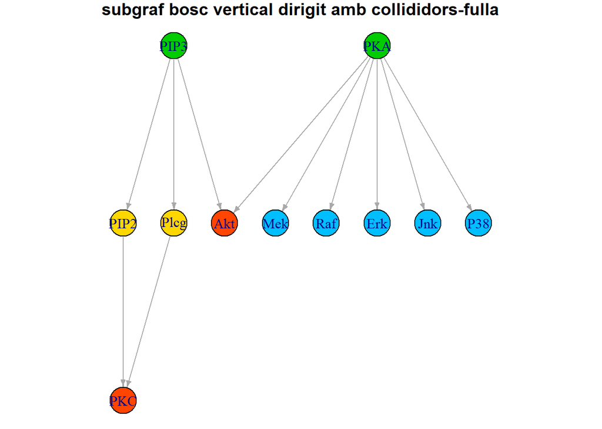

```r
#nodes arrel (sense pares)
arrels <- V(g_bosc_vertical)$name[degree(g_bosc_vertical, mode="in") == 0]
#nodes fulla (sense fills)
fulles <- V(g_bosc_vertical)$name[degree(g_bosc_vertical, mode="out") == 0]
#nodes col·lididors (>= 2 pares)
collididors <- V(g_bosc_vertical)$name[degree(g_bosc_vertical, mode="in") >= 2]

noms_nodes <- V(g_bosc_vertical)$name

V(g_bosc_vertical)$role <- ifelse(!is.na(match(noms_nodes,collididors )), "col·lididor-fulla",
                    ifelse(!is.na(match(noms_nodes, arrels)), "arrel",
                      ifelse(!is.na(match(noms_nodes,fulles )), "fulla", "mitjancer"             )))


V(g_bosc_vertical)$color <- ifelse(V(g_bosc_vertical)$role == "col·lididor-fulla", "orangered",
                              ifelse(V(g_bosc_vertical)$role == "arrel" , "green3",
                                ifelse(V(g_bosc_vertical)$role =="fulla", "deepskyblue", "gold"                                    )))


par(mar=c(0,0,1,0))
plot(g_bosc_vertical,
     layout=layout_as_tree(g_bosc_vertical, root = arrels),
     edge.arrow.size=0.4,
     vertex.size=15,
     main ="subgraf bosc vertical dirigit amb collididors-fulla")
```

Tanmateix, encara que l’Akt és de natura estructural perquè uneix els dos arbres dirigits verticals, cal respectar la definició d’arbre i treballar amb un bosc dirigit non-connex (on cada compenent sigui un arbre); el segon, PKC, no uneix pas els arbres del bosc perquè pertany sols a l’arbre d’arrel PIP3. Sigui com sigui un arbre dirigit no pot contenir col·lididors perquè viola la seva estructura fonamental que és d’un sol pare per node; cal doncs restituir la propietat d’arbre a dins del DAG vertical.

Aquí hom tria eliminar les arestes PKA -> Akt i Plcg -> PKC segons el criteri estadístic d’obtenir el màxim de tests d’independències condicionals coherents amb les dades. Així, en treure aquestes dues arestes, hom desfà els col·lididors-fulla i el model millora en coherència perquè deixen de violar el principi <d’un pare per node> propri d’un arbre. La implicació o dependència causal a un arbre són o bé cadena (A->B->C) o bé A->(B,C), el bosc resultant és una estructura de transmissió unidireccional sense convergència d’arestes a un node (entre qualsevol parell de nodes hi ha exactament un únic camí dirigit).

El subgraf vertical és compost de cadenes de verticals de 2 a 3 nodes

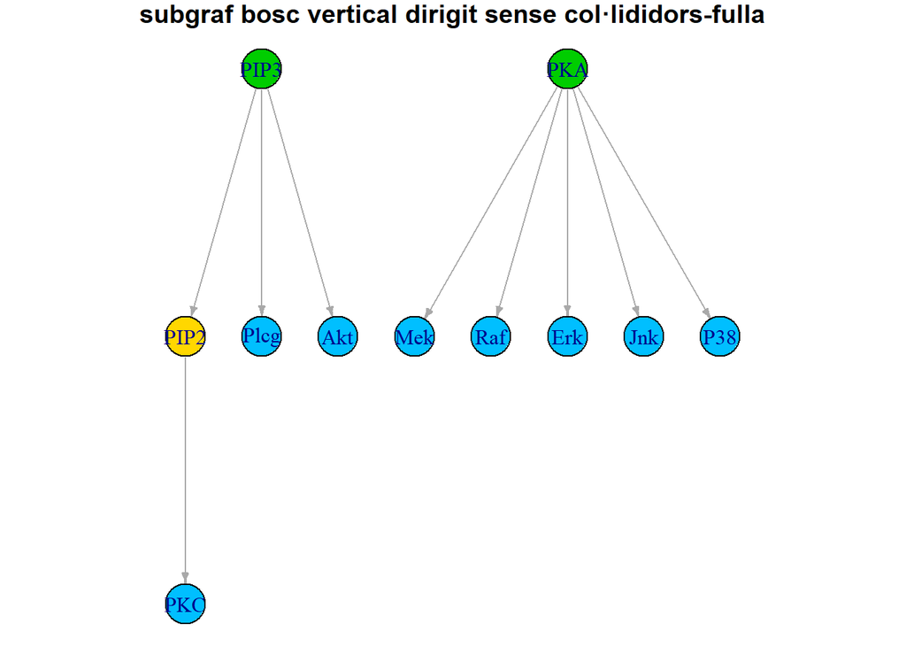

```r
g_bosc_vertical1 <- subgraph_from_edges(g_bosc_vertical, eids = c(1:4,6:10))

arrels1 <- V(g_bosc_vertical1)$name[degree(g_bosc_vertical1, mode="in") == 0]
fulles1 <- V(g_bosc_vertical1)$name[degree(g_bosc_vertical1, mode="out") == 0]
noms_nodes1 <- V(g_bosc_vertical)$name

V(g_bosc_vertical1)$role <- ifelse(!is.na(match(noms_nodes1, arrels1)), "arrel",
                      ifelse(!is.na(match(noms_nodes1,fulles1 )), "fulla", "mitjancer"))


V(g_bosc_vertical1)$color <- ifelse(V(g_bosc_vertical1)$role == "arrel" , "green3",
                                ifelse(V(g_bosc_vertical1)$role =="fulla", "deepskyblue", "gold"                                    ))


par(mar=c(0,0,1,0))
plot(g_bosc_vertical1,
     layout=layout_as_tree(g_bosc_vertical1, , root = arrels),
     edge.arrow.size=0.4,
     vertex.size=15,
     main ="subgraf bosc vertical dirigit sense col·lididors-fulla")
```

# **3. SUBGRAF RETROLATERAL**

El graf retrolateral sortint és non-connex (no tots els parells de vèrtexs són units com a mínim per un camí); és esperable que en sigui, de non-connex, perquè les connexions laterals no cal que mantinguin la continuïtat del flux vertical principal. En canvi, per definició, els arbre d’un bosc han d’esser connexos (el bosc pot esser non-connex tanmateix). El subgraf retrolateral representa relacions locals o complementàries entre blocs de la xarxa

```r
(g_retrolateral <- igraph::subgraph_from_edges(g_bosc, E(g_bosc)[E(g_bosc)$type %in%  c("col·lididor","lateral")], delete.vertices = TRUE))
```

```
## IGRAPH ea8996b DN-- 8 7 --
## + attr: name (v/c), nivell (v/n), type (e/c)
## + edges from ea8996b (vertex names):
## [1] Mek ->Erk  PKC ->Jnk  PKC ->Mek  PKC ->P38  PKC ->Raf  Plcg->PIP2 Raf ->Mek
```

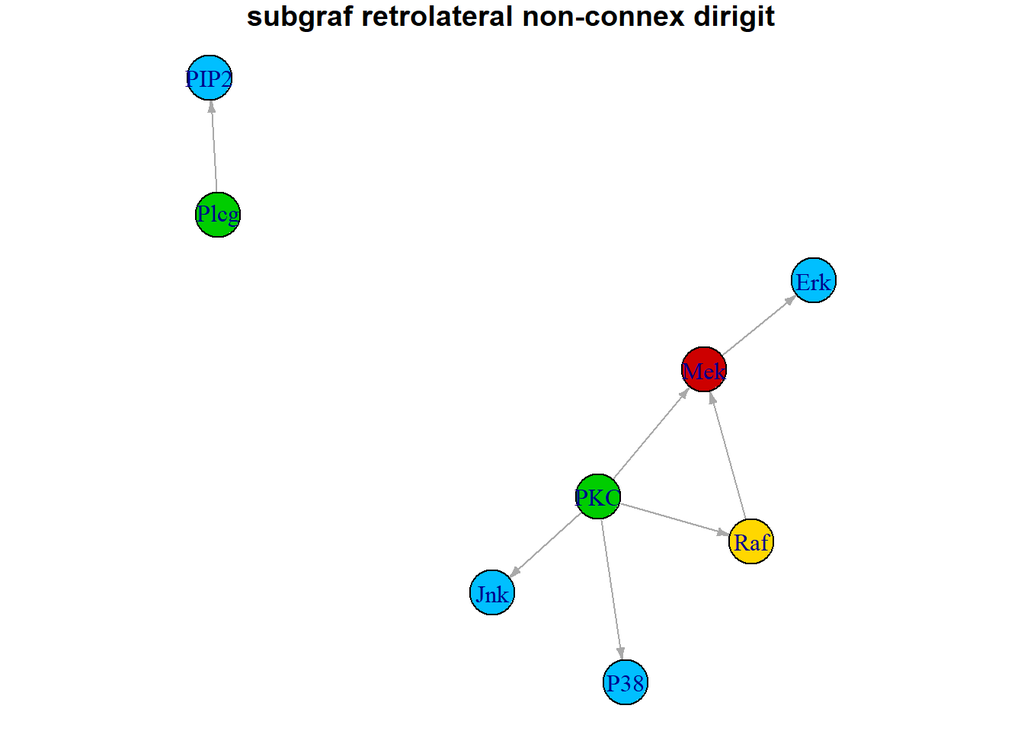

```r
#nodes arrel (sense pares)
arrels <- V(g_retrolateral)$name[degree(g_retrolateral, mode="in") == 0]
#nodes fulla (sense fills)
fulles <- V(g_retrolateral)$name[degree(g_retrolateral, mode="out") == 0]
#nodes col·lididors (>= 2 pares)
collididors <- V(g_retrolateral)$name[degree(g_retrolateral, mode="in") >= 2]

noms_nodes <- V(g_retrolateral)$name

V(g_retrolateral)$role <- ifelse(!is.na(match(noms_nodes,collididors )), "col·lididor",
                    ifelse(!is.na(match(noms_nodes, arrels)), "arrel",
                      ifelse(!is.na(match(noms_nodes,fulles )), "fulla", "mitjancer")))


V(g_retrolateral)$color <- ifelse(V(g_retrolateral)$role == "col·lididor", "red3",
                              ifelse(V(g_retrolateral)$role == "arrel" , "green3",
                                ifelse(V(g_retrolateral)$role =="fulla", "deepskyblue", "gold"                                    )))

set.seed(777)
par(mar=c(0,0,1,0))
plot(g_retrolateral,
     layout=layout_with_gem(g_retrolateral),
     edge.arrow.size=0.4,
     vertex.size=15,
     main ="subgraf retrolateral non-connex dirigit")
```

Però ara cal incloure al lateral les dues arestes sobrants dels col·lididors-fulla trencats al vertical:

```r
#g_retrolateral1 <- g_retrolateral
#g_retrolateral1 <- igraph::add_edges(g_retrolateral1, c("PKA","Akt"))


# Copiem l’original
g_retrolateral1 <- g_retrolateral

# Nodes que falten:
nodes_falten <- c("PKA", "Akt")


# Afegim els nodes (si no hi són)
g_retrolateral1 <- igraph::add_vertices(g_retrolateral1,
                                        nv = length(nodes_falten),
                                        name = nodes_falten)

# Arestes que falten:
arestes_falten <- c("PKA", "Akt", "PIP2", "PKC")

# Afegim les arestes
g_retrolateral1 <- igraph::add_edges(g_retrolateral1, arestes_falten)

g_retrolateral1
```

```
## IGRAPH eac0429 DN-- 10 9 --
## + attr: name (v/c), nivell (v/n), role (v/c), color (v/c), type (e/c)
## + edges from eac0429 (vertex names):
## [1] Mek ->Erk  PKC ->Jnk  PKC ->Mek  PKC ->P38  PKC ->Raf  Plcg->PIP2 Raf ->Mek
## [8] PKA ->Akt  PIP2->PKC
```

Si hom descompon el subgraf retrolateral en patrons causals bàsics irreductibles de teoria de grafs (és a dir, de mínima complexitat topològica: calen tres nodes adjacents en la direcció de les arestes, sols dues arestes i un únic node intermedi; són acíclics i non-redundants, sols hi ha una via entre A i C); si hom fa aquesta descomposició elemental del subgraf retrolateral, tots són composts per arestes lateroverticals o retrolaterals, sempre hi ha com a mínim una aresta lateral (amb tres nodes hom pot construir tots els tipus causals: forques o confonedors, col·lididors, cadenes… encara que segons la definició formal en teoria de grafs una cadena també pugui esser composta d’un o més nodes, però en aquest model hom pren un mínim de 3 nodes).

Amb dos nodes, hon no pot distingir cap d’aquests patrons, amb dos nodes sols hi ha una direcció simple sense context estructural. A més a més, segons el model geomètric, calen 3 nodes adjacents per construir un pla causal (determinat per dos vectors), per calcular un angle (entre fluxos o entre un flux i l’eix de Z de referència) o per definir la normal (que dóna el pla de col·lididor o forca)

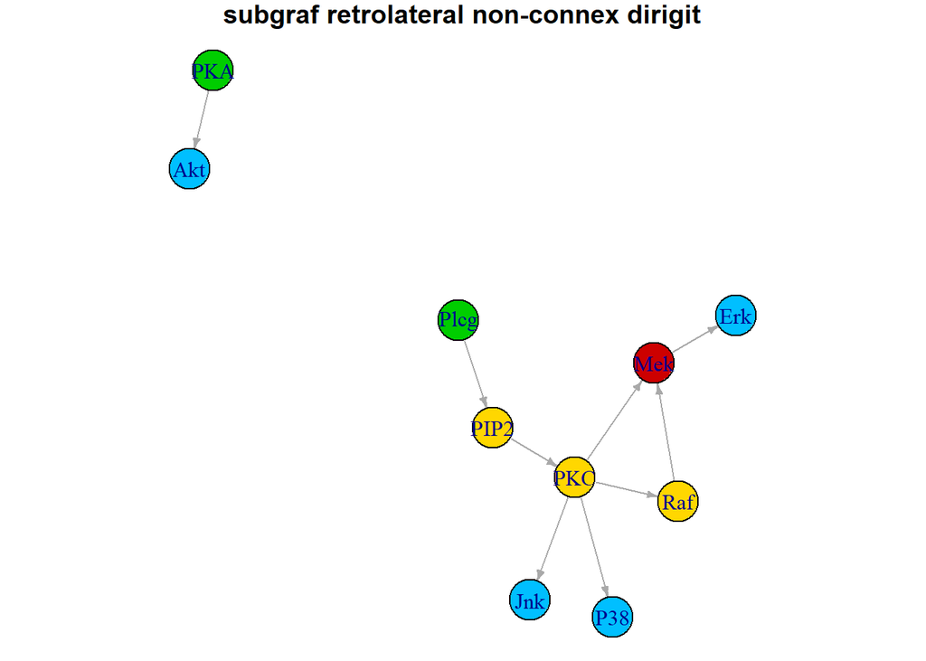

```r
set.seed(777)
par(mar=c(0,0,1,0))

arrels <- V(g_retrolateral1)$name[degree(g_retrolateral1, mode="in") == 0]
#nodes fulla (sense fills)
fulles <- V(g_retrolateral1)$name[degree(g_retrolateral1, mode="out") == 0]
#nodes col·lididors (>= 2 pares)
collididors <- V(g_retrolateral1)$name[degree(g_retrolateral1, mode="in") >= 2]

noms_nodes <- V(g_retrolateral1)$name

V(g_retrolateral1)$role <- ifelse(!is.na(match(noms_nodes,collididors )), "col·lididor",
                    ifelse(!is.na(match(noms_nodes, arrels)), "arrel",
                      ifelse(!is.na(match(noms_nodes,fulles )), "fulla", "mitjancer"             )))


V(g_retrolateral1)$color <- ifelse(V(g_retrolateral1)$role == "col·lididor", "red3",
                              ifelse(V(g_retrolateral1)$role == "arrel" , "green3",
                                ifelse(V(g_retrolateral1)$role =="fulla", "deepskyblue", "gold"                                    )))

plot(g_retrolateral1,
     layout=layout_with_gem(g_retrolateral1),
     edge.arrow.size=0.4,
     vertex.size=15,
     main ="subgraf retrolateral non-connex dirigit")
```

A cop d’ull hom ja veu que el node implicat en més de tipus causals elementals és el node PKC: implicat en una forca múltiple, una cadena i un col·lididor. És el node que més distorsiona el flux causal general i cal tenir molt en compte.

Havent aïllada l’estructura vertical, hom examina el retrolateral, no amb finalitat causal definitiva sinó com a pas exploratori per identificar patrons de confusió, col·lisionadors, redundàncies o dependències laterals que podrien comprometre la inferència, tot fent una anàlisi separada del subgraf vertical, és a dir, la proposta d’entrada és analitzar-ho per dimensions aïllades a fi de construir un mapa de riscos causals abans d’afrontar el model complet. L’anàlisi progressiva de les implicacions de les arestes horitzontals sobre el subgraf vertical, sense perdre de vista quines interaccions aporten informació vertical i quines introdueixen soroll lateral.

```r
detectar_motius_elementals <- function(g) {

  motius <- list()

  # Per cada node B (possible node medial)
  for (b in V(g)) {
    b_name <- V(g)[b]$name

    # Nodes que apunten cap a B (A -> B)
    in_nodes <- names(neighbors(g, b, mode = "in"))

    # Nodes que surten de B (B -> C)
    out_nodes <- names(neighbors(g, b, mode = "out"))



    # (1) CADENA: A -> B -> C
    if (length(in_nodes) == 1 && length(out_nodes) == 1) {
      motius[[length(motius) + 1]] <- list(
        tipus = "Cadena",
        nodes = c(in_nodes, b_name, out_nodes)
      )
    }

    # (2) FORCA: B -> A i B -> C
    if (length(out_nodes) >= 2 && length(in_nodes) == 0) {
      comb <- combn(out_nodes, 2)
      for (i in 1:ncol(comb)) {
        motius[[length(motius) + 1]] <- list(
          tipus = "Forca",
          nodes = c(comb[, i][1], b_name, comb[, i][2])
        )
      }
    }

    # (3) COL·LISIONADOR: A -> B <- C
    if (length(in_nodes) >= 2 && length(out_nodes) == 0) {
      comb <- combn(in_nodes, 2)
      for (i in 1:ncol(comb)) {
        motius[[length(motius) + 1]] <- list(
          tipus = "Col·lisionador",
          nodes = c(comb[, i][1], b_name, comb[, i][2])
        )
      }
    }
  }


  motius_df <- do.call(rbind, lapply(motius, as.data.frame))
  return(motius_df)
}


motius_lateral <- detectar_motius_elementals(g_retrolateral1)
print(motius_lateral)
```

```
##    tipus nodes
## 1 Cadena  Plcg
## 2 Cadena  PIP2
## 3 Cadena   PKC
## 4 Cadena   PKC
## 5 Cadena   Raf
## 6 Cadena   Mek
```

```r
components(g_retrolateral)
```

```
## $membership
##  Mek PIP2  PKC Plcg  Raf  Erk  Jnk  P38
##    1    2    1    2    1    1    1    1
##
## $csize
## [1] 6 2
##
## $no
## [1] 2
```

```r
components(g_retrolateral1)
```

```
## $membership
##  Mek PIP2  PKC Plcg  Raf  Erk  Jnk  P38  PKA  Akt
##    1    1    1    1    1    1    1    1    2    2
##
## $csize
## [1] 8 2
##
## $no
## [1] 2
```

Abans de continuar, cal comprovar que com a mínim el graf lateral sobretot al final comparteix com a mínim una arrel o node d’enllaç causal amb el vertical a fi de garantir la compatibilitat topològica i causal amb el model global. Si hom fa la comprovació a aquest estadi, la llista no és buida, hi ha un node arrel compartit i el lateral, per tant, no roman aïllat i pot esser entès com una extensió causal del pathway i no pas com una via independenta. Ara per ara, hi han dos subsistemes, vertical i retrolateral, que — a més de compartir nodes interns, un node arrel del retrolateral és a dins del vertical també—, amb la qual cosa són connectats causalment. El mínim de nodes del retrolateral que hom pot trobar-hi és l’aplec de fulles del subgraf vertical.

```r
nodes_comuns <- intersect(V(g_bosc_vertical1)$name, V(g_retrolateral1)$name)
arrels_comunes <- intersect(nodes_comuns, setdiff(V(g_bosc_vertical1)$name, ends(g_bosc_vertical1, es=E(g_bosc_vertical1))[,2]))
arrels_comunes
```

```
## [1] "PKA"
```

Però, a més a més, també hi han camins actius, cosa que causa que els subgrafs encara siguin més dependents.

```r
arestes_df <- as.data.frame(dagitty::edges(pathway_net))
igraph_pathway_net <- graph_from_data_frame(arestes_df, directed = TRUE)

nodes_ver <- V(g_bosc_vertical1)$name
nodes_lat <- V(g_retrolateral1)$name

distant_gen <- distances(igraph_pathway_net, mode="out")
distant_sub <- distant_gen[nodes_ver, nodes_lat, drop=FALSE]
connexions_df <- as.data.frame(as.table(distant_sub))
connexions_df <- connexions_df[is.finite(connexions_df$Freq),]
colnames(connexions_df) <- c("origen", "destinacio", "llargaria_cami")
(connexions_df <- connexions_df[order(connexions_df$llargaria_cami),])
```

|  | origen | destinacio | llargaria_cami |
| --- | --- | --- | --- |
| 1 | Mek | Mek | 0 |
| 13 | PIP2 | PIP2 | 0 |
| 27 | PKC | PKC | 0 |
| 39 | Plcg | Plcg | 0 |
| 51 | Raf | Raf | 0 |
| 63 | Erk | Erk | 0 |
| 76 | Jnk | Jnk | 0 |
| 88 | P38 | P38 | 0 |
| 92 | PKA | PKA | 0 |
| 108 | Akt | Akt | 0 |

[output cut: 36 more lines]

# **4. ANÀLISI DELS SUBGRAFS VERTICAL I RETROLATERAL**

## **Introducció**

Havent descompost amb èxit el pathway en els dos subgrafs, vertical i retrolateral, abans de començar el procés de conversió geomètrica, primer topològica i després empírica amb la normalització espacial, a fi d’obtenir un model geomètric 3D amb un espai mètric coherent, on els angles representen orientacions causals i els mòduls representen intensitats de flux comparables.  
cal una anàlisi prèvia no sols amb cada subgraf sinó també amb el pathway_net com a DAG general per tal de comprovar empirícament la coherència de cadascun segons les dades.

Per tant, hom podria analitzar empíricament tots dos subgrafs en termes de coherència, tant del vertical a causa del flux causal vertical del qual es deriva i també el de retroflux inclòs en el subgraf retrolateral (hom es val d’un usatge sistemàtic dels tests d’independència condicional amb la funció localTest(), la qual assereix a la hipòtesi bàsica H_0: X és independenta de Y condicionat en Z, si la p-vàlua és molt petita H_0 pot esser rebutjada, és a dir, hi ha prou evidència empírica per dir que hi ha dependència estadística).

Una aplicació d’aquesta anàlsisi és, per exemple, decidir quina aresta mantenir en el vertical i quina derivar al subgraf retrolateral quan cal descompondre els col·lididors fulla a fi d’obtenir el subgraf vertical.

## *4.1 Vertical amb col·lididiors-fulla*

Si hom assagés totes les independències condicionals implícites del model amb els col·lididors-fulla —contravenint la definció d’arbre— amb el conjunt de dades: en total surten 45 independències condicionals (la funció localTest() construeix -segons el model vertical- la grandària del basis set de d-separació; és a dir: un DAG amb p variables/nodes, el basis set conté un test per a cada parella de variables que no són connectades per una aresta, més en concret, per cada parella non-adjacent; i m és el nombre d’arestes que ja hi ha al subgraf, ja són connectades directament per una aresta i, per tant, per definició no són independentes i no cal comprovar-les amb un test d’independència)

Hi han 44 parelles però la funció localTests() en dóna 45 , per tant, hi ha una parella duplicada: “Akt__PKC” (vegeu dessota***)

```r
dag_ver_AC <- dagitty('dag {
PIP2->PKC
PIP3->Akt
PIP3->PIP2
PIP3->Plcg
PKA ->Akt
PKA ->Erk
PKA ->Jnk
PKA ->Mek
PKA ->P38
PKA ->Raf
Plcg->PKC
}')

node_status(dag_ver_AC)
```

```
## # A DAG with 11 nodes and 11 edges
## #
## # A tibble: 18 × 9
##    name         x      y direction to        xend   yend circular status
##    <chr>    <dbl>  <dbl> <fct>     <chr>    <dbl>  <dbl> <lgl>    <fct>
##  1 Akt   -0.0512   0.171 <NA>      <NA>  NA       NA     FALSE    <NA>
##  2 Erk    1.61    -3.06  <NA>      <NA>  NA       NA     FALSE    <NA>
##  3 Jnk   -0.737   -3.38  <NA>      <NA>  NA       NA     FALSE    <NA>
##  4 Mek   -1.18    -2.10  <NA>      <NA>  NA       NA     FALSE    <NA>
##  5 P38    0.508   -3.75  <NA>      <NA>  NA       NA     FALSE    <NA>
##  6 PIP2  -1.11     3.73  ->        PKC   -0.700    4.90  FALSE    <NA>
##  7 PIP3  -0.357    2.33  ->        Akt   -0.0512   0.171 FALSE    <NA>
##  8 PIP3  -0.357    2.33  ->        PIP2  -1.11     3.73  FALSE    <NA>
##  9 PIP3  -0.357    2.33  ->        Plcg  -0.00325  3.87  FALSE    <NA>
## 10 PKA    0.284   -2.12  ->        Akt   -0.0512   0.171 FALSE    <NA>
## 11 PKA    0.284   -2.12  ->        Erk    1.61    -3.06  FALSE    <NA>
## 12 PKA    0.284   -2.12  ->        Jnk   -0.737   -3.38  FALSE    <NA>
## 13 PKA    0.284   -2.12  ->        Mek   -1.18    -2.10  FALSE    <NA>
## 14 PKA    0.284   -2.12  ->        P38    0.508   -3.75  FALSE    <NA>
## 15 PKA    0.284   -2.12  ->        Raf    1.70    -1.70  FALSE    <NA>
## 16 PKC   -0.700    4.90  <NA>      <NA>  NA       NA     FALSE    <NA>
## 17 Plcg  -0.00325  3.87  ->        PKC   -0.700    4.90  FALSE    <NA>
## 18 Raf    1.70    -1.70  <NA>      <NA>  NA       NA     FALSE    <NA>
```

***aquí hom pot veure la parella duplicada (Akt *||* PKC) abans esmentada

Segons el model gràfic, aquestes independències condicionals haurien d’esser validades empíricament amb les dades; aquestes són les relacions esperables segons el model topològic.

```r
impliedConditionalIndependencies(dag_ver_AC)
```

```
## Akt _||_ Erk | PKA
## Akt _||_ Jnk | PKA
## Akt _||_ Mek | PKA
## Akt _||_ P38 | PKA
## Akt _||_ PIP2 | PIP3
## Akt _||_ PKC | PIP2, Plcg
## Akt _||_ PKC | PIP3
## Akt _||_ Plcg | PIP3
## Akt _||_ Raf | PKA
## Erk _||_ Jnk | PKA
## Erk _||_ Mek | PKA
## Erk _||_ P38 | PKA
## Erk _||_ PIP2
## Erk _||_ PIP3
## Erk _||_ PKC
## Erk _||_ Plcg
## Erk _||_ Raf | PKA
## Jnk _||_ Mek | PKA
## Jnk _||_ P38 | PKA
## Jnk _||_ PIP2
## Jnk _||_ PIP3
## Jnk _||_ PKC
## Jnk _||_ Plcg
## Jnk _||_ Raf | PKA
## Mek _||_ P38 | PKA
## Mek _||_ PIP2
## Mek _||_ PIP3
## Mek _||_ PKC
## Mek _||_ Plcg
## Mek _||_ Raf | PKA
## P38 _||_ PIP2
## P38 _||_ PIP3
## P38 _||_ PKC
## P38 _||_ Plcg
## P38 _||_ Raf | PKA
## PIP2 _||_ PKA
## PIP2 _||_ Plcg | PIP3
## PIP2 _||_ Raf
## PIP3 _||_ PKA
## PIP3 _||_ PKC | PIP2, Plcg
## PIP3 _||_ Raf
## PKA _||_ PKC
## PKA _||_ Plcg
## PKC _||_ Raf
## Plcg _||_ Raf
```

Ara hom veu quines independències condicionades es compleixen i quines no. El primer test de tots rebutja amb molta d’evidència empírica que hi hagi independència entre Akt i Erk, fins i tot quan hom condiciona per PKA.

```r
(ind_con_AC <- localTests(x = dag_ver_AC, data = dades, type = "cis"))
```

|  | estimate | p.value | 2.5% | 97.5% |
| --- | --- | --- | --- | --- |
| Akt _\|\|_ Erk \| PKA | 0.897496773 | 0.000000e+00 | 0.964151270 | 0.975748774 |
| Akt _\|\|_ Jnk \| PKA | -0.063864202 | 4.918173e-12 | -0.081912252 | -0.045774540 |
| Akt _\|\|_ Mek \| PKA | 0.062165709 | 1.771451e-11 | 0.044072715 | 0.080218169 |
| Akt _\|\|_ P38 \| PKA | 0.164431813 | 7.605615e-72 | 0.146731388 | 0.182044958 |
| Akt _\|\|_ PIP2 \| PIP3 | -0.013637436 | 1.407006e-01 | -0.031772289 | 0.004506392 |
| Akt _\|\|_ PKC \| PIP2, Plcg | -0.003427899 | 7.111872e-01 | -0.021570048 | 0.014716506 |
| Akt _\|\|_ PKC \| PIP3 | -0.003981517 | 6.671376e-01 | -0.022122632 | 0.014162219 |
| Akt _\|\|_ Plcg \| PIP3 | -0.063859201 | 4.937006e-12 | -0.081907264 | -0.045769530 |
| Akt _\|\|_ Raf \| PKA | -0.023945372 | 9.680488e-03 | -0.042069817 | -0.005805182 |
| Erk _\|\|_ Jnk \| PKA | -0.021982334 | 1.755458e-02 | -0.040109057 | -0.003841153 |

[output cut: 35 more lines]

```r
(Basis_set_verAC <- length(impliedConditionalIndependencies(dag_ver_AC)))
```

```
## [1] 45
```

```r
Basis_set <- impliedConditionalIndependencies(dag_ver_AC)
Basis_set[6:7]
```

```
## Akt _||_ PKC | PIP2, Plcg
## Akt _||_ PKC | PIP3
```

```r
parelles <- sapply(Basis_set, function(x) {
  variables <- unlist(x[c("X","Y")])
  paste(sort(variables), collapse = "__")
})

(duplicats <- names(table(parelles)[table(parelles)>1]))
```

```
## [1] "Akt__PKC"
```

Hom representa gràficament els resultats dels tests d’independència condicional

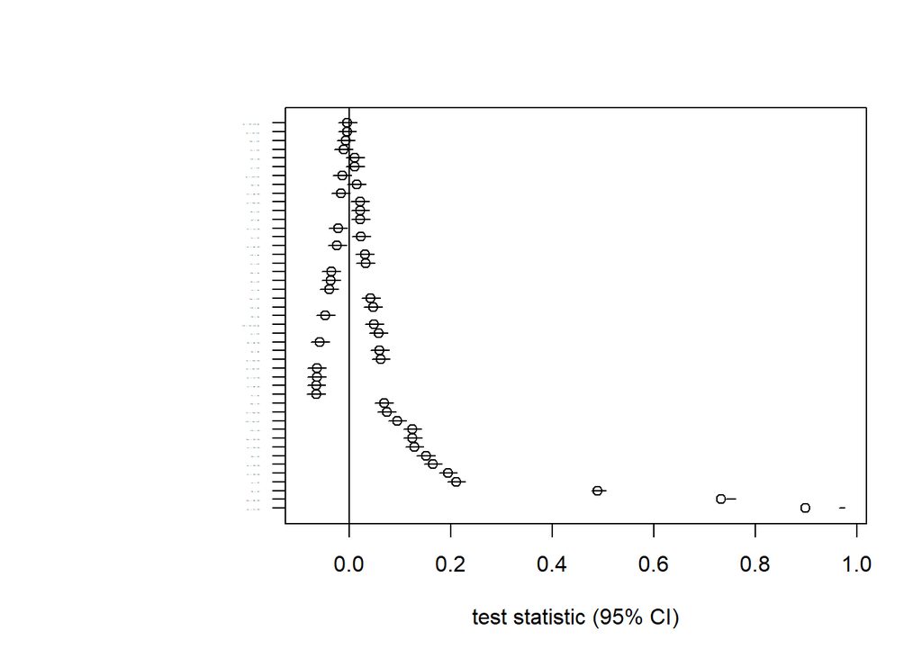

```r
ind_con_AC1 <- ind_con_AC[order(abs(ind_con_AC$estimate)),]
plotLocalTestResults(ind_con_AC1, axis.pars = list(cex.axis=0.05, las=1))
```

Aquesta pot esser una manera de quantificar quants de tests coherents hom obté si hom manté el col·lididor-fulla: 9 de coherents versus 36 de fallits

```r
ver_coherent_AC <- ifelse(ind_con_AC$p.value<0.05, "violat" , "coherent")
table(ver_coherent_AC)
```

```
## ver_coherent_AC
## coherent   violat
##        9       36
```

```r
violacions <- subset(ind_con_AC, ver_coherent_AC == "violat")
(violacions <- violacions[order(violacions$p.value),])
```

|  | estimate | p.value | 2.5% | 97.5% |
| --- | --- | --- | --- | --- |
| Akt _\|\|_ Erk \| PKA | 0.89749677 | 0.000000e+00 | 0.964151270 | 0.975748774 |
| Mek _\|\|_ Raf \| PKA | 0.73212830 | 0.000000e+00 | 0.741124841 | 0.760521062 |
| P38 _\|\|_ PKC | 0.48849453 | 0.000000e+00 | 0.476315918 | 0.504549890 |
| Jnk _\|\|_ PKC | 0.21099830 | 1.821313e-118 | 0.193615808 | 0.228308526 |
| Erk _\|\|_ P38 \| PKA | 0.19474612 | 9.498845e-101 | 0.177241385 | 0.212168393 |
| Akt _\|\|_ P38 \| PKA | 0.16443181 | 7.605615e-72 | 0.146731388 | 0.182044958 |
| PKA _\|\|_ PKC | 0.15063947 | 1.997989e-60 | 0.132863400 | 0.168330492 |
| Jnk _\|\|_ P38 \| PKA | 0.12846961 | 2.965852e-44 | 0.110585753 | 0.146275891 |
| Mek _\|\|_ P38 \| PKA | 0.12487724 | 6.929118e-42 | 0.106977836 | 0.142700632 |
| PIP3 _\|\|_ PKA | 0.12429927 | 1.628804e-41 | 0.106398171 | 0.142124606 |

[output cut: 26 more lines]

## *4.2 Vertical sense col·lididiors-fulla*

```r
g_bosc_vertical1 <- subgraph_from_edges(g_bosc_vertical, eids = c(2:4,6:11))
df_arestes1 <- igraph::as_data_frame(g_bosc_vertical1, what = "edges")
dag_g_bosc_arestes <- paste0("dag{ ", paste(paste(df_arestes1$from, "->", df_arestes1$to),collapse=";"),"}")
# hom converteix un objecte ipgraph a un de dagitty
g_bosc_vertical2 <- dagitty(dag_g_bosc_arestes)
node_status(g_bosc_vertical2)
```

```
## # A DAG with 11 nodes and 9 edges
## #
## # A tibble: 17 × 9
##    name       x      y direction to      xend   yend circular status
##    <chr>  <dbl>  <dbl> <fct>     <chr>  <dbl>  <dbl> <lgl>    <fct>
##  1 Akt    1.81   0.948 <NA>      <NA>  NA     NA     FALSE    <NA>
##  2 Erk   -1.50   3.25  <NA>      <NA>  NA     NA     FALSE    <NA>
##  3 Jnk   -1.16   2.20  <NA>      <NA>  NA     NA     FALSE    <NA>
##  4 Mek   -0.316  4.14  <NA>      <NA>  NA     NA     FALSE    <NA>
##  5 P38    0.794  2.52  <NA>      <NA>  NA     NA     FALSE    <NA>
##  6 PIP2   1.26  -0.395 <NA>      <NA>  NA     NA     FALSE    <NA>
##  7 PIP3   0.750  0.368 ->        Akt    1.81   0.948 FALSE    <NA>
##  8 PIP3   0.750  0.368 ->        PIP2   1.26  -0.395 FALSE    <NA>
##  9 PIP3   0.750  0.368 ->        Plcg  -0.479  0.111 FALSE    <NA>
## 10 PKA   -0.254  3.09  ->        Erk   -1.50   3.25  FALSE    <NA>
## 11 PKA   -0.254  3.09  ->        Jnk   -1.16   2.20  FALSE    <NA>
## 12 PKA   -0.254  3.09  ->        Mek   -0.316  4.14  FALSE    <NA>
## 13 PKA   -0.254  3.09  ->        P38    0.794  2.52  FALSE    <NA>
## 14 PKA   -0.254  3.09  ->        Raf    0.951  3.60  FALSE    <NA>
## 15 PKC   -1.55   0.155 <NA>      <NA>  NA     NA     FALSE    <NA>
## 16 Plcg  -0.479  0.111 ->        PKC   -1.55   0.155 FALSE    <NA>
## 17 Raf    0.951  3.60  <NA>      <NA>  NA     NA     FALSE    <NA>
```

```r
(ver_ind_con <- localTests(x = g_bosc_vertical2, data = dades, type = "cis"))
```

|  | estimate | p.value | 2.5% | 97.5% |
| --- | --- | --- | --- | --- |
| Akt _\|\|_ Erk | 0.902993735 | 0.000000e+00 | 0.973452628 | 0.9847412245 |
| Akt _\|\|_ Jnk | -0.042084073 | 5.396793e-06 | -0.060180114 | -0.0239604312 |
| Akt _\|\|_ Mek | 0.071429756 | 1.081988e-14 | 0.053356993 | 0.0894561508 |
| Akt _\|\|_ P38 | 0.146384025 | 4.097659e-57 | 0.128585924 | 0.1640981919 |
| Akt _\|\|_ PIP2 \| PIP3 | -0.013637436 | 1.407006e-01 | -0.031772289 | 0.0045063921 |
| Akt _\|\|_ PKA | 0.226368066 | 1.108752e-136 | 0.209111836 | 0.2435682463 |
| Akt _\|\|_ PKC \| Plcg | -0.003372355 | 7.156503e-01 | -0.021513751 | 0.0147712617 |
| Akt _\|\|_ PKC \| PIP3 | -0.003981517 | 6.671376e-01 | -0.022122632 | 0.0141622189 |
| Akt _\|\|_ Plcg \| PIP3 | -0.063859201 | 4.937006e-12 | -0.081907264 | -0.0457695295 |
| Akt _\|\|_ Raf | -0.004301928 | 6.421386e-01 | -0.022442113 | 0.0138410872 |

[output cut: 38 more lines]

Lleu millora sense els col·lididors-fulla

```r
ver_coherent <- ifelse(ver_ind_con$p.value<0.05, "violat" , "coherent")
table(ver_coherent)
```

[output not shown]

```r
9/(9+36)
```

```
## [1] 0.2
```

```r
12/(12+36)
```

```
## [1] 0.25
```

```r
prop.test(x = c(12, 9), n = c(48, 45), correct = FALSE)
```

```
##
##  2-sample test for equality of proportions without continuity correction
##
## data:  c(12, 9) out of c(48, 45)
## X-squared = 0.33214, df = 1, p-value = 0.5644
## alternative hypothesis: two.sided
## 95 percent confidence interval:
##  -0.1193051  0.2193051
## sample estimates:
## prop 1 prop 2
##   0.25   0.20
```

## *4.3 Retrolateral*

```r
dag_retrolat1 <- dagitty('dag {
Mek ->Erk
PKC ->Jnk
PKC ->Mek
PKC ->P38
PKC ->Raf
Plcg->PIP2
Raf ->Mek

Plcg->PKC
PKA ->Akt
}')

node_status(dag_retrolat1)
```

```
## # A DAG with 10 nodes and 9 edges
## #
## # A tibble: 14 × 9
##    name       x      y direction to      xend   yend circular status
##    <chr>  <dbl>  <dbl> <fct>     <chr>  <dbl>  <dbl> <lgl>    <fct>
##  1 Akt    2.12  -1.43  <NA>      <NA>  NA     NA     FALSE    <NA>
##  2 Erk    2.77   1.21  <NA>      <NA>  NA     NA     FALSE    <NA>
##  3 Jnk   -0.755  1.65  <NA>      <NA>  NA     NA     FALSE    <NA>
##  4 Mek    1.68   1.19  ->        Erk    2.77   1.21  FALSE    <NA>
##  5 P38    0.545  2.35  <NA>      <NA>  NA     NA     FALSE    <NA>
##  6 PIP2  -1.05  -0.772 <NA>      <NA>  NA     NA     FALSE    <NA>
##  7 PKA    1.26  -1.80  ->        Akt    2.12  -1.43  FALSE    <NA>
##  8 PKC    0.339  1.18  ->        Jnk   -0.755  1.65  FALSE    <NA>
##  9 PKC    0.339  1.18  ->        Mek    1.68   1.19  FALSE    <NA>
## 10 PKC    0.339  1.18  ->        P38    0.545  2.35  FALSE    <NA>
## 11 PKC    0.339  1.18  ->        Raf    1.14   0.451 FALSE    <NA>
## 12 Plcg  -0.559  0.145 ->        PIP2  -1.05  -0.772 FALSE    <NA>
## 13 Plcg  -0.559  0.145 ->        PKC    0.339  1.18  FALSE    <NA>
## 14 Raf    1.14   0.451 ->        Mek    1.68   1.19  FALSE    <NA>
```

```r
(retrolat_ind_con <- localTests(x = dag_retrolat1, data = dades, type = "cis"))
```

|  | estimate | p.value | 2.5% | 97.5% |
| --- | --- | --- | --- | --- |
| Akt _\|\|_ Erk | 0.9029937349 | 0.000000e+00 | 0.9734526285 | 0.984741225 |
| Akt _\|\|_ Jnk | -0.0420840727 | 5.396793e-06 | -0.0601801142 | -0.023960431 |
| Akt _\|\|_ Mek | 0.0714297558 | 1.081988e-14 | 0.0533569931 | 0.089456151 |
| Akt _\|\|_ P38 | 0.1463840249 | 4.097659e-57 | 0.1285859240 | 0.164098192 |
| Akt _\|\|_ PIP2 | -0.0137591544 | 1.371731e-01 | -0.0318931310 | 0.004383875 |
| Akt _\|\|_ PKC | -0.0040760213 | 6.597147e-01 | -0.0222163143 | 0.014066954 |
| Akt _\|\|_ Plcg | -0.0635519722 | 6.227368e-12 | -0.0816000685 | -0.045462466 |
| Akt _\|\|_ Raf | -0.0043019285 | 6.421386e-01 | -0.0224421128 | 0.013841087 |
| Erk _\|\|_ Jnk \| PKC | -0.0033273994 | 7.192794e-01 | -0.0214688164 | 0.014816208 |
| Erk _\|\|_ Jnk \| Mek | -0.0004526791 | 9.610008e-01 | -0.0185952392 | 0.017690179 |

[output cut: 35 more lines]

```r
res_retrolat_coherent05 <- ifelse(retrolat_ind_con$p.value<0.05, "violat" , "coherent")
table(res_retrolat_coherent05)
```

```
## res_retrolat_coherent05
## coherent   violat
##       15       30
```

## *4.4 Retro*

```r
dag_retro <- dagitty('dag {

PKC ->Jnk
PKC ->Mek
PKC ->P38
PKC ->Raf
}')

node_status(dag_retro)
```

```
## # A DAG with 5 nodes and 4 edges
## #
## # A tibble: 8 × 9
##   name       x      y direction to      xend   yend circular status
##   <chr>  <dbl>  <dbl> <fct>     <chr>  <dbl>  <dbl> <lgl>    <fct>
## 1 Jnk    2.42   0.595 <NA>      <NA>  NA     NA     FALSE    <NA>
## 2 Mek   -0.234  1.17  <NA>      <NA>  NA     NA     FALSE    <NA>
## 3 P38    1.38   2.21  <NA>      <NA>  NA     NA     FALSE    <NA>
## 4 PKC    1.09   0.884 ->        Jnk    2.42   0.595 FALSE    <NA>
## 5 PKC    1.09   0.884 ->        Mek   -0.234  1.17  FALSE    <NA>
## 6 PKC    1.09   0.884 ->        P38    1.38   2.21  FALSE    <NA>
## 7 PKC    1.09   0.884 ->        Raf    0.802 -0.439 FALSE    <NA>
## 8 Raf    0.802 -0.439 <NA>      <NA>  NA     NA     FALSE    <NA>
```

L’únic parell que manté la independència condicional (coherent amb la separació d’un DAG) és Jnk *||* Mek | PKC (p = 0.237).

```r
(retro_ind_con <- localTests(x = dag_retro, data = dades, type = "cis"))
```

|  | estimate | p.value | 2.5% | 97.5% |
| --- | --- | --- | --- | --- |
| Jnk _\|\|_ Mek \| PKC | 0.01094103 | 2.372530e-01 | -0.007203114 | 0.02907797 |
| Jnk _\|\|_ P38 \| PKC | 0.02279007 | 1.380969e-02 | 0.004649280 | 0.04091587 |
| Jnk _\|\|_ Raf \| PKC | -0.06292916 | 9.999543e-12 | -0.080979653 | -0.04483765 |
| Mek _\|\|_ P38 \| PKC | 0.10116704 | 5.603586e-28 | 0.083177264 | 0.11909278 |
| Mek _\|\|_ Raf \| PKC | 0.73316215 | 0.000000e+00 | 0.742338082 | 0.76169116 |
| P38 _\|\|_ Raf \| PKC | -0.08373994 | 1.226794e-19 | -0.101728831 | -0.06569712 |

És la ràtio més baixa de totes, 1/6, cosa que té lògica perquè és just el contraflux a la causalitat, la informació de les dades va just en sentit contrari.

```r
res_retro_coherent05 <- ifelse(retro_ind_con$p.value<0.05, "violat" , "coherent")
table(res_retro_coherent05)
```

```
## res_retro_coherent05
## coherent   violat
##        1        5
```

## *4.5 General*

```r
(pathway_ind_con <- localTests(x = pathway_net, data = dades, type = "cis"))
```

|  | estimate | p.value | 2.5% | 97.5% |
| --- | --- | --- | --- | --- |
| Akt _\|\|_ Erk \| Mek, PKA | 0.8970851604 | 0.000000e+00 | 0.963463790 | 0.9750846669 |
| Akt _\|\|_ Erk \| PKA, PKC | 0.8976677512 | 0.000000e+00 | 0.964436850 | 0.9760253392 |
| Akt _\|\|_ Erk \| PIP2, PKA, Plcg | 0.8969931314 | 0.000000e+00 | 0.963310055 | 0.9749365408 |
| Akt _\|\|_ Erk \| PIP3, PKA | 0.8979297031 | 0.000000e+00 | 0.964875186 | 0.9764490934 |
| Akt _\|\|_ Jnk \| PKA, PKC | -0.0571097695 | 6.600962e-10 | -0.075175525 | -0.0390067031 |
| Akt _\|\|_ Jnk \| PIP2, PKA, Plcg | -0.0667608395 | 5.140573e-13 | -0.084802677 | -0.0486755522 |
| Akt _\|\|_ Jnk \| PIP3, PKA | -0.0624895340 | 1.393854e-11 | -0.080541934 | -0.0443963911 |
| Akt _\|\|_ Mek \| PKA, PKC | 0.0648078273 | 2.383684e-12 | 0.046719287 | 0.0828541553 |
| Akt _\|\|_ Mek \| PIP2, PKA, Plcg | 0.0603038930 | 6.970457e-11 | 0.042205815 | 0.0783626161 |
| Akt _\|\|_ Mek \| PIP3, PKA | 0.0617998837 | 2.328828e-11 | 0.043705410 | 0.0798540533 |

[output cut: 49 more lines]

```r
general_coherent05 <- ifelse(pathway_ind_con$p.value<0.05, "violat" , "coherent")
table(general_coherent05)
```

```
## general_coherent05
## coherent   violat
##       14       45
```

## *TEST DE PROPORCIONS*

```r
prop.test(c(15,14), c(45,59))
```

```
##
##  2-sample test for equality of proportions with continuity correction
##
## data:  c(15, 14) out of c(45, 59)
## X-squared = 0.74217, df = 1, p-value = 0.389
## alternative hypothesis: two.sided
## 95 percent confidence interval:
##  -0.09890822  0.29099861
## sample estimates:
##    prop 1    prop 2
## 0.3333333 0.2372881
```

El resultat d’aquest test (més robust per a mostres petites) és coherent amb el previ en el fet que no hi ha evidència estadística de diferència entre proprocions. L’IC de l’odds ratio inclou l’1 però no és el centre geomètric sinó 1.61, el fet és que hi ha molta de variabilitat, d’aquí un IC molt ample. El resultat mostra una tendència real: una relació positiva consistent segons el DAG, però l’amplada de l’IC no permet asserir aquesta direcció positiva amb confiança estadística.

```r
fisher.test(matrix(c(15,45-15,14,59-14), nrow=2))
```

```
##
##  Fisher's Exact Test for Count Data
##
## data:  matrix(c(15, 45 - 15, 14, 59 - 14), nrow = 2)
## p-value = 0.3776
## alternative hypothesis: true odds ratio is not equal to 1
## 95 percent confidence interval:
##  0.6195392 4.1663860
## sample estimates:
## odds ratio
##   1.599644
```

# **5. MODEL CAUSAL GEOMÈTRIC 3D**

##**Grau d’entrada o in (dependència), grau de sortida o out (efecte) i nivell (jerarquia de flux causal)**

La descomposició causal vertical/retrolateral pot anar una mica més enllà de la teoria de grafs clàssica a fi d’entrar a dins de l’àmbit de la morfologia estructural causal tridimensional. Va més enllà perquè integra dues jerarquies (vertical i retrolateral), és acíclic però no sols jeràrquic (permet relacions horitzontals dins d’un mateix nivell causal), preserva la disjunció d’arestes per no pas de nodes (el mateix node pot participar en dos plans causals).

Hom passa d’un plantejament d’*unió purament topològica* (no introdueix noves dimensions, sols reparteix la causalitat entre nivells o verticalitat, graus_in o arestes entrants i graus_out o arestes sortints) a un de topoempíric.

L’aparició de *l’espai causal 3D*, el producte vectorial de totes tres dimensions perquè cada node pot existir en totes tres dimensions alhora (no és solsment la unió de Vertical i Retrolateral), aquí hom defineix un vector per a cada node a fi d’emplaçar-los a dins d’un espai tridimensional, ara ja no és la unió de subgrafs sinó un espai mètric on la distància entre nodes té un significat i les magnituds poden esser contínues i escalaritzables.

Hom pot recórrer des del model més senzill com és una cadena tot passant per un DAG que sols té estructura d’arbre, fins a arribar a un DAG amb nivells i relacions retrolaterals.

## *5.1 SUBGRAF VERTICAL TOPOLÒGIC*

### *5.1.1 Model d’arbre sense els eixos normalitzats*

```r
deg_in <- degree(g_bosc_vertical1, mode = "in")
deg_out <- degree(g_bosc_vertical1, mode = "out")

coords <- cbind(
 X = deg_out, # eix de sortida
 Y = deg_in,# eix d’entrada
 Z = V(g_bosc_vertical1)$nivell  # eix de profunditat vertical
)
coords
```

```
##      X Y Z
## Mek  0 1 1
## PIP2 0 1 1
## PIP3 3 0 0
## PKA  5 0 0
## PKC  0 1 2
## Plcg 1 1 1
## Raf  0 1 1
## Erk  0 1 1
## Akt  0 1 1
## Jnk  0 1 1
## P38  0 1 1
```

Els rangs són força desiguals (els eixos requereixen un escalatge)

```r
apply(coords,2,range)
```

```
##      X Y Z
## [1,] 0 0 0
## [2,] 5 1 2
```

Eixos sense escalatge

```r
library(rgl)

deg_in  <- degree(g_bosc_vertical1, mode = "in")
deg_out <- degree(g_bosc_vertical1, mode = "out")

coords <- cbind(
 X = deg_out, # eix de sortida
 Y = deg_in,# eix d’entrada
 Z = V(g_bosc_vertical1)$nivell  # eix de profunditat vertical
)

open3d()
```

```
## wgl
##   1
```

```r
plot3d(coords, col = "red3", size = 1, type = "s")

# afegeix arestes
edges <- as_edgelist(g_bosc_vertical1)
for (i in 1:nrow(edges)) {
 v1 <- which(V(g_bosc_vertical1)$name == edges[i,1])
 v2 <- which(V(g_bosc_vertical1)$name == edges[i,2])
segments3d(rbind(coords[v1,], coords[v2,]), col = "grey60", lwd = 0.9)
}

text3d(coords[2:5,], texts = V(g_bosc_vertical1)$name[-c(1,6:11)], adj = c(0.5, -0.5))
text3d(coords[6,], texts = c("Mek Plcg Raf Erk Akt Jnk P38"), cex=0.7)

rglwidget()
```

[interactive chart not shown]

### *5.1.2 Model d’arbre amb els eixos normalitzats*

```r
#AQUÍ HOM CENTRA I TIPIFICA ELS EIXOS TOPOLÒGICS
coordsn <- scale(coords)
#coordsn <- apply(coordsn,2,function(col)col/max(abs(col)))
(coordsn <- apply(coordsn,2, function(col) col-min(col)))
```

```
##              X        Y        Z
## Mek  0.0000000 2.472066 1.854050
## PIP2 0.0000000 2.472066 1.854050
## PIP3 1.8045994 0.000000 0.000000
## PKA  3.0076656 0.000000 0.000000
## PKC  0.0000000 2.472066 3.708099
## Plcg 0.6015331 2.472066 1.854050
## Raf  0.0000000 2.472066 1.854050
## Erk  0.0000000 2.472066 1.854050
## Akt  0.0000000 2.472066 1.854050
## Jnk  0.0000000 2.472066 1.854050
## P38  0.0000000 2.472066 1.854050
```

Ara els eixos ja són comparables

```r
apply(coordsn,2,range)
```

```
##             X        Y        Z
## [1,] 0.000000 0.000000 0.000000
## [2,] 3.007666 2.472066 3.708099
```

Tots els nodes són per damunt del pla de masses, cosa que afavoreix el flux causal vertical

```r
open3d()
```

```
## wgl
##   3
```

```r
plot3d(coordsn, col = "red3", size = 1, type = "s")

# afegeix arestes
edges <- as_edgelist(g_bosc_vertical1)
for (i in 1:nrow(edges)) {
 v1 <- which(V(g_bosc_vertical1)$name == edges[i,1])
 v2 <- which(V(g_bosc_vertical1)$name == edges[i,2])
segments3d(rbind(coordsn[v1,], coordsn[v2,]), col = "grey60", lwd = 0.9)
}

text3d(coordsn[2:5,], texts = V(g_bosc_vertical1)$name[-c(1,6:11)], adj = c(0.5, -0.5))
text3d(coordsn[6,], texts = c("Mek Plcg Raf Erk Akt Jnk P38"), cex=0.7)



bbox <- c(
  min(coordsn[, "X"]), max(coordsn[, "X"]),
  min(coordsn[, "Y"]), max(coordsn[, "Y"]),
  min(coordsn[, "Z"]), max(coordsn[, "Z"])
)
xmin <- bbox[1]; xmax <- bbox[2]
ymin <- bbox[3]; ymax <- bbox[4]
zmin <- bbox[5]; zmax <- bbox[6]


centre <- colMeans(coordsn) # mitjana de cada eix X,Y,Z
#  punt del centre
points3d(centre[1], centre[2], centre[3], color = "gold", size = 5)
# eixos centrats al centre de masses
dx <- (xmax - xmin) / 2
dy <- (ymax - ymin) / 2
dz <- (zmax - zmin) / 2

segments3d(rbind(if(centre[1]-dx <xmin) {centre - c(centre[1],0,0)} else {centre - c(centre[1]-xmin,0,0)},
                 if(centre[1]+dx >xmax) {centre + c(centre[1],0,0)} else {centre + c(xmax-centre[1],0,0)}),
                 col="orange3", lwd=0.9)
segments3d(rbind(if(centre[2]-dy <ymin) {centre - c(0,centre[2],0)} else {centre - c(0,centre[2]-ymin,0)},
                 if(centre[2]+dy >ymax) {centre + c(0,centre[2],0)} else {centre + c(0,ymax-centre[2],0)}),
                 col="orange3", lwd=0.9)
segments3d(rbind(if(centre[3]-dz <zmin) {centre - c(0,0,centre[3])} else {centre - c(0,0,centre[3]-zmin)},
                 if(centre[3]+dz >zmax) {centre + c(0,0,centre[3])} else {centre + c(0,0,zmax-centre[3])}),
                 col="orange3", lwd=0.9)

#segments3d(rbind(abs(centre - c(0, dy, 0)), centre + c(0, dy, 0)), col="orange3", lwd=0.9)
#segments3d(rbind(abs(centre - c(0, 0, dz)), centre + c(0, 0, dz)), col="orange3", lwd=0.9)

segments3d(rbind(c(xmin, ymin, zmin), c(xmax, ymin, zmin)), col="red", lwd=3)
text3d(xmax, ymin, zmin, texts="X = deg_out", color="red", adj=c(-0.2,0.5))
segments3d(rbind(c(xmin, ymin, zmin), c(xmin, ymax, zmin)), col="green3", lwd=3)
text3d(xmin, ymax, zmin, texts="Y = deg_in", color="green3", adj=c(0.5,-0.2))
segments3d(rbind(c(xmin, ymin, zmin), c(xmin, ymin, zmax)), col="blue3", lwd=3)
text3d(xmin, ymin, zmax, texts="Z = nivell", color="blue3", adj=c(0.5,0))



rglwidget()
```

[interactive chart not shown]

## *5.2 SUBGRAF RETROLATERAL TOPOLÒGIC*

###*5.2.1 Model retrolateral sense els eixos normalitzats*

L’eix de profunditat vertical: cal incloure la cadena vertical espúria de dos nodes PKA=0 i Akt=1 amb V(g_bosc)$nivell

```r
deg_in <- degree(g_retrolateral1, mode = "in")
deg_out <- degree(g_retrolateral1, mode = "out")
g_retrolateral2 <- g_retrolateral1
V(g_retrolateral2)$nivell <- V(g_bosc)$nivell[match(V(g_retrolateral1)$name, V(g_bosc)$name)]

coords_retrolat <- cbind(
 X = deg_out, # eix de sortida
 Y = deg_in,# eix d’entrada
 Z = V(g_retrolateral2)$nivell
)
coords_retrolat
```

```
##      X Y Z
## Mek  1 2 1
## PIP2 1 1 1
## PKC  4 1 2
## Plcg 1 0 1
## Raf  1 1 1
## Erk  0 1 1
## Jnk  0 1 1
## P38  0 1 1
## PKA  1 0 0
## Akt  0 1 1
```

```r
edges <- as_edgelist(g_retrolateral1)

for (i in 1:nrow(edges)) {
  n1 <- edges[i, 1]
  n2 <- edges[i, 2]

  if (!n1 %in% rownames(coords_retrolat))
    print(paste("NODE INEXISTENT:", n1))

  if (!n2 %in% rownames(coords_retrolat))
    print(paste("NODE INEXISTENT:", n2))
}
```

```r
apply(coords_retrolat,2,range)
```

```
##      X Y Z
## [1,] 0 0 0
## [2,] 4 2 2
```

Eixos sense escalatge; hom assenyala les dues arestes espúries verticals (pseudoverticals) com a blaves

```r
edges <- as_edgelist(g_retrolateral2)

#spuria1 <- which(edges[,1]=="PKA" & edges[,2]=="Akt")
#espuria2 <- which(edges[,1]=="Plcg" & edges[,2]=="PKC")
#vertexs <- edges[-c(espuria1,espuria2),]

vertexs <- as_edgelist(g_retrolateral2)

open3d()
```

```
## wgl
##   5
```

```r
plot3d(coords_retrolat, col = "red3", size = 1, type = "s")

for (i in 1:nrow(vertexs)) {
 v1 <- which(V(g_retrolateral2)$name == vertexs[i,1])
 v2 <- which(V(g_retrolateral2)$name == vertexs[i,2])
segments3d(rbind(coords_retrolat[v1,], coords_retrolat[v2,]), col = "grey60", lwd = 0.9)
}
segments3d(rbind(coords_retrolat[9,], coords_retrolat[10,]), col="skyblue", lwd=1.3)
points3d(coords_retrolat[9,1],coords_retrolat[9,2],coords_retrolat[9,3],col = "skyblue", size = 2)

segments3d(rbind(coords_retrolat[4,], coords_retrolat[3,]), col="skyblue", lwd=1.3)
points3d(coords_retrolat[4,1],coords_retrolat[4,2],coords_retrolat[4,3],col = "skyblue", size = 2)

aspect3d(1,1,1)

text3d(coords_retrolat[c(1,3,4,5,9),], texts = V(g_retrolateral2)$name[c(1,3,4,5,9)], adj = c(0.5, -0.5))
text3d(coords_retrolat[6,], texts = c("PIP2 Erk Jnk P38 Akt"), cex=0.7)

rglwidget()
```

[interactive chart not shown]

###*5.2.2 Model retrolateral amb els eixos normalitzats*

```r
coords_retrolatn <- scale(coords_retrolat)
(coords_retrolatn <- apply(coords_retrolatn,2, function(col) col-min(col)))
```

```
##              X        Y        Z
## Mek  0.8352691 3.523321 2.121320
## PIP2 0.8352691 1.761661 2.121320
## PKC  3.3410763 1.761661 4.242641
## Plcg 0.8352691 0.000000 2.121320
## Raf  0.8352691 1.761661 2.121320
## Erk  0.0000000 1.761661 2.121320
## Jnk  0.0000000 1.761661 2.121320
## P38  0.0000000 1.761661 2.121320
## PKA  0.8352691 0.000000 0.000000
## Akt  0.0000000 1.761661 2.121320
```

```r
apply(coords_retrolatn,2,range)
```

```
##             X        Y        Z
## [1,] 0.000000 0.000000 0.000000
## [2,] 3.341076 3.523321 4.242641
```

Eixos amb escalatge; hom assenyala les dues arestes espúria verticals o pseudoverticals com a blaves si hom pren com a marc de referència el subgraf vertical (arestes provinents de la partió dels dos nodes col·lididors-fulla durant la configuració del subgraf bosc vertical). També cal tenir en compte corregir les arestes verticals que tenen retroflux (les arestes que van en sentit contrari al flux causal vertical); i en segon lloc, les arestes pseudoverticals.

```r
edges <- as_edgelist(g_retrolateral2)

espuria1 <- which(edges[,1]=="PKA" & edges[,2]=="Akt")
espuria2 <- which(edges[,1]=="Plcg" & edges[,2]=="PKC")
vertexs <- edges[-c(espuria1,espuria2),]

open3d()
```

```
## wgl
##   7
```

```r
plot3d(coords_retrolatn, col = "red3", size = 1, type = "s")

for (i in 1:nrow(vertexs)) {
 v1 <- which(V(g_retrolateral2)$name == vertexs[i,1])
 v2 <- which(V(g_retrolateral2)$name == vertexs[i,2])
segments3d(rbind(coords_retrolatn[v1,], coords_retrolatn[v2,]), col = "grey60", lwd = 0.9)
}
segments3d(rbind(coords_retrolatn[9,], coords_retrolatn[10,]), col="skyblue", lwd=0.9)
points3d(coords_retrolatn[9,1],coords_retrolatn[9,2],coords_retrolatn[9,3],col = "skyblue", size = 1)

segments3d(rbind(coords_retrolatn[4,], coords_retrolatn[3,]), col="skyblue", lwd=0.9)
points3d(coords_retrolatn[4,1],coords_retrolatn[4,2],coords_retrolatn[4,3],col = "skyblue", size = 1)

aspect3d(1,1,1)

text3d(coords_retrolatn[c(1,3,4,5,9),], texts = V(g_retrolateral2)$name[c(1,3,4,5,9)], adj = c(0.5, -0.5))
text3d(coords_retrolatn[6,], texts = c("PIP2 Erk Jnk P38 Akt"), cex=0.7)




bbox <- c(
  min(coords_retrolatn[, "X"]), max(coords_retrolatn[, "X"]),
  min(coords_retrolatn[, "Y"]), max(coords_retrolatn[, "Y"]),
  min(coords_retrolatn[, "Z"]), max(coords_retrolatn[, "Z"])
)
xmin <- bbox[1]; xmax <- bbox[2]
ymin <- bbox[3]; ymax <- bbox[4]
zmin <- bbox[5]; zmax <- bbox[6]


centre <- colMeans(coords_retrolatn) # mitjana de cada eix X,Y,Z
#  punt del centre
points3d(centre[1], centre[2], centre[3], color = "gold", size = 5)
# eixos centrats al centre de masses
dx <- (xmax - xmin) / 2
dy <- (ymax - ymin) / 2
dz <- (zmax - zmin) / 2

segments3d(rbind(if(centre[1]-dx <xmin) {centre - c(centre[1],0,0)} else {centre - c(centre[1]-xmin,0,0)},
                 if(centre[1]+dx >xmax) {centre + c(centre[1],0,0)} else {centre + c(xmax-centre[1],0,0)}),
                 col="orange3", lwd=0.9)
segments3d(rbind(if(centre[2]-dy <ymin) {centre - c(0,centre[2],0)} else {centre - c(0,centre[2]-ymin,0)},
                 if(centre[2]+dy >ymax) {centre + c(0,centre[2],0)} else {centre + c(0,ymax-centre[2],0)}),
                 col="orange3", lwd=0.9)
segments3d(rbind(if(centre[3]-dz <zmin) {centre - c(0,0,centre[3])} else {centre - c(0,0,centre[3]-zmin)},
                 if(centre[3]+dz >zmax) {centre + c(0,0,centre[3])} else {centre + c(0,0,zmax-centre[3])}),
                 col="orange3", lwd=0.9)

#segments3d(rbind(abs(centre - c(0, dy, 0)), centre + c(0, dy, 0)), col="orange3", lwd=0.9)
#segments3d(rbind(abs(centre - c(0, 0, dz)), centre + c(0, 0, dz)), col="orange3", lwd=0.9)

segments3d(rbind(c(xmin, ymin, zmin), c(xmax, ymin, zmin)), col="red", lwd=3)
text3d(xmax, ymin, zmin, texts="X = deg_out", color="red", adj=c(-0.2,0.5))
segments3d(rbind(c(xmin, ymin, zmin), c(xmin, ymax, zmin)), col="green3", lwd=3)
text3d(xmin, ymax, zmin, texts="Y = deg_in", color="green3", adj=c(0.5,-0.2))
segments3d(rbind(c(xmin, ymin, zmin), c(xmin, ymin, zmax)), col="blue3", lwd=3)
text3d(xmin, ymin, zmax, texts="Z = nivell", color="blue3", adj=c(0.5,0))

rglwidget()
```

[interactive chart not shown]

## *5.3 MODEL GENERAL TOPOLÒGIC*

### *5.3.1 Model general topològic sense els eixos normalitzats*

Hom comença per visualitzar la descomposició en 3D: l’eix Z com la profunditat causal (nivell o distància, els fluxos ascendents/descendents), els eixos X-Y com els plans retrolaterals d’interacció i de retroflux causal (els nodes es connecten transversalment). Les coordenades topològiques són les relacions d’adjacència i jerarquia, cosa que implica una estructura i connectivitat, propietats topològiques del graf. Però abans de fer geometria causal (càlculs geomètrics causals) cal convertir les coordenades en termes d’espai mètric, cal que tinguin significat segons el joc de dades de l’estudi de Sachs et al., en distància (comparances longituds vectorials causals, mòduls), en angles (entre vectors directors)… equivalències entre DAGs i el model geomètric causal a partir d’eines estadístiques com el p_vàlua o localTest() adaptades al model geomètric p_geom o localGeomTest().

Ara tot el model topològic (verticalitat i retrolateralitat)

```r
deg_in  <- degree(g_bosc, mode = "in")
deg_out <- degree(g_bosc, mode = "out")

coords3D <- cbind(
 X = deg_out, # eix de sortida
 Y = deg_in,# eix d’entrada
 Z = V(g_bosc)$nivell  # eix de profunditat vertical
)

coords3D[order(coords3D[,1],coords3D[,2],coords3D[,3]),]
```

```
##      X Y Z
## Erk  0 2 1
## Akt  0 2 1
## Jnk  0 2 1
## P38  0 2 1
## PIP2 1 2 1
## Raf  1 2 1
## Mek  1 3 1
## Plcg 2 1 1
## PIP3 3 0 0
## PKC  4 2 2
## PKA  6 0 0
```

```r
apply(coords3D,2,range)
```

```
##      X Y Z
## [1,] 0 0 0
## [2,] 6 3 2
```

El gràfic amb dades sense normalitzar reflecteix l’estructura topològica del DAG, el flux en 3D (també en el model de Tor de qui hom parla més endavant). Caldria visualitzar els nodes coincidents a l’espai sense sobreposició (de fet es resol amb la normalització espacial). Sense normalitzar, cada eix té una escala pròpria, cosa que fa que la geometria depengui de l’escala de mesura i distorsiona el contingut causal (per exemple, l’angle i longitud canvien, si hom en canvia la unitat de mesura), el flux causal en 3D no reflecteix relacions reals sinó disparitats d’escala.

```r
deg_in  <- degree(g_bosc, mode = "in")
deg_out <- degree(g_bosc, mode = "out")

# -eixos segons graus i nivell vertical
coords3D <- cbind(
  X = deg_out, # eix de sortida
  Y = deg_in,# eix d’entrada
  Z = V(g_bosc)$nivell # eix de profunditat vertical
)

rownames(coords3D) <- V(g_bosc)$name # molt important per evitar desalineació

open3d()
```

```
## wgl
##   9
```

```r
plot3d(coords3D,
       col = "red3",
       size = 1,
       type = "s")

# hom afegeix arestes coherentament segons noms
edges <- as_edgelist(g_bosc, names = TRUE)
edges <- apply(edges, 2, as.character)

for (i in seq_len(nrow(edges))) {
  p1 <- as.numeric(coords3D[edges[i, 1], ])
  p2 <- as.numeric(coords3D[edges[i, 2], ])
  segments3d(rbind(p1, p2), col = "grey60", lwd = 0.9)
}

text3d(coords3D[c(1,3:6),], texts = V(g_bosc)$name[-c(2,7:11)], adj = c(0.5, -0.5))
text3d(coords3D[8:11,], texts = c("Erk Akt Jnk P38"), cex=0.7)
text3d(coords3D[c(2,7),], texts = c("PIP2 Raf"), cex=0.7)

rglwidget()
```

[interactive chart not shown]

### *5.3.2 Model general topològic amb els eixos normalitzats*

```r
#AQUÍ HOM CENTRA I TIPIFICA ELS EIXOS TOPOLÒGICS
coords3Dn <- scale(coords3D)
#coords3Dn <- apply(coords3Dn,2,function(col)col/max(abs(col)))
(coords3Dn <- apply(coords3Dn,2, function(col) col-min(col)+1e-2))
```

```
##              X        Y        Z
## Mek  0.5193466 3.255291 1.864050
## PIP2 0.5193466 2.173527 1.864050
## PIP3 1.5380398 0.010000 0.010000
## PKA  3.0660796 0.010000 0.010000
## PKC  2.0473864 2.173527 3.718099
## Plcg 1.0286932 1.091764 1.864050
## Raf  0.5193466 2.173527 1.864050
## Erk  0.0100000 2.173527 1.864050
## Akt  0.0100000 2.173527 1.864050
## Jnk  0.0100000 2.173527 1.864050
## P38  0.0100000 2.173527 1.864050
```

```r
apply(coords3Dn,2,range)
```

```
##            X        Y        Z
## [1,] 0.01000 0.010000 0.010000
## [2,] 3.06608 3.255291 3.718099
```

Ara ja amb eixos normalitzats

```r
open3d()
```

```
## wgl
##  11
```

```r
rgl.clear()
```

```r
plot3d(coords3Dn,
       col = "red3",
       size = 0.5,
       type = "s")


# hom afegeix arestes coherentament segons noms
edges <- as_edgelist(g_bosc, names = TRUE)
edges <- apply(edges, 2, as.character)

for (i in seq_len(nrow(edges))) {
  p1 <- as.numeric(coords3Dn[edges[i, 1], ])
  p2 <- as.numeric(coords3Dn[edges[i, 2], ])
  segments3d(rbind(p1, p2), col = "grey60", lwd = 0.9)
}

text3d(coords3Dn[c(1,3:6),], texts = V(g_bosc)$name[-c(2,7:11)], adj = c(0.5, -0.5))
text3d(coords3Dn[8:11,], texts = c("Erk Akt Jnk P38"), cex=0.7)
text3d(coords3Dn[c(2,7),], texts = c("PIP2 Raf"), cex=0.7)


bbox <- c(
  min(coords3Dn[, "X"]), max(coords3Dn[, "X"]),
  min(coords3Dn[, "Y"]), max(coords3Dn[, "Y"]),
  min(coords3Dn[, "Z"]), max(coords3Dn[, "Z"])
)
xmin <- bbox[1]; xmax <- bbox[2]
ymin <- bbox[3]; ymax <- bbox[4]
zmin <- bbox[5]; zmax <- bbox[6]


centre <- colMeans(coords3Dn) # mitjana de cada eix X,Y,Z
#  punt del centre
points3d(centre[1], centre[2], centre[3], color = "gold", size = 5)
# eixos centrats al centre de masses
dx <- (xmax - xmin) / 2
dy <- (ymax - ymin) / 2
dz <- (zmax - zmin) / 2

segments3d(rbind(if(centre[1]-dx <xmin) {centre - c(centre[1],0,0)} else {centre - c(centre[1]-xmin,0,0)},
                 if(centre[1]+dx >xmax) {centre + c(centre[1],0,0)} else {centre + c(xmax-centre[1],0,0)}),
                 col="orange3", lwd=0.9)
segments3d(rbind(if(centre[2]-dy <ymin) {centre - c(0,centre[2],0)} else {centre - c(0,centre[2]-ymin,0)},
                 if(centre[2]+dy >ymax) {centre + c(0,centre[2],0)} else {centre + c(0,ymax-centre[2],0)}),
                 col="orange3", lwd=0.9)
segments3d(rbind(if(centre[3]-dz <zmin) {centre - c(0,0,centre[3])} else {centre - c(0,0,centre[3]-zmin)},
                 if(centre[3]+dz >zmax) {centre + c(0,0,centre[3])} else {centre + c(0,0,zmax-centre[3])}),
                 col="orange3", lwd=0.9)

#segments3d(rbind(abs(centre - c(0, dy, 0)), centre + c(0, dy, 0)), col="orange3", lwd=0.9)
#segments3d(rbind(abs(centre - c(0, 0, dz)), centre + c(0, 0, dz)), col="orange3", lwd=0.9)

segments3d(rbind(c(xmin, ymin, zmin), c(xmax, ymin, zmin)), col="red", lwd=3)
text3d(xmax, ymin, zmin, texts="X = deg_out", color="red", adj=c(-0.2,0.5))
segments3d(rbind(c(xmin, ymin, zmin), c(xmin, ymax, zmin)), col="green3", lwd=3)
text3d(xmin, ymax, zmin, texts="Y = deg_in", color="green3", adj=c(0.5,-0.2))
segments3d(rbind(c(xmin, ymin, zmin), c(xmin, ymin, zmax)), col="blue3", lwd=3)
text3d(xmin, ymin, zmax, texts="Z = nivell", color="blue3", adj=c(0.5,0))

rglwidget()
```

[interactive chart not shown]

## *5.4 PROJECCIÓ I TRANSFORMACIÓ GEOMÈTRICA (MODEL FINAL TOPOEMPÍRIC)*

## *De R^11 a R^3: traduir dades multidemnsionals a una representació geomètrica 3D (+temps)*

Cada variable empírica és una dimensió pròpria, això vol dir que les dades viuen a dins d’un espai de dimensió R^11 on cada mostra (observació) és un punt x=(x_1, x_2, …, x_11), però cap coordenada d’aquest espai és espacial ni causal, és un espai empíric cru. Tanmateix el model geomètric introdueix una estructura que redueix les 11 dimencions a 3, formalment és f: R^11 -> R^3 per mitjà d’una immersió topològica o immersió geomètrica causal a fi de fer visible les relacions estructurals (hom entén per topològica les coordenades aspacials derivades de les tres dimensions que extreuen tota la informació causal del DAG 2D). Dins d’un model topològic, els nodes s’organitzen per nivells i graus; en canvi, en el registre empíric hi circula un volum d’informació crua que recorre la mateixa estructura geomètrica, on no hi ha directament les observacions empíriques, sinó un espai de propietats derivades; cada punt a 3D és ara un node (una variable empírica) i la seves coordenades (X,Y,Z) provenen de la seva estructura causal (grau d’entrada/dependència, grau de sortida/efecte i nivell/jerarquia de flux causal).

## *CADENA DE TRANSFORMACIONS GEOMÈTRIQUES A PARTIR DE LES DADES*

Hom afaiçona les coordenades topològiques (les que provenen del pathway sense cicles) segons les dades, és a dir, hom reubica els nodes a partir d’estadístics que resumeixen la informació continguda en les dades: d’aquí que hom aprofiti mesures de tendència central, de variabilitat, de correlació…

## *Normalització de la distribució espacial causal topològica (escalatge de coordenades)*

Perquè els tres eixos (X, Y, Z) representin magnituds comparables de variació causal; és a dir, l’objectiu és que el rang de valors de cada dimensió axial sigui comparable en termes de magnitud amb la resta. Posar X, Y i Z en la mateixa escala numèrica a fi d’evitar biaixos d’unitat de mesura, totes tres dimensions aporten un pes geomètric comparable.

Per exemple, si el nivell jeràrquic Z domina, el model deixa d’esser un espai isòtrop de causalitat. Cal fer que les dependències entre variables-node siguin comparables en magnitud geomètrica, si les coordenades Z no són escalades respecte de X i Y, llavors les variacions verticals entre nivells tenen molt més de pes geomètric que no pas les desviacions retrolaterals dins d’un mateix nivell i el flux resultant tendeixi sempre més cap a Z encara que les dades no ho justifiquin.

Se’n diu anisotropia geomètrica: un espai on una direcció (Z) té un pes més gran que les altres; d’aquí que calgui un espai isòtrop de causalitat, un espai geomètric on totes les direccions causals, siguin verticals o retrolaterals són comparables en magnitud i contribueixen de manera equilibrada al flux resultant. Hom entén com aquell en què cap eix (X, Y o Z) domina el comportament geomètric del model. És evident que a nivells intermigs hi ha molta més presència de connexions retrolaterals que no pas a d’altres nivells, per exemple, al nivell de nodes-arrel on hi ha sempre grau_IN zero.

Sense normalització, una diferència d’1 unitat en Z pot equivaldre a 100 en X o Y (si les escales són molt diferentes) i això fa que qualsevol distància sigui del tot sotmesa per Z, cal que totes tres tinguin el mateix ordre de magnitud (comparteixin la mateixa escala). Per tant, així, les distàncies euclidianes siguin comesurables, és a dir, que reflecteixen relacions reals sense distorcions d’escala. Ara el centre geomètric (0,0,0) és el punt de referència del flux causal global (després el centre de masses serà els valors mitjans de cada eix a fi de treballar sols amb escales positives) i les variacions de cada eix tenen la mateixa unitat de mesura.

## *Normalització de la distribució espacial causal empírica: estadístics per tal de recollir el màxim d’informació empírica de cada variable de les dades i transmetre-la a dins de l’espai geomètric*

Cada coordenada dels nodes del model geomètric 3D és una transformació geomètrica d’un subespai empíric multidimensional (no una única variable), en la qual hom pot mesurar direcció, angles, fluxos… Cal traduir les mesures empíriques de cada variable en termes geomètrics, cosa que implica sintetitzar les dades crues a informació estructural. Per exemple, és el mateix procediment que fan els físics: traduir dades multidimensionals a una representació geomètrica 3D (+temps), cosa que implica una metrització, reduir un espai de moltes de dimensions a un espai 3D amb propietats mètriques que mentenen les relacions causals i dinàmiques.

Amb les dades empíriques no cal fer l’escalatge (centrar i tipificar) per a cada columna-variable tal com és fet abans amb les coordenades topològiques, perquè el rang de valors és molt semblant entre totes onze variables. Havent fet l’escalatge dels eixos del model topològic pur, la normalització de la distribució espacial causal empírica dels nodes és definida segons una cadena d’operacions de transformació geomètrica. Hom aplica aquesta cadena (hom la podria formalitzar com un producte matricial, on cada matriu és una transformació espacial de les coordenades prèvies).

Aquesta cadena d’operacions pot esser tan llarga i elaborada com hom vulgui: aquí hom opta per dues eines bàsiques de l’estadística per a dur a terme dues transformacions a fi d’associar les mesures estadístiques de mitjana i desviació tipus a la posició geomètrica relativa dels nodes i associar la correlació de les variables a la llargària de les arestes del model goemètric.

### *==>NORMALITZACIÓ RADIAL: PRIMERA OPERACIÓ DE REUBICACIÓ DE NODES A L’ESPAI. Mitjana/desviació tipus global*

### *==>NORMALITZACIÓ INDIVIDUAL: SEGONA OPERACIÓ DE REUBICACIÓ DE NODES A L’ESPAI. Correlació*

(per mitjà de l’ajustament de la llargària d’aresta per aresta)

A partir de la Matriu de correlació d’arestes, hom treballa amb dataframes perquè cal identificar cada aresta entre nodes (a més a més de les coordenades de cada node) i això és més fàcil de fer directament (l’objectiu ara no és automatitzar el procés sinó calcular les noves i difinitives coordenades un cop feta la segona transformació geomètrica)

Mcorr_arestes = Mcorrelacions ∙ Madjacent DFrefós = DFcorr_arestes + DFcoords_topoemp1

La correlació entre variables, un refinament més de caràcter local, és associada per a cada aresta individual, perquè hom tradueix en termes geomètrics la correlació com a longitud del mòdul (mòdul més llarg, més de força o d’associació), cosa que intervé en cada aresta de forma individual. Aquesta segona associació de la correlació amb les arestes sols és possible per als nodes que són lligats per una aresta; la correlació és com un factor d’allargament o escurçament de les arestes individuals. Per exemple, la longitud de les arestes (d’on es deriven els mòduls, atès que el mòdul és una expressió de força causal efectiva) pugui esser entesa segons la informació empírica a fi que el flux causal reflecteixi la força real de transmissió observada i no sols la distància topològica empírica a priori.

La segona metrització diagonal reescala, doncs, localment i de manera independenta cada aresta, sense alterar la jerarquia causal ni la connexió estructural entre nodes. En canvi, una metrització plena (no diagonal) pot descriure dependències creuades entre nodes sense aresta, donant lloc a un espai causal anisotròpic. Tanmateix el model aquí presentat empra una versió filtrada, en què els valors empírics sols s’apliquen a les arestes existents al model geomètric topològic, cosa que garanteix que les correccions empíriques deformen localment el camp causal.

Així, la primera transformació implica una deformació en la radialitat de cada node, és a dir, totes les arestes (no importa si l’aresta és in o out) en són afectades; en canvi, cada valor de la segona transformació afecta una única aresta entre dos nodes adjacents (l’origen és fix, s’allarga o s’escurça en el sentit de l’aresta).

Així, totes dues transformacions geomètriques defineixen la variabilitat local geomètrica topològica com la suma de la variabilitat radial d’un node i la variabilitat internodal de cada aresta; i la variabilitat total com la suma de totes les radials i les seves respectives internodals.

Totes dues transformacions consecutives vers les coordenades topològiques escalades tenen com a punt de referència un centre de masses (vector de mitjanes de les coordenades calculat després d’haver fetes les transformacions) que mostra com la xarxa de punts s’expandeix o es contreu respecte d’aquest centre. En aquest estudi, una gran part dels nodes s’expandeix, també hi han acostaments al centre de masses però són molt tímids, és clar que hi ha una expansió, un allunyament del centre de masses i els nodes guanyen pes i visibilitat. Cal afegir que hi han moltes de possibilitats perquè la cadena d’operacions pugui esprémer de forma òptima tota la informació de les dades i traduir-la en termes geomètrics. Hom pot trobar la traducció en termes geomètrics de les dades empíriques a angles, a superfícies… El disseny de la metrització podria aprofitar els signes de cada transformació a fi de fer una lectura més sofisticada de la configuració final de les coordenades topoempíriques finals. També, si hi han dades d’altres assaigs que fossin compatibles, hom podria aprofitar-les per seguir amb la cadena d’operacions, aprofitar tota la informació numèrica que hi ha a l’abast.

## *Normalització vectorial: no hi és inclosa*

transforma cada vector en un vector unitari, cosa que sembla incoherent, sols justificable si els angles són a prop de 0 o de 90 graus (segons una geometria non-euclidiana, vegeu Annex1), els quals poden esser problemàtics per al càlcul d’angles, cosa que hom pot resoldre fent una anàlisi prèvia dels angles continguts al model i establir un valor determinat si n’hi ha cap, angle de risc. La normalització unitària —tot i que no distorsiona els angles entre vectors— no sembla adient perquè elimina tota la informació de força causal (el mòdul real). Un vector unitari no conté ni profunditat jeràrquica ni intensitat causal, sols és en essència direccional, sols dóna orientació.

## *LA METÀFORA BAYESIANA: empírica estructural a priori i empírica quantitativa a posteriori*

la informació topològica juga el mateix paper que una prèvia (prior) en inferència bayesiana, és a dir, el coneixement causal previ, allò que sabem del sistema abans de registrar les dades específiques; és empíric (prové d’assaigs previs o de la literatura biològica), però no és pas numèric (no té magnituds o intensitats assignades), és una estructura empírica non-quantitativa. Les dades de l’estudi són l’evidència observada (l’equivalent a la versemblança o likelihood) perquè contenen magnituds reals (nivells d’expressió) que poden refermar, refinar o contradir parcialment la distribució espacial topològica prèvia. A la fi, el procés geomètric, aquí anomenat geomètric causal o espai topològic-empíric, és una posteriorització. El model estima una distribució espacial a posteriori de coherència geomètrica entre la topològica i l’empírica.

–>EMPÍRICA ESTRUCTURAL (de natura qualitativa o relacional): aquesta és la que va del pathway al DAG 2D o al model topològic 3D. La informació a priori és el que Pearl anomena “història causal” (“background causal knowledge”), és una informació estructural prèvia, que no és numèrica però oisí empírica, atès que prové de l’experiència científica acumulada, de l’observació en diversos assaigs i de coneixement del mecanisme biològic. Hom parteix d’un coneixement empíric de base, és informació empírica non-numèrica però sí factual.

–>EMPÍRICA QUANTITATIVA (de natura numèrica o observacional): les dades afaiçonen les coordenades 3D topològiques en termes d’estructura, de força de flux (la longitud de les arestes), etc.

D’aquí que el núvol de nodes connectats per arestes dirigides és en si mateix significatiu; les mesures de cada angle, mòdul, sentit… són per si mateixes explicatives perquè el flux d’informació correspon a l’eix vertical Z (flux general vertical extret en essència del subgraf vertical), però condicionat per la connectivitat topològica d’un node (graus in i out), perquè és traduïda a dins d’un espai angular local definit pels vectors de flux incident i emergent; aquesta estructura angular determina la divergència o convergència del flux causal i, per tant, la seva distribució a la coherència geomètrica global del sistema.

### *5.4.1 Model general topoempíric amb la primera transformació geomètrica node-radial de mu/sigma_global*

Normalització espacial de les dades topològiques a partir d’un estadístic que extreu informació del joc de dades de l’estudi de l’article de Sachs et al., les dades train, amb escalatge previ. El darrer salt és passar del model geomètric causal (estructural) al model topoempíric, és a dir, l’estructura a priori (DAG 2D) que recull la informació de les dades reals observades per mitjà d’una cadena de transformacions. Quan hom normalitza, la magnitud de cada dimensió (nivell, in, out) és adaptada a la seva variabilitat observada, talment com fer aprenentatge geomètric de la causalitat. Ara cada node del DAG geomètric representa una variable observada (per exemple, una proteïna, un gen,…) a dins d’un espai causal geomètricament significatiu i cada aresta una relació de dependència.

Aquestes coordenades són transformades a l’espai 3D causal a fi d’obtenir el model geomètric topoempíric: l’espai (X,Y,Z) ja no és una jerarquia de síntesi empírica a priori (proveïda pel pathway) sinó una estructura deformada pel flux causal observat: ara la distància entre nodes reflecteix diferències reals d’influència causal; els angles i longituds amb localGeomTest() són angles i longituds tridimensionals empíricament significatius, comparables amb p_vàlues reals.

Aquest model topoempíric causal fusiona la topologia causal a priori amb les dades experimentals a posteriori a dins d’un mateix espai geomètric. Per exemple, en biologia estructural, hom descriu la forma d’una proteïna o d’una molècula, però els models biològics són descriptius no pas causals, amb aquest model cada node té una posició geomètrica proporcional al seu pes causal real segons les dades a priori del pathway i les dades de l’estudi en qüestió i cada angle o longitud mesura consistència causal entre fluxos; altrament dit, *hom converteix la xarxa bioquímica en una superfície causal viva, deformable segons la dinàmica observada*. Hom pot comparar l’estructura geomètrica causal d’una via senyalitzadora amb la seva estructura tridimensional molecular; veure quins canvis topològics (en arestes in/out) corresponen a canvis físics (plegament, interacció…); o detectar punts de transició on la geometria causal es trenca (indicadors de canvi funcional, mutacions, inhibicions…)

Normalització espacial per metrització radial: no cal centrar i tipificar perquè tots els nodes es mouen dins d’un rang molt homogeni (entre 0.7 i 4.5). El millor estadístic per captar el màxim d’informació empírica de les dades registrdaes és el quocient de la mitjana de cada columna per la desviació típica global, és la intensitat radial mitjana ponderada.

```r
# hom pesa amb dades empíriques (quocient de la mitjana de cada columna per la desviació típica global)
m_means <- colMeans(dades, na.rm = TRUE)
sigma_global <- sd(unlist(dades), na.rm = TRUE)
dades_diag <- m_means/sigma_global
dades_diag <- dades_diag[rownames(coords3Dn)]
coords3Dn_diag <- coords3Dn*dades_diag # coincideix que el producte per files és correcte: (N*3) * N
coords3Dn_diag <- diag(dades_diag) %*% coords3Dn #el producte de cada fila de la matriu de coordenades per la matriu diagonal cal formalitzar-la així
rownames(coords3Dn_diag) <- rownames(coords3Dn)
coords3Dn_diag
```

```
##                X           Y           Z
## Mek   3.56525080 22.34717517 12.79647227
## PIP2  3.35604330 14.04544137 12.04558036
## PIP3  9.09922158  0.05916116  0.05916116
## PKA  21.19079368  0.06911364  0.06911364
## PKC  13.60035355 14.43828175 24.69854441
## Plcg  7.04011000  7.47174833 12.75707306
## Raf   3.68692626 15.43022601 13.23319236
## Erk   0.06096218 13.25029828 11.36365377
## Akt   0.06337969 13.77575030 11.81428927
## Jnk   0.06490635 14.10757318 12.09886554
## P38   0.06457962 14.03655694 12.03796095
```

No cal centrar i tipificar dades (totes les columnes-node són gairebé a dins d’un mateix rang)

```r
apply(dades,2,range)
```

```
##           Raf      Mek     Plcg     PIP2     PIP3      Erk      Akt       PKA
## [1,] 1.711091 1.539091 1.236145 1.325193 1.395194 1.092741 1.120213 0.7119922
## [2,] 4.500000 4.500000 4.500000 4.500000 4.500000 4.500000 4.500000 4.5000000
##           PKC       P38     Jnk
## [1,] 1.294027 0.6936238 1.64896
## [2,] 4.500000 4.5000000 4.50000
```

```r
apply(coords3Dn_diag,2,range)
```

```
##                X           Y           Z
## [1,]  0.06096218  0.05916116  0.05916116
## [2,] 21.19079368 22.34717517 24.69854441
```

```r
stopifnot(all(V(g_bosc)$name %in% rownames(coords3Dn_diag)))

open3d()
```

```
## wgl
##  13
```

```r
plot3d(coords3Dn_diag[, c("X","Y","Z")], col = "red", size = 0.2, type = "s")

edges <- as_edgelist(g_bosc, names = TRUE)   # torna noms, no índexs
for (i in seq_len(nrow(edges))) {
  p0 <- as.numeric(coords3Dn_diag[edges[i, 1], c("X","Y","Z")])  # origen per NOM
  p1 <- as.numeric(coords3Dn_diag[edges[i, 2], c("X","Y","Z")])  # destí per NOM
  segments3d(rbind(p0, p1), col = "grey60", lwd = 0.9)
}

offset <- seq(-0.04, 0.04, length.out=nrow(coords3Dn_diag))
text3d(coords3Dn_diag[, "X"]+0.02,
       coords3Dn_diag[, "Y"],
       coords3Dn_diag[, "Z"]+offset,
       texts = rownames(coords3Dn_diag),
       adj = c(0, 0.2),
       cex=0.9)




bbox <- par3d("bbox")
xmin <- bbox[1]; xmax <- bbox[2]
ymin <- bbox[3]; ymax <- bbox[4]
zmin <- bbox[5]; zmax <- bbox[6]

segments3d(rbind(c(xmin, ymin, zmin), c(xmax, ymin, zmin)), col="red", lwd=3)
text3d(xmax, ymin, zmin, texts="X = deg_out", color="red", adj=c(-0.2,0.5))

segments3d(rbind(c(xmin, ymin, zmin), c(xmin, ymax, zmin)), col="green3", lwd=3)
text3d(xmin, ymax, zmin, texts="Y = deg_in", color="green3", adj=c(0.5,-0.2))

segments3d(rbind(c(xmin, ymin, zmin), c(xmin, ymin, zmax)), col="blue3", lwd=3)
text3d(xmin, ymin, zmax, texts="Z = nivell", color="blue3", adj=c(0.5,0))


rglwidget()
```

[interactive chart not shown]

### *5.4.2 Model general topoempíric amb la segona projecció aresta-local de correlacions*

Segona transformació geomètrica de la cadena d’operacions: les correlacions entre variables són associades a les arestes entre nodes (sols les arestes que són al model, no pas arestes absents).

```r
# matriu d'adjacència (dirigida) seguint l'ordre de coords3D
nodes <- rownames(coords3Dn_diag)
A <- as.matrix(as_adjacency_matrix(g_bosc, type = "both", attr = NULL))

# matriu de correlacions empíriques entre variables
R <- cor(dades[, nodes, drop = FALSE], use = "pairwise.complete.obs", method = "pearson")

# filtrat per estructura: sols on hi ha aresta (element a element)
R_filt <- R * A # zeros on no hi ha aresta

R_filt_df <- as.data.frame(as.table(R_filt))
colnames(R_filt_df) <- c("des", "fins", "corr")
R_filt_df <- R_filt_df[R_filt_df$corr != 0,]
R_filt_df
```

|  | des | fins | corr |
| --- | --- | --- | --- |
| 4 | PKA | Mek | 0.048366457 |
| 5 | PKC | Mek | 0.068699870 |
| 7 | Raf | Mek | 0.732754099 |
| 14 | PIP3 | PIP2 | 0.225912342 |
| 17 | Plcg | PIP2 | 0.122102384 |
| 46 | PIP2 | PKC | -0.007702225 |
| 50 | Plcg | PKC | 0.011182880 |
| 58 | PIP3 | Plcg | 0.135894703 |
| 70 | PKA | Raf | 0.083669411 |
| 71 | PKC | Raf | 0.021805821 |

[output cut: 8 more lines]

Hom calcula la llargària de cada aresta segons la darrera matriu de coordenades

```r
edges <- as_edgelist(g_bosc, names = TRUE)

# funció d'utilitat per a longituds
edge_lengths <- function(coords3Dn_diag, edges){
  des <- edges[,1]
  fins <- edges[,2]

  p1 <- coords3Dn_diag[des , , drop = FALSE]
  p2 <- coords3Dn_diag[fins, , drop = FALSE]

  vec <- p2 - p1
  lon <- sqrt(rowSums(vec^2))

  data.frame(
    des = des,
    fins   = fins,
    dx = vec[,1],  # dx dy i dz dibuixen un moviment (ÉS LA DIRECCIÓ I MAGNITUD), no pas una coordenada
    dy = vec[,2],
    dz = vec[,3],
    length = lon,
    row.names = NULL
  )
}

edges_df  <- edge_lengths(coords3Dn_diag, edges)
#(edges_df <-edges_df[order(edges_df$fins, decreasing = FALSE),])
```

```r
df_fos <- R_filt_df %>% left_join(edges_df, by=c("des", "fins"))
df_fos$llarg_nova <- (df_fos$corr*df_fos$length) + df_fos$length
df_fos$prop <- df_fos$llarg_nova/ df_fos$length
(df_fos <- df_fos[order(df_fos$llarg_nova, decreasing = TRUE),])
```

|  | des | fins | corr | dx | dy | dz | length | llarg_nova | prop |
| --- | --- | --- | --- | --- | --- | --- | --- | --- | --- |
| 12 | PKA | Erk | 0.259596487 | -21.1298315 | 13.1811846 | 11.2945401 | 27.345567 | 34.44438 | 1.2595965 |
| 14 | PKA | Akt | 0.226368066 | -21.1274140 | 13.7066367 | 11.7451756 | 27.788283 | 34.07866 | 1.2263681 |
| 1 | PKA | Mek | 0.048366457 | -17.6255429 | 22.2780615 | 12.7273586 | 31.128081 | 32.63364 | 1.0483665 |
| 15 | PKA | Jnk | 0.087830114 | -21.1258873 | 14.0384595 | 12.0297519 | 28.073055 | 30.53871 | 1.0878301 |
| 9 | PKA | Raf | 0.083669411 | -17.5038674 | 15.3611124 | 13.1640787 | 26.751488 | 28.98977 | 1.0836694 |
| 18 | PKC | P38 | 0.488494531 | -13.5357739 | -0.4017248 | -12.6605835 | 18.538310 | 27.59417 | 1.4884945 |
| 17 | PKA | P38 | -0.059613508 | -21.1262141 | 13.9674433 | 11.9688473 | 28.011778 | 26.34190 | 0.9403865 |
| 4 | PIP3 | PIP2 | 0.225912342 | -5.7431783 | 13.9862802 | 11.9864192 | 19.294413 | 23.65326 | 1.2259123 |
| 16 | PKC | Jnk | 0.210998302 | -13.5354472 | -0.3307086 | -12.5996789 | 18.495124 | 22.39756 | 1.2109983 |
| 13 | PIP3 | Akt | -0.002099523 | -9.0358419 | 13.7165891 | 11.7551281 | 20.198374 | 20.15597 | 0.9979005 |

[output cut: 8 more lines]

```r
# reajust de la llargària de cada aresta segons la correlació (columna 'prop')

# hom itera per cada aresta
for (i in seq_len(nrow(df_fos))) {
  des <- df_fos$des[i]
  fins <- df_fos$fins[i]

  # índexs dels nodes
  v1 <- which(rownames(coords3Dn_diag) == des)
  v2 <- which(rownames(coords3Dn_diag) == fins)

  # posicions originals
  p1 <- coords3Dn_diag[v1, ]
  p2 <- coords3Dn_diag[v2, ]

  # vector direccional (de <des> cap a <fins>)
  v <- p2 - p1

  # Factor d’ajust
  f <- df_fos$prop[i]

  # Nova posició del node d’arribada, allarga/escurça segons el signe del factor
  p2_new <- p1 +  v * f

  # hom actualitza coordenades del node de destinació ==> SOLS EL NODE DESTINACIÓ
  coords3Dn_diag[v2, ] <- p2_new
}

min <- apply(coords3Dn_diag,2,min)
(coords3Dn_diag_corr1 <- sweep(coords3Dn_diag, 2, min, FUN="-" ))
```

```
##              X            Y            Z
## Mek   7.997961 29.315418380 11.497698618
## PIP2  7.526047 18.211423207 14.727365584
## PIP3 15.140769  0.000000000  0.000000000
## PKA  27.232341  0.009952487  0.009952487
## PKC  19.628501 14.467310719 24.676170477
## Plcg 12.801835  8.419918510 14.423490868
## Raf   8.017768 16.705511579 14.051138412
## Erk   0.000000 15.550560292 14.465575026
## Akt   1.351367 16.784021406 14.383598584
## Jnk   1.003503 15.471793377 10.660703422
## P38   1.147557 12.960205699  5.449356274
```

```r
open3d()
```

```
## wgl
##  15
```

```r
plot3d(coords3Dn_diag_corr1,
       col = "red3",
       size = 0.5,
       type = "s")
edges <- df_fos[, c("des", "fins")]

for (i in seq_len(nrow(edges))) {
  v1 <- which(rownames(coords3Dn_diag_corr1) == edges$des[i])
  v2 <- which(rownames(coords3Dn_diag_corr1) == edges$fins[i])
  segments3d(rbind(coords3Dn_diag_corr1[v1, ], coords3Dn_diag_corr1[v2, ]),
             col = "grey60",
             lwd = 0.9)
}

offset <- seq(-0.04, 0.04, length.out=nrow(coords3Dn_diag_corr1))
text3d(coords3Dn_diag_corr1[, "X"]+0.02,
       coords3Dn_diag_corr1[, "Y"],
       coords3Dn_diag_corr1[, "Z"]+offset,
       texts = rownames(coords3Dn_diag_corr1),
       adj = c(0, 0.2),
       cex=0.9)


centre <- colMeans(coords3Dn_diag_corr1) # mitjana de cada eix X,Y,Z
#  punt del centre
points3d(centre[1], centre[2], centre[3], color = "orange", size = 5)
# eixos centrats al centre de masses
dx <- (xmax - xmin) / 2
dy <- (ymax - ymin) / 2
dz <- (zmax - zmin) / 2

segments3d(rbind(centre - c(dx, 0, 0), centre + c(dx, 0, 0)), col="orange3", lwd=0.9)
segments3d(rbind(centre - c(0, dy, 0), centre + c(0, dy, 0)), col="orange3", lwd=0.9)
segments3d(rbind(centre - c(0, 0, dz), centre + c(0, 0, dz)), col="orange3", lwd=0.9)



bbox <- par3d("bbox")
xmin <- bbox[1]; xmax <- bbox[2]
ymin <- bbox[3]; ymax <- bbox[4]
zmin <- bbox[5]; zmax <- bbox[6]

segments3d(rbind(c(xmin, ymin, zmin), c(xmax, ymin, zmin)), col="red", lwd=3)
text3d(xmax, ymin, zmin, texts="X = deg_out", color="red", adj=c(-0.2,0.5))

segments3d(rbind(c(xmin, ymin, zmin), c(xmin, ymax, zmin)), col="green3", lwd=3)
text3d(xmin, ymax, zmin, texts="Y = deg_in", color="green3", adj=c(0.5,-0.2))

segments3d(rbind(c(xmin, ymin, zmin), c(xmin, ymin, zmax)), col="blue3", lwd=3)
text3d(xmin, ymin, zmax, texts="Z = nivell", color="blue3", adj=c(0.5,0))
rglwidget()
```

[interactive chart not shown]

## *5.5 FLUX CAUSAL DEL MODEL GENERAL TOPOEMPÍRIC AMB DUES TRANSFORMACIONS GEOMÈTRIQUES: LA MITJANA VECTORIAL GLOBAL*

### *A. MITJANA DELS VECTORS DIRECTORS SOLS RESPECTE DE Z*

Fer la mitjana vetorial global de tots els vectors directors provinents tant dels nodes fulla pertanyents del subgraf vertical (cadenes de 3 o 2 nodes SENSE retroflux al model geomètric 3D) com dels nodes fulles pertanyents del subgraf retrolateral (col·lididors AMB retroflux al model geomètric 3D).

ANGLE RESPECTE DE Z DE LA MITJANA DELS VECTORS DIRECTORS: calcula una direcció mitjana real (no una mitjana d’angles): el resultat és l’angle entre el vector mitjà resultant i l’eix Z.

hom pot calcular per a tota parella de nodes disjunts la diferència entre els angles de flux AMB I SENSE condicionar de cada subgraf; a més a més, cal tenir en compte la longitud del vector director.

Si hom distingeix entre arestes verticals i laterals, hom s’adona que els graus de sortida i entrada (in/out) són projeccions globals; és a dir, un node pot rebre o treure arestes sense distingir quins són verticals o laterals. Per exemple, un node pot rebre totes les connexions d’entrada laterals llevat d’una de vertical i apareixer amb un grau_in molt alt, tot i que no sigui gaire funcionalment causal dins del flux vertical principal. Per tant, pot esser interessant distingir entre graus d’in i graus d’out a dins de cada tipus d’arestes.

Al subgraf vertical no hi poden haver col·lididors-fulla per definició d’arbre/bosc, al DAG general podria semblar que hi ha un col·lididor-fulla vertical però no és real si hom accepta les defincions que impliquen la descomposició del DAG general en subgrafs vertical i retrolateral. Tanmateix, sí que cal tenir en compte els col·lididors-fulla retroverticals (una aresta de cada, retro i vertical, que xoquen al node fulla) del model geomètric 3D per tal de corregir el flux vertical boscoïde segons les branques que tinguin contraflux a l’espai de transició entre els subgrafs vertical i retrolateral (vegeu annex1).

Plot 3D que mostra en groc el retroflux o pseudoretroflux i en blau el flux vertical si hom es basa en la definció d’arbre/bosc

```r
deg_in <- degree(g_bosc, mode = "in")
deg_out <- degree(g_bosc, mode = "out")



open3d()
```

```
## wgl
##  17
```

```r
plot3d(coords3Dn_diag_corr1, col = "orangered", size = 1, type = "s")

edges <- as_edgelist(g_bosc)

# hom converteix els subgrafs en vectors d’arestes (com "A_B")
edges_vert <- apply(as_edgelist(g_bosc_vertical1), 1, paste, collapse = "_")
edges_lat <- apply(as_edgelist(g_retrolateral1), 1, paste, collapse = "_")

# assigna color segons pertinença
edge_colors <- sapply(1:nrow(edges), function(i) {
 e <- paste(edges[i, 1], edges[i, 2], sep = "_")
 if (e %in% edges_vert) {
  return("skyblue3")  # flux vertical (causal)
 } else if (e %in% edges_lat) {
  return("gold") # connexió retrolateral (retroflux i reguladora)
 }
})


for (i in 1:nrow(edges)) {
 v1 <- which(V(g_bosc)$name == edges[i, 1])
 v2 <- which(V(g_bosc)$name == edges[i, 2])
 segments3d(rbind(coords3Dn_diag_corr1[v1, ], coords3Dn_diag_corr1[v2, ]),
      col = edge_colors[i], lwd = 0.9)
}

#offset <- seq(-0.04, 0.04, length.out=nrow(coords3Dn_diag_corr1))
text3d(coords3Dn_diag_corr1[, "X"]+0.02,
       coords3Dn_diag_corr1[, "Y"],
       coords3Dn_diag_corr1[, "Z"]+1,
       texts = rownames(coords3Dn_diag_corr1),
       adj = c(0, 0.2),
       cex=0.9)


centre <- colMeans(coords3Dn_diag_corr1) # mitjana de cada eix X,Y,Z
#  punt del centre
points3d(centre[1], centre[2], centre[3], color = "orangered4", size = 5)
# eixos centrats al centre de masses
dx <- (xmax - xmin) / 2
dy <- (ymax - ymin) / 2
dz <- (zmax - zmin) / 2

segments3d(rbind(centre - c(dx, 0, 0), centre + c(dx, 0, 0)), col="orangered4", lwd=0.9)
segments3d(rbind(centre - c(0, dy, 0), centre + c(0, dy, 0)), col="orangered4", lwd=0.9)
segments3d(rbind(centre - c(0, 0, dz), centre + c(0, 0, dz)), col="orangered4", lwd=0.9)



bbox <- par3d("bbox")
xmin <- bbox[1]; xmax <- bbox[2]
ymin <- bbox[3]; ymax <- bbox[4]
zmin <- bbox[5]; zmax <- bbox[6]

segments3d(rbind(c(xmin, ymin, zmin), c(xmax, ymin, zmin)), col="red", lwd=3)
text3d(xmax, ymin, zmin, texts="X = deg_out", color="red", adj=c(-0.2,0.5))

segments3d(rbind(c(xmin, ymin, zmin), c(xmin, ymax, zmin)), col="green3", lwd=3)
text3d(xmin, ymax, zmin, texts="Y = deg_in", color="green3", adj=c(0.5,-0.2))

segments3d(rbind(c(xmin, ymin, zmin), c(xmin, ymin, zmax)), col="blue3", lwd=3)
text3d(xmin, ymin, zmax, texts="Z = nivell", color="blue3", adj=c(0.5,0))
rglwidget()
```

[interactive chart not shown]

### *B. MITJANA DELS VECTORS DIRECTORS RESPECTE DE Z, X i Y*: fer la mitjana vetorial global de tots els vectors directors directors provinents de tots els nodes fulla del subgraf retrolateral (siguin verticals, retroverticals o lateroverticals al model geomètric 3D)

La definició de flux de causalitat que hom lliga sols amb l’eix vertical Z (A) és senzilla però amb biaix perquè no és l’òptima, aquí sols treballa l’eix Z vertical. Aquesta no deixa d’esser bona via exploratòria o simplificada, útil en cas d’ambigüitat. Però de fet n’hi ha una segona, de manera, més holística i robusta (B): el flux causal més potent i robust és tenir en compte alhora: 1. Z: Una vertical MÀXIMA  
2. Y: uns graus_IN MÀXIMA 3. X: uns graus_OUT MÍNIMA

De fet, els nodes qui compleixen amb exactitud aquests requisits d’optimització són els nodes fulla del subgraf retrolateral (que justament són els col·lididors-fulla del model causal geomètric 3D), per tant, el flux òptim en totes tres dimensions és el resultat de calcular la mitjana vectorial global entre tots els vectors directors dels col·lididors-fulla. És la mitjana de les orientacions dels vectors directors a dins de l’esfera de direccions que té com a origen la coordenada mitjana dels nodes arrels.

Amb (B) hom pot llegir el problema causal com a optimització geomètrica, perquè optimitzant els tres eixos hom pot llistar les vies causal prioritàries; fins i tot, hom pot detectar arestes absents al model de treball: si tots dos nodes tenen 0 outs, el mateixos IN però una diferència d’alçada, és probable que hi hagi un node absent entre ells; també la situació que tots dos tinguin 0 outs, el mateixos IN, sense diferència d’alçada però un IN col·lididor vertical i l’altre un IN col·lididor retrovertical, aquesta asimetria també juga a favor d’una aresta absent del col·lididor retrovertical cap al vertical. Però hom treballa amb (B) perquè hom obté un flux causal del model general únic en l’esfera de direccions, perquè és l’únic vector resultant de maximitzar Z i Y tot minimitzant alhora X.

### *C. D’ALTRES PER ARA REBUTJATS*

Hom descarta per ara l’estratègia de fixar el valor de Z —a fi de calcular l’angle entre nodes del mateix nivell vertical, aquí l’angle mesuraria la coherència del flux lateral, com s’alineen o es dispersen els vectors directors individuals a dins d’un mateix estrat vertical—;també és descartada l’estratègia de fer la regressió als nodes o als punts migs de les arestes verticals del model geomètric 3D.

### *DUES VIES DE VALIDACIÓ LOCAL DEL MODEL CAUSAL GEOMÈTRIC*

Atès que hom parteix de l’evidència empírica de localTest() del DAG en 2D i dels resultats de l’article de Sachs et al., hom assaja estratègies de càlcul del flux causal i del seu subsegüent anàleg geomètric localGeomTest() i comparar quina estratègia de càlcul fa que localTest() i localGeomTest() siguin coherents com una primera aproximació de validació local del mètode causal geomètric.

És per això que hom podria calcular: –> o bé l’angle del flux causal holístic sols respecte de Z (un únic angle respecte l’eix Z) i comparar-lo amb l’angle de flux local a fi de comprovar que que aquest darrer convergeix al flux causal general  
–> o bé els angles del flux causal holístic respecte de Z i YX (dos angles respecte l’eix Z i el pla YX a l’esfera unitària) i comparar-los amb els angles del flux local en estudi a fi de comprovar que que aquest darrer convergeix al flux causal general

Havent determinat l’angle o angles (segons si el flux és calculat o bé sols respecte Z o bé segons Z i YX), hom formalitza aquesta convergència amb localGeomTest() i en compara els resultats amb localTest() i/o els resultats de l’article de Sachs et al.

Obervació: per mitjà de la simulació de dades, hom podria establir l’angle (Z) o angles (Z i XY) òptims del flux causal; hi ha diversos algoritmes emprats en el mètode bayesià que potser també hom els podria adaptar/implementar en aquest mètode causal geomètric.

## *5.6 ASSAIG DE VALIDACIÓ A ESCALA LOCAL A PARTIR DEL TIPUS CAUSAL CADENA DEL MODEL GENERAL TOPOEMPÍRIC (per mitjà de LocalTest() de 2D versus la diferència d’angles dels fluxos locals θ_flux_SENSE_CONDICIONAMENT I θ_flux_AMB_CONDICIONAMENT*

### *5.6.1 INCLINACIÓ RESPECTE L’EIX Z: FUNCIONS DE CÀLCUL D’ANGLES DELS TIPUS CADENA I COL·LIDIDOR i TESTS D’ASSAIGS*

Hom pren com a flux vertical el del subgraf local respecte de l’eix Z (no pas respecte del flux general del model 3D, el qual encara no ha estat calculat).

calcular l’angle del flux non-condicionat

```r
theta_flux_vectorial_Z_fisic <- function(graph, coords) {

    E <- as_edgelist(graph)

    u_bar <- c(0,0,0)  #flux total: suma vectorial de fluxos individuals

    for(i in seq_len(nrow(E))) {
        pA <- as.numeric(coords[E[i,1], c("X","Y","Z")])
        pB <- as.numeric(coords[E[i,2], c("X","Y","Z")])
        v <- pB -pA                  #cada vector
        u_bar <- u_bar + (pB - pA)   #hom afegeix la seva contribució de flux a la suma total
    }

    len_u <- sqrt(sum(u_bar^2)) #mòdul
    flux_z <- u_bar[3]          #component vertical

    if (len_u == 0 ){
      theta_z <- NA_real_ #no hi ha flux
      signe <- 0} else {
    theta_z <- acos( abs(flux_z) / len_u ) * 180/pi # angle respecte z
    signe <- sign(flux_z)
}
    return(list(u_bar=u_bar, len_u=len_u, flux_z=flux_z, theta_z = theta_z, signe=signe))
}

environment(theta_flux_vectorial_Z_fisic) <- .GlobalEnv
```

Ara cal calcular l’angle del flux condicionat (el node medial de la cadena esdevé un col·lididor)

```r
crea_collididor_artificial <- function(graph, chain_nodes) {
  # cal que sigui un vector amb els 3 noms de la cadena
  stopifnot(length(chain_nodes) == 3)
  A <- chain_nodes[1]
  B <- chain_nodes[2]
  C <- chain_nodes[3]

  # hom crea un subgraf amb les dues arestes entrants a B
  g_col <- make_empty_graph(directed = TRUE) |>
    add_vertices(3, name = c(A, B, C)) |>
    add_edges(c(A, B, C, B))  # A->B i C->B

  return(g_col)
}

environment(crea_collididor_artificial) <- .GlobalEnv
```

```r
theta_flux_collididor_Z_fisic <- function(g_col, coords3D) {
  z <- c(0, 0, 1)  # eix de referència (vertical)


  E <- as_edgelist(g_col)  # edges del col·lididor (A->B i C->B)

  stopifnot(nrow(E) == 2)# cal que tingui exactament dues arestes entrants

    # identifica els nodes

  A <- E[1, 1]
  B <- E[1, 2] # node col·lididor (mateix destí per a les dues arestes)

  C <- E[2, 1]
    # coordenades

  pA <- as.numeric(coords3D[A, c("X", "Y", "Z")])
  pB <- as.numeric(coords3D[B, c("X", "Y", "Z")])
  pC <- as.numeric(coords3D[C, c("X", "Y", "Z")])

  v_AB <- pB - pA  # vectors entrants reals non unitaris (A -> B, C -> B)

  v_CB <- pB - pC

  len_AB <- sqrt(sum(v_AB^2))
  len_CB <- sqrt(sum(v_CB^2))

  cos_angle <- sum(v_AB * v_CB) / (len_AB * len_CB)
  angle <- acos(cos_angle)

  k <- cos(angle / 2)

  d <- v_AB + v_CB
  d <- d / sqrt(sum(d^2))

  len_r <- (len_AB + len_CB) * k
  r_in <- d * len_r #vector resultant entrant

  flux_z <- r_in[3]

  if (len_r == 0) {
    theta_z <- NA_real_ #no hi ha flux
    signe <- 0
  } else {
    theta_z <- acos(abs(flux_z) / len_r) * 180 / pi# angle respecte z
    signe <- sign(flux_z)
    signe <- sign(flux_z)
  }

  return(list(
    r_in = r_in,
    len_r = len_r,
    flux_z = flux_z,
    theta_z = theta_z,
    signe = signe
  ))
}





environment(theta_flux_collididor_Z_fisic) <- .GlobalEnv
```

```r
library(igraph)


# coordenades: tots 3 punts a l'eix X, pla XY, Z = 0
coords3D_test <- data.frame(
  X = c(0, 1, 2),
  Y = c(0, 0, 0),
  Z = c(0, 0, 0),
  row.names = c("A", "B", "C")
)

# cadena A -> B -> C
g_chain <- graph_from_edgelist(matrix(c("A", "B", "B", "C"), ncol = 2, byrow = TRUE), directed = TRUE)

res_chain <- theta_flux_vectorial_Z_fisic(g_chain, coords3D_test)
res_chain  # esperat: ~ 90º (vector totalment horitzontal)
```

```
## $u_bar
## [1] 2 0 0
##
## $len_u
## [1] 2
##
## $flux_z
## [1] 0
##
## $theta_z
## [1] 90
##
## $signe
## [1] 0
```

```r
# col·lididor A -> B <- C
g_col <- graph_from_edgelist(matrix(c("A", "B", "C", "B"), ncol = 2, byrow = TRUE), directed = TRUE)

res_col <- theta_flux_collididor_Z_fisic(g_col, coords3D_test)
res_col  # aquí és molt probable que surti NaN: r_in = (1,0,0) + (-1,0,0) = (0,0,0)
```

```
## $r_in
## [1] NaN NaN NaN
##
## $len_r
## [1] 1.224606e-16
##
## $flux_z
## [1] NaN
##
## $theta_z
## [1] NaN
##
## $signe
## [1] NaN
```

```r
# línia bàsicament sobre l'eix X, però el tercer punt lleugerament desplaçat
coords3D_test2 <- data.frame(
  X = c(0, 1, 2),
  Y = c(0, 0, 0),
  Z = c(0, 0, 0.2),
  row.names = c("A", "B", "C")
)

# cadena A -> B -> C (gairebé horitzontal)
g_chain2 <- graph_from_edgelist(matrix(c("A", "B", "B", "C"), ncol = 2, byrow = TRUE), directed = TRUE)

res_chain2 <- theta_flux_vectorial_Z_fisic(g_chain2, coords3D_test2)
res_chain2  # ha de sortir un angle proper a 90º però no exactament
```

```
## $u_bar
## [1] 2.0 0.0 0.2
##
## $len_u
## [1] 2.009975
##
## $flux_z
## [1] 0.2
##
## $theta_z
## [1] 84.28941
##
## $signe
## [1] 1
```

```r
# col·lididor A -> B <- C amb les mateixes coords
g_col2 <- graph_from_edgelist(matrix(c("A", "B", "C", "B"), ncol = 2, byrow = TRUE), directed = TRUE)

res_col2 <- theta_flux_collididor_Z_fisic(g_col2, coords3D_test2)
res_col2  #  físic dóna 0 (l'oposat: avall), que vol dir que l'angle respecte l'eix Z, per tant angle de 90 graus i signe negatiu és cap avall , és a dir, de retroflux
```

```
## $r_in
## [1]  0.0000000  0.0000000 -0.1990267
##
## $len_r
## [1] 0.1990267
##
## $flux_z
## [1] -0.1990267
##
## $theta_z
## [1] 0
##
## $signe
## [1] -1
```

Ara un joc de tests per als mòduls sortints dels vectors directors (lineal i físic donarien els mateixos resultats perquè son dades perfectament simètriques)

```r
coords3D_test <- data.frame(
  X = c(0, 1, 2),
  Y = c(0, 0, 0),
  Z = c(0, 0, 0),
  row.names = c("A", "B", "C")
)


coords3D_test2 <- data.frame(
  X = c(0, 1, 2),
  Y = c(0, 0, 0),
  Z = c(0, 0, 2),
  row.names = c("A", "B", "C")
)


res_chain <- theta_flux_vectorial_Z_fisic(g_chain, coords3D_test)

# mòdul del vector resultant calculat per la funció
sqrt(sum(res_chain$u_bar^2))
```

```
## [1] 2
```

```r
# mòdul real entre A i C
sqrt(sum((coords3D_test["C",] - coords3D_test["A",])^2))
```

```
## [1] 2
```

```r
res_chain2 <- theta_flux_vectorial_Z_fisic(g_chain2, coords3D_test2)

sqrt(sum(res_chain2$u_bar^2))
```

```
## [1] 2.828427
```

```r
sqrt(sum((coords3D_test2["C",] - coords3D_test2["A",])^2))
```

```
## [1] 2.828427
```

```r
res_col2 <- theta_flux_collididor_Z_fisic(g_col2, coords3D_test2)

sqrt(sum(res_col2$r_in^2))      # mòdul del vector resultant entrant
```

```
## [1] 1.701302
```

```r
# mòdul teòric
v_AB <- as.numeric(coords3D_test2["B",] - coords3D_test2["A",])
v_CB <- as.numeric(coords3D_test2["B",] - coords3D_test2["C",])
sqrt(sum((v_AB + v_CB)^2))
```

```
## [1] 2
```

```r
# longitud real del camí

longitud_cami_fisic <- function(graf, coord){
edges <- as_edgelist(graf)
total <- 0

for(i in 1:nrow(edges)){
p1 <- as.numeric(coord[edges[i,1], c("X","Y","Z")])
p2 <- as.numeric(coord[edges[i,2], c("X","Y","Z")])

v <- p2-p1
total <- total+sqrt(sum(v^2)) #vector de desplaçament + mòdul del vector
}
return(total)
}

environment(longitud_cami_fisic) <- .GlobalEnv
```

### *5.6.1 INCLINACIÓ RESPECTE L’EIX XY: FUNCIONS DE CÀLCUL D’ANGLES DELS TIPUS CADENA I COL·LIDIDOR*

Amb les funcions definides, si l’angle theta és 0 és paral·lel a l’eix Z, és a dir, és un vector del tot vertical; si surt 90, llavors és del tot horitzontal (Z és 0). Ara bé, si el que interessa veure és l’elevació per damunt del pla base XY, llavord cal restar a theta 90 graus, d’aquesta manera es posa el focus no pas en la inclinació respecte l’eix Z vertical (que pot esser contraintuïtiva) sinó en l’elevació respecte el pla XY (que és molt més intuïtiva respecte el plot3D).

```r
theta_flux_vectorial_XY_fisic <- function(graph, coords) {

    E <- as_edgelist(graph)

    u_bar <- c(0,0,0)  #flux total: suma vectorial de fluxos individuals

    for(i in seq_len(nrow(E))) {
        pA <- as.numeric(coords[E[i,1], c("X","Y","Z")])
        pB <- as.numeric(coords[E[i,2], c("X","Y","Z")])
        v <- pB -pA                  #cada vector
        u_bar <- u_bar + (pB - pA)   #hom afegeix la seva contribució de flux a la suma total
    }

    len_u <- sqrt(sum(u_bar^2)) #mòdul
    flux_z <- u_bar[3]          #component vertical

    if (len_u == 0 ){
      theta_z <- NA_real_ #no hi ha flux
      signe <- 0} else {
    theta_z <- acos( abs(flux_z) / len_u ) * 180/pi # angle respecte z
    theta_xy <- 90 - theta_z
    signe <- sign(flux_z)
}
    return(list(u_bar=u_bar, len_u=len_u, flux_z=flux_z, theta_xy = theta_xy, signe=signe))
}

environment(theta_flux_vectorial_XY_fisic) <- .GlobalEnv
```

Ara cal calcular l’angle del flux condicionat (el node medial de la cadena esdevé un col·lididor)

```r
crea_collididor_artificial <- function(graph, chain_nodes) {
  # cal que sigui un vector amb els 3 noms de la cadena
  stopifnot(length(chain_nodes) == 3)
  A <- chain_nodes[1]
  B <- chain_nodes[2]
  C <- chain_nodes[3]

  # hom crea un subgraf amb les dues arestes entrants a B
  g_col <- make_empty_graph(directed = TRUE) |>
    add_vertices(3, name = c(A, B, C)) |>
    add_edges(c(A, B, C, B))  # A->B i C->B

  return(g_col)
}

environment(crea_collididor_artificial) <- .GlobalEnv
```

```r
theta_flux_collididor_XY_fisic <- function(g_col, coords3Dn_diag_corr1) {
  # eix de referència (vertical)
  z <- c(0, 0, 1)

  # edges del col·lididor (A->B i C->B)
  E <- as_edgelist(g_col)
  stopifnot(nrow(E) == 2)  # cal que tingui exactament dues arestes entrants

  # identifica els nodes
  A <- E[1, 1]
  C <- E[2, 1]
  B <- E[1, 2]  # node col·lididor (mateix destí per a les dues arestes)

  # coordenades
  pA <- as.numeric(coords3Dn_diag_corr1[A, c("X", "Y", "Z")])
  pB <- as.numeric(coords3Dn_diag_corr1[B, c("X", "Y", "Z")])
  pC <- as.numeric(coords3Dn_diag_corr1[C, c("X", "Y", "Z")])

  # vectors entrants reals non unitaris (A -> B, C -> B)
  v_AB <- pB - pA
  v_CB <- pB - pC

r_in <- v_AB + v_CB  #vector resultant entrant
len_r <- sqrt(sum(r_in^2))
flux_z <- r_in[3]

if (len_r == 0 ){
      theta_z <- NA_real_ #no hi ha flux
      signe <- 0} else {
    theta_z <- acos( abs(flux_z) / len_r ) * 180/pi # angle respecte z
    theta_xy <- 90-theta_z
    signe <- sign(flux_z)
}

    return(list(r_in=r_in, len_r=len_r, flux_z=flux_z, theta_xy = theta_xy, signe=signe))
}

environment(theta_flux_collididor_XY_fisic) <- .GlobalEnv
```

### *5.6.2 SUBGRAF AïLLAT: CADENA VERTICAL DE N=3 NODES AMB TEST NEGATIU del model geomètric topoempíric*

Hom agafa com a mostra una cadena vertical del DAG 2D, dos nodes non_adjacents; després s’hi aplica el test d’independència condicionada per mitjà de la funció de dagitty d’R localTest() i hom compara el resultat del test amb el comportament del model geomètric.

Pel que fa al test, aquest resol en contra de la independència entre nodes en aquesta cadena si hom condiciona pel medial quan teòricament n’haurien d’esser, d’independents, perquè el flux que els uneix és tallat (de fet el test encara és més categòric perquè condiciona per tots dos nodes medials entre PIP3 i PKC, tant per Plcg com per PIP2). Encara que hom condiciona pels medials, no hi ha independència, situació que es tradueix geomètricament en dos vectors directors (amb o sense condicionament) i els seus respectius angles respecte l’eix vertical Z.

Sense condicionament el sentit de les arestes segueixen dibuixant una cadena, el vector director de la qual té l’origen a PIP3 i la terminació en PKC amb un angle respecte el pla YX de 58.46. Però amb condicionament, el sentit de les arestes canvien, ara totes les arestes van cap al node medial Plcg i dibuixen un col·lididor com a origen del flux, el cap terminal avança més o menys cap a X=0 i Y=15 en direcció Y ascendent amb un anple respecte el pla YX de 23.77 graus.

hom assaja de comparar l’angle del flux local amb condicionament versus un flux general entès com a vector director de la cadena, comparar la diferència d’angles sols respecte l’eix vertical Z perquè tots dos angles són calculats sols respecte d’aquest eix. Així, doncs, la diferència entre el flux sense condicionament i el flux amb condicionament és de 58.46 - 23.77 = 34.69 graus.

Ob: cal restar-hi 90 graus si hom vol l’angle respecte el pla XY (aquest no és contraintuïtiu com sí que n’és l’angle respecte l’eix Y)

Hom agafa una cadena vertical com a subgraf del model, dibuixada de forma ideal com una recta a dins de 2D, però de fet al graf següent a dins de 3D, hom ja no pot analitzar la recta sols com a objecte en si mateix, autoreferencial, sinó que a dins de l’espai caldrà distingir quina mena de cadena (vertical, lateral, retrògada…)

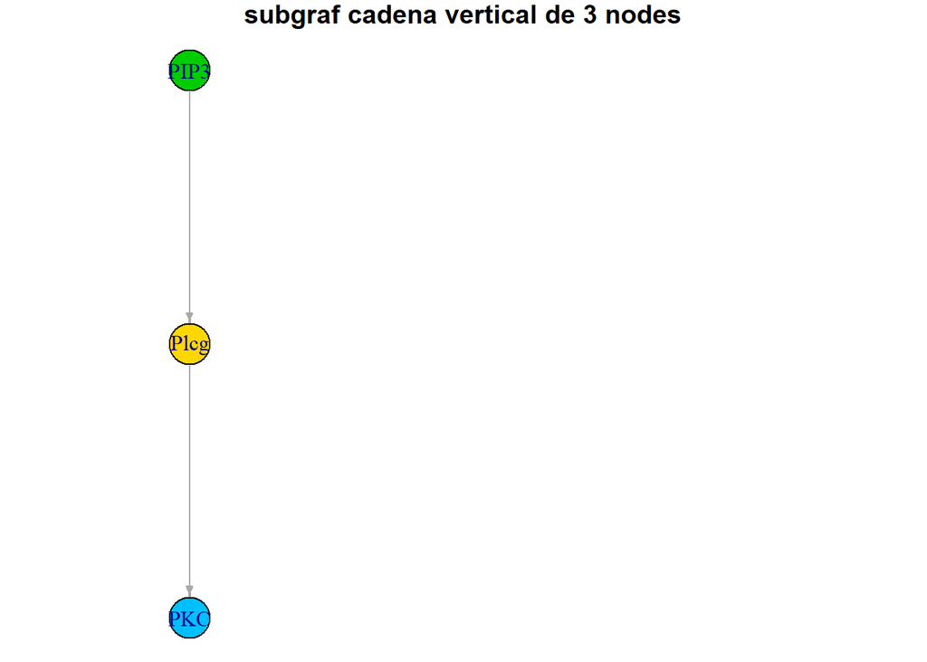

```r
cadena3n_vertical <- subgraph_from_edges(g_bosc_vertical, eids = c(4,11))

arrels1 <- V(cadena3n_vertical)$name[degree(cadena3n_vertical, mode="in") == 0]
fulles1 <- V(cadena3n_vertical)$name[degree(cadena3n_vertical, mode="out") == 0]
noms_nodes1 <- V(cadena3n_vertical)$name

V(cadena3n_vertical)$role <- ifelse(!is.na(match(noms_nodes1, arrels1)), "arrel",
                      ifelse(!is.na(match(noms_nodes1,fulles1 )), "fulla", "mitjancer"))


V(cadena3n_vertical)$color <- ifelse(V(cadena3n_vertical)$role == "arrel" , "green3",
                                ifelse(V(cadena3n_vertical)$role =="fulla", "deepskyblue", "gold"                                    ))


par(mar=c(0,0,1,0))
plot(cadena3n_vertical,
     layout=layout_as_tree(cadena3n_vertical, , root = arrels1),
     edge.arrow.size=0.4,
     vertex.size=15,
     main ="subgraf cadena vertical de 3 nodes")
```

```r
nodes_cadena <- c("PIP3", "Plcg", "PKC")
cadena3n <- induced_subgraph(g_bosc, vids = nodes_cadena)

(theta_cadena3n_Z <- theta_flux_vectorial_Z_fisic(cadena3n, coords3Dn_diag_corr1))
```

```
## $u_bar
## [1]  4.487732 14.467311 24.676170
##
## $len_u
## [1] 28.95438
##
## $flux_z
## [1] 24.67617
##
## $theta_z
## [1] 31.54352
##
## $signe
## [1] 1
```

```r
cat("Angle del flux vertical de la cadena PIP3->Plcg->PKC:", round(as.numeric(theta_cadena3n_Z$theta_z[1]), 2), "graus\n")
```

```
## Angle del flux vertical de la cadena PIP3->Plcg->PKC: 31.54 graus
```

```r
collididor_artificial <- crea_collididor_artificial(g_bosc, c("PIP3", "Plcg", "PKC"))

(theta_col_Plcg_Z <- theta_flux_collididor_Z_fisic(collididor_artificial, coords3Dn_diag_corr1))
```

```
## $r_in
## [1] -8.779050  2.272467  3.994911
##
## $len_r
## [1] 9.909346
##
## $flux_z
## [1] 3.994911
##
## $theta_z
## [1] 66.22501
##
## $signe
## [1] 1
```

```r
cat(sprintf("Angle del flux condicionat (collididor Plcg) respecte a Z: %.2f\n",
          theta_col_Plcg_Z$theta_z))
```

```
## Angle del flux condicionat (collididor Plcg) respecte a Z: 66.23
```

A theta_col_Plcg_XY i a theta_col_Plcg_XY, hom hi resta 90 graus a fi d’obtenir l’angle respecte el pla XY (aquest no és contraintuïtiu com sí que n’és l’angle respecte l’eix Y)

```r
nodes_cadena <- c("PIP3", "Plcg", "PKC")
cadena3n <- induced_subgraph(g_bosc, vids = nodes_cadena)

(theta_cadena3n_XY <- theta_flux_vectorial_XY_fisic(cadena3n, coords3Dn_diag_corr1))
```

```
## $u_bar
## [1]  4.487732 14.467311 24.676170
##
## $len_u
## [1] 28.95438
##
## $flux_z
## [1] 24.67617
##
## $theta_xy
## [1] 58.45648
##
## $signe
## [1] 1
```

```r
cat("Angle del flux vertical de la cadena PIP3->Plcg->PKC:", round(as.numeric(theta_cadena3n_XY$theta_xy), 2), "graus\n")
```

```
## Angle del flux vertical de la cadena PIP3->Plcg->PKC: 58.46 graus
```

```r
collididor_artificial <- crea_collididor_artificial(g_bosc, c("PIP3", "Plcg", "PKC"))

(theta_col_Plcg_XY <- theta_flux_collididor_XY_fisic(collididor_artificial, coords3Dn_diag_corr1))
```

```
## $r_in
## [1] -9.165600  2.372526  4.170811
##
## $len_r
## [1] 10.34566
##
## $flux_z
## [1] 4.170811
##
## $theta_xy
## [1] 23.77499
##
## $signe
## [1] 1
```

```r
cat(sprintf("Angle del flux condicionat (collididor Plcg) respecte a Z: %.2f\n",
          theta_col_Plcg_XY$theta_xy ))
```

```
## Angle del flux condicionat (collididor Plcg) respecte a Z: 23.77
```

```r
open3d()
```

```
## wgl
##  19
```

```r
#aspect3d(1,1,1)

coords_CADENA <- coords3Dn_diag_corr1[c("PIP3", "Plcg", "PKC"), c("X", "Y", "Z")]

plot3d(coords_CADENA, col = "gold", size = 1, type = "s", box = TRUE)

# arestes direccionals
edges <- as_edgelist(cadena3n)
for (i in seq_len(nrow(edges))) {
  p0 <- coords_CADENA[edges[i, 1], ]  # origen pel nom
  p1 <- coords_CADENA[edges[i, 2], ]  # destí pel nom

  arrow3d(
    p0 = as.numeric(p0),
    p1 = as.numeric(p1),
    type = "rotation",
    col = "grey40",
    lwd = 2,
    width = 0.2,
    barblen = 0.025,
    n = 4
  )
}

text3d(coords_CADENA[,1] + 0.02,
       coords_CADENA[,2],
       coords_CADENA[,3] + 0.04,
       texts = rownames(coords_CADENA),
       adj = c(0,0.5))


#___________________________________________________________________________
# longitud real del camí

len_flux <- longitud_cami_fisic(cadena3n, coords3Dn_diag_corr1)

#___________________________________________________________________________
# cal que la direcció sigui ascendent
# if (u_bar[3] < 0) u_bar <- -u_bar (és el flux global)
# origen i extrem de la segeta
res_flux <- theta_flux_vectorial_Z_fisic(cadena3n, coords3Dn_diag_corr1)
u_bar <- as.numeric(res_flux$u_bar)
len_flux <- sqrt(sum(u_bar^2))   # mòdul del vector resultant
#u_dir <- u_bar / sqrt(sum(u_bar^2)) # és una unitat de direcció , no afecta la distància del mòdul del vector director
u_dir <- u_bar / len_flux        # encara unitari

p0_flux <- coords_CADENA["PIP3",c("X","Y","Z")]
p1_flux <- p0_flux + len_flux * u_dir


# segeta blava
arrow3d(
  p0 = p0_flux,
  p1 = p1_flux,
  col = "skyblue",
  type = "rotation",
  lwd = 3,
  width = 0.1,
  barblen = 0.02
)
text3d(p1_flux[1], p1_flux[2], p1_flux[3] + 3,
       texts = "Flux causal local: 58.46 respecte al pla XY", color = "black")



#___________________________________________________________________________

bbox <- par3d("bbox")
xmin <- bbox[1]; xmax <- bbox[2]
ymin <- bbox[3]; ymax <- bbox[4]
zmin <- bbox[5]; zmax <- bbox[6]

segments3d(rbind(c(xmin, ymin, zmin), c(xmax, ymin, zmin)), col="red", lwd=3)
text3d(xmax, ymin, zmin, texts="X = deg_out", color="red", adj=c(-0.2,0.5))

segments3d(rbind(c(xmin, ymin, zmin), c(xmin, ymax, zmin)), col="green3", lwd=3)
text3d(xmin, ymax, zmin, texts="Y = deg_in", color="green3", adj=c(0.5,-0.2))

segments3d(rbind(c(xmin, ymin, zmin), c(xmin, ymin, zmax)), col="blue3", lwd=3)
text3d(xmin, ymin, zmax, texts="Z = nivell", color="blue3", adj=c(0.5,0))


rglwidget()
```

[interactive chart not shown]

Si hom condiciona pel node medial, llavors el flux es trenca i el vector de Plcg–>PKC esdevé Plcg<–PKC

```r
coords_CADENA <- coords3Dn_diag_corr1[c("PIP3", "Plcg", "PKC"), c("X", "Y", "Z")]

# longitud camí
len_flux <- longitud_cami_fisic(cadena3n, coords3Dn_diag_corr1)

#SEGETA BLAVA
# origen i extrem de la segeta
res_flux <- theta_flux_vectorial_Z_fisic(cadena3n, coords3Dn_diag_corr1)
u_bar <- as.numeric(res_flux$u_bar)
#u_dir <- u_bar / sqrt(sum(u_bar^2))
len_flux_u <- sqrt(sum(u_bar^2))   # mòdul del vector resultant
u_dir <- u_bar / len_flux_u        # encara unitari

p0_flux <- coords_CADENA["PIP3",c("X","Y","Z")]
p1_flux <- p0_flux + len_flux_u * u_dir

#___________________________________________________________________________

#SEGETA VERMELLA
res_cond <- theta_flux_collididor_Z_fisic(
  crea_collididor_artificial(g_bosc_vertical, c("PIP3", "Plcg", "PKC")),
  coords3Dn_diag_corr1)


u_cond <- res_cond$r_in # vector direccional condicionat: r_out <- r_in era correcte per tal de calcular l’angle (perquè volem l’efecte reacció), però per dibuixar la direcció del flux condicionat, el vector que hom vol mostrar és r_in, no r_out
len_flux_cond <- sqrt(sum(u_cond^2)) # mòdul real del flux condicionat (no del vector unitari!)
u_dir_cond <- u_cond / len_flux_cond # vector unitari de direcció


p0_cond <- coords_CADENA["Plcg", c("X","Y","Z")] # origen del flux condicionat
p1_cond <- p0_cond + len_flux_cond * u_dir_cond # punt final del flux


#_____________________________________________________________________________

# Mòduls reals dibuixats al plot
mod_blau_plot <- sqrt(sum((p1_flux - p0_flux)^2))
mod_vermell_plot <- sqrt(sum((p1_cond - p0_cond)^2))

cat("Mòdul blau real (plot)  :", mod_blau_plot, "\n")
```

```
## Mòdul blau real (plot)  : 28.95438
```

```r
cat("Mòdul vermell real (plot) :", mod_vermell_plot, "\n")
```

```
## Mòdul vermell real (plot) : 9.909346
```

```r
# bloc de codi fins a [3] per tal de desplaçar el model a un espai positiu
# hom combina totes les coordenades que apareixen al gràfic
all_coords <- rbind(coords_CADENA,
                    p0_flux, p1_flux, p0_cond, p1_cond )
# hom calcula quant s'ha de desplaçar cada eix perquè el mínim sigui 000
offset <- apply(all_coords, 2, min)

# hom aplica el desplaçament
coords_CADENA <- sweep(coords_CADENA, 2, offset, "-")
p0_flux  <- p0_flux - offset
p1_flux  <- p1_flux - offset
p0_cond  <- p0_cond - offset
p1_cond  <- p1_cond - offset
# [3]__________________________________________________________________________


clear3d()
close3d()
open3d()
```

```
## wgl
##  21
```

```r
# dibuixa els punts
plot3d(coords_CADENA, col = "gold", size = 1, type = "s", box = TRUE)

# arestes direccionals
edges <- as_edgelist(cadena3n)

  cap1 <- coords_CADENA[edges[1, 1], ]  # origen pel nom
  cua1 <- coords_CADENA[edges[1, 2], ]  # destí pel nom

  cap2 <- coords_CADENA[edges[2, 2], ]  # origen pel nom
  cua2 <- coords_CADENA[edges[2, 1], ]  # destí pel nom

  arrow3d(
    p0 = as.numeric(cap1),
    p1 = as.numeric(cua1),
    type = "rotation",
    col = "grey40",
    lwd = 2,
    width = 0.2,
    barblen = 0.025,
    n = 4
  )

  arrow3d(
    p0 = as.numeric(cap2),
    p1 = as.numeric(cua2),
    type = "rotation",
    col = "grey40",
    lwd = 2,
    width = 0.2,
    barblen = 0.025,
    n = 4
  )

text3d(coords_CADENA[,1] + 0.02,
       coords_CADENA[,2],
       coords_CADENA[,3] + 0.04,
       texts = rownames(coords_CADENA),
       adj = c(0,0.5))

#___________________________________________________________________________


# segeta blava
arrow3d(
  p0 = p0_flux,
  p1 = p1_flux,
  col = "blue",
  type = "rotation",
  lwd = 3,
  width = 0.25,
  barblen = 0.02
)
text3d(p1_flux[1], p1_flux[2], p1_flux[3] + 2,
       texts = "Flux causal local (theta_y=31.54 , theta_xy=58.46)", color = "black")

#============================================================================

# segeta vermella
arrow3d(
  p0 = p0_cond,
  p1 = p1_cond,
  col = "red3",
  type = "rotation",
  lwd = 3,
  width = 0.25,
  barblen = 0.02
)

aspect3d(1,1,1)
text3d(p1_cond[1], p1_cond[2], p1_cond[3] + 4,
       texts = sprintf("Flux condicional (theta_y=66.23 , theta_xy=23.77)"),
       color = "black")

#_________________________________________________________________________
aspect3d(1,1,1)

# límits actuals del sistema de coordenades rgl
bbox <- par3d("bbox")  # retorna un vector amb xmin, xmax, ymin, ymax, zmin, zmax
xmin <- bbox[1]; xmax <- bbox[2]
ymin <- bbox[3]; ymax <- bbox[4]
zmin <- bbox[5]; zmax <- bbox[6]

# eixos segons el contingut visible
segments3d(rbind(c(xmin, ymin, zmin), c(xmax, ymin, zmin)), col="red", lwd=3)
text3d(xmax, ymin, zmin, texts="X = deg_out", color="red", adj=c(-0.2,0.5))

segments3d(rbind(c(xmin, ymin, zmin), c(xmin, ymax, zmin)), col="green3", lwd=3)
text3d(xmin, ymax, zmin, texts="Y = deg_in", color="green3", adj=c(0.5,-0.2))

segments3d(rbind(c(xmin, ymin, zmin), c(xmin, ymin, zmax)), col="blue3", lwd=3)
text3d(xmin, ymin, zmax, texts="Z = nivell", color="blue3", adj=c(0.5,0))
rglwidget()
```

[interactive chart not shown]

```r
# vectors entrants al node Plcg
v_PIP3 <- coords3Dn_diag_corr1["Plcg", c("X","Y","Z")] -
          coords3Dn_diag_corr1["PIP3", c("X","Y","Z")]

v_PKC  <- coords3Dn_diag_corr1["Plcg", c("X","Y","Z")] -
          coords3Dn_diag_corr1["PKC",  c("X","Y","Z")]


cat("longitud dels dos vectors")
```

```
## longitud dels dos vectors
```

```r
# mòduls reals
L_PIP3 <- sqrt(sum(v_PIP3^2))
L_PKC  <- sqrt(sum(v_PKC^2))

L_PIP3
```

```
## [1] 16.86424
```

```r
L_PKC
```

```
## [1] 13.72194
```

```r
coords3Dn_diag_corr1["Plcg",] - coords3Dn_diag_corr1["PIP3",]
```

```
##         X         Y         Z
## -2.338934  8.419919 14.423491
```

```r
coords3Dn_diag_corr1["Plcg",] - coords3Dn_diag_corr1["PKC",]
```

```
##          X          Y          Z
##  -6.826666  -6.047392 -10.252680
```

```r
# mòduls reals dibuixats al plot
mod_blau_plot <- sqrt(sum((p1_flux - p0_flux)^2))
mod_vermell_plot <- sqrt(sum((p1_cond - p0_cond)^2))

 cat("Mòdul blau real (plot)  :", mod_blau_plot, "\n")
```

```
## Mòdul blau real (plot)  : 28.95438
```

```r
 cat("Mòdul vermell real (plot) :", mod_vermell_plot, "\n")
```

```
## Mòdul vermell real (plot) : 9.909346
```

```r
cadena3n_vertical <- dagitty('dag {
bb="-0.5,-0.5,0.5,0.5"
Plcg [pos="12.801835,  8.419918510, 14.423490868"]
PIP3 [pos="15.140769,  0.000000000,  0.000000000"]
PKC [pos="19.628501, 14.467310719, 24.676170477"]
PIP3 -> Plcg
Plcg -> PKC
}
')

(pathway_ind_con <- localTests(x = cadena3n_vertical, data = dades[,c(3,5,9)], type = "cis"))
```

|  | estimate | p.value | 2.5% | 97.5% |
| --- | --- | --- | --- | --- |
| PIP3 _\|\|_ PKC \| Plcg | 0.04603344 | 6.491795e-07 | 0.02791405 | 0.06412268 |

### *5.6.3 SUBGRAF AïLLAT: CADENA LATERAL DE N=3 NODES AMB TEST NEGATIU del model geomètric topoempíric*

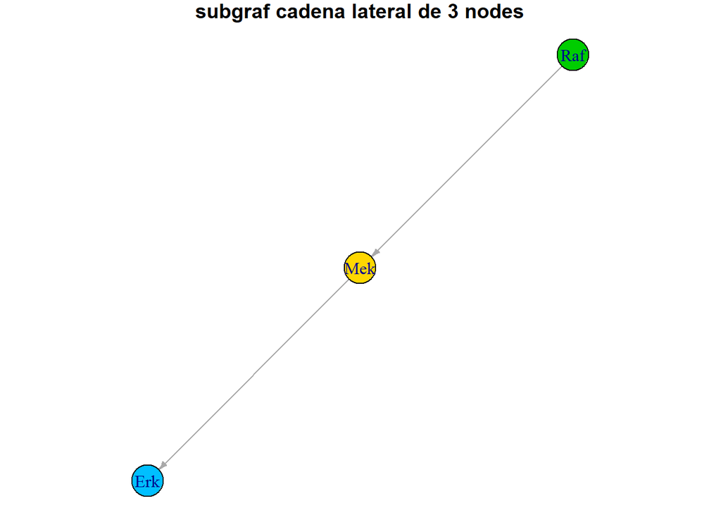

```r
cadena3n_lateral <- subgraph_from_edges(g_bosc, eids = c(1,18))

arrels1 <- V(cadena3n_lateral)$name[degree(cadena3n_lateral, mode="in") == 0]
fulles1 <- V(cadena3n_lateral)$name[degree(cadena3n_lateral, mode="out") == 0]
noms_nodes1 <- V(cadena3n_lateral)$name

V(cadena3n_lateral)$role <- ifelse(!is.na(match(noms_nodes1, arrels1)), "arrel",
                      ifelse(!is.na(match(noms_nodes1,fulles1 )), "fulla", "mitjancer"))

V(cadena3n_lateral)$color <- ifelse(V(cadena3n_lateral)$role == "arrel" , "green3",
                                ifelse(V(cadena3n_lateral)$role =="fulla", "deepskyblue", "gold"                                    ))
par(mar=c(0,0,1,0))
plot(cadena3n_lateral,
     edge.arrow.size=0.4,
     vertex.size=15,
     main ="subgraf cadena lateral de 3 nodes")
```

Aquí també hom rebutja la independència

```r
cadena3n_lateral1 <- dagitty('dag {
bb="-0.5,-0.5,0.5,0.5"
Raf [pos="8.017768 , 16.705511579 , 14.051138412"]
Mek [pos="7.997961  , 29.315418380 ,  11.497698618"]
Erk [pos="0.000000, 15.550560292, 14.465575026"]
Raf -> Mek
Mek -> Erk
}
')
(pathway_ind_con <- localTests(x = cadena3n_lateral1, data = dades[,c(1,2,6)], type = "cis"))
```

|  | estimate | p.value | 2.5% | 97.5% |
| --- | --- | --- | --- | --- |
| Erk _\|\|_ Raf \| Mek | -0.08165858 | 9.544188e-19 | -0.09965431 | -0.06361018 |

```r
nodes_cadena_lat <- c("Raf", "Mek", "Erk")
cadena3n_lateral <- induced_subgraph(g_bosc, vids = nodes_cadena_lat)

(theta_cadena3n_lat <- theta_flux_vectorial_Z_fisic(cadena3n_lateral, coords3Dn_diag_corr1))
```

```
## $u_bar
## [1] -8.0177678 -1.1549513  0.4144366
##
## $len_u
## [1] 8.11112
##
## $flux_z
## [1] 0.4144366
##
## $theta_z
## [1] 87.0712
##
## $signe
## [1] 1
```

```r
cat("Angle del flux lateral de la cadena Raf->Mek->Erk:", round(as.numeric(theta_cadena3n_lat$theta_z), 2), "graus\n")
```

```
## Angle del flux lateral de la cadena Raf->Mek->Erk: 87.07 graus
```

Ara cal calcular l’angle del flux condicionat (el node medial de la cadena esdevé un col·lididor)

```r
collididor_artificial_lat <- crea_collididor_artificial(g_bosc, c("Raf", "Mek", "Erk"))

(theta_col_Mek <- theta_flux_collididor_Z_fisic(collididor_artificial_lat, coords3Dn_diag_corr1))
```

```
## $r_in
## [1]  7.974481 26.362619 -5.518774
##
## $len_r
## [1] 28.0898
##
## $flux_z
## [1] -5.518774
##
## $theta_z
## [1] 78.66945
##
## $signe
## [1] -1
```

```r
cat(sprintf("Angle del flux condicionat (theta_col_Mek PIP2) respecte a Z: %.2f\n",
          theta_col_Mek$theta_z))
```

```
## Angle del flux condicionat (theta_col_Mek PIP2) respecte a Z: 78.67
```

```r
print(as_edgelist(collididor_artificial_lat))
```

```
##      [,1]  [,2]
## [1,] "Raf" "Mek"
## [2,] "Erk" "Mek"
```

```r
nodes_cadena_lat <- c("Raf", "Mek", "Erk")
cadena3n_lateral <- induced_subgraph(g_bosc, vids = nodes_cadena_lat)

(theta_cadena3n_lat <- theta_flux_vectorial_XY_fisic(cadena3n_lateral, coords3Dn_diag_corr1))
```

```
## $u_bar
## [1] -8.0177678 -1.1549513  0.4144366
##
## $len_u
## [1] 8.11112
##
## $flux_z
## [1] 0.4144366
##
## $theta_xy
## [1] 2.928796
##
## $signe
## [1] 1
```

```r
cat("Angle del flux lateral de la cadena Raf->Mek->Erk:", round(as.numeric(theta_cadena3n_lat$theta_xy), 2), "graus\n")
```

```
## Angle del flux lateral de la cadena Raf->Mek->Erk: 2.93 graus
```

```r
collididor_artificial_lat <- crea_collididor_artificial(g_bosc, c("Raf", "Mek", "Erk"))

(theta_col_Mek <- theta_flux_collididor_XY_fisic(collididor_artificial_lat, coords3Dn_diag_corr1))
```

```
## $r_in
## [1]  7.978155 26.374765 -5.521316
##
## $len_r
## [1] 28.10274
##
## $flux_z
## [1] -5.521316
##
## $theta_xy
## [1] 11.33055
##
## $signe
## [1] -1
```

```r
cat(sprintf("Angle del flux condicionat (theta_col_Mek PIP2) respecte a Z: %.2f\n",
          theta_col_Mek$theta_xy))
```

```
## Angle del flux condicionat (theta_col_Mek PIP2) respecte a Z: 11.33
```

```r
print(as_edgelist(collididor_artificial_lat))
```

```
##      [,1]  [,2]
## [1,] "Raf" "Mek"
## [2,] "Erk" "Mek"
```

```r
# bloc de codi fins a [1] per tal de dibuixar el vector director al plot3d sense valors negatius:
# el p1_flux té valors negatius i cal fer el recalcul de les coordenades abans de fer el plot3d
nodes_cadena_Raf_Mek_Erk <- c("Raf", "Mek", "Erk")
cadena3n_Raf_Mek_Erk <- induced_subgraph(g_bosc, vids = nodes_cadena_Raf_Mek_Erk)
coords_cadena3nRaf_Mek_Erk <- coords3Dn_diag_corr1[c("Raf", "Mek", "Erk"), c("X", "Y", "Z")]

# longitud camí
len_flux <- longitud_cami_fisic(cadena3n_Raf_Mek_Erk, coords3Dn_diag_corr1)

res_flux <- theta_flux_vectorial_Z_fisic(cadena3n_Raf_Mek_Erk, coords3Dn_diag_corr1)
u_bar <- as.numeric(res_flux$u_bar)
u_dir <- u_bar / sqrt(sum(u_bar^2))

p0_flux <- coords_cadena3nRaf_Mek_Erk["Raf",c("X","Y","Z")]
p1_flux <- p0_flux + len_flux * u_dir

coords_CADENA_lat <- coords3Dn_diag_corr1[c("Raf", "Mek", "Erk"), c("X", "Y", "Z")]

# [1]___________________________________________________________________________

# bloc de codi fins a [2] per tal de desplaçar el model a un espai positiu
# hom combina totes les coordenades que apareixen al gràfic
all_coords <- rbind(coords_CADENA_lat,
                    p0_flux, p1_flux)
# hom calcula quant s'ha de desplaçar cada eix perquè el mínim sigui 000
offset1 <- apply(all_coords, 2, min)

# hom aplica el desplaçament
coords_CADENA_lat <- sweep(coords_CADENA_lat, 2, offset1, "-")
p0_flux  <- p0_flux - offset1
p1_flux  <- p1_flux - offset1

# [2]___________________________________________________________________________

open3d()
```

```
## wgl
##  23
```

```r
# dibuixa els punts
plot3d(coords_CADENA_lat, col = "gold", size = 1, type = "s", box = TRUE)

# arestes direccionals
edges <- as_edgelist(cadena3n_Raf_Mek_Erk)
for (i in seq_len(nrow(edges))) {
  p0 <- coords_CADENA_lat[edges[i, 1], ]  # origen pel nom
  p1 <- coords_CADENA_lat[edges[i, 2], ]  # destí pel nom

  arrow3d(
    p0 = as.numeric(p0),
    p1 = as.numeric(p1),
    type = "rotation",
    col = "grey40",
    lwd = 2,
    width = 0.2,
    barblen = 0.025,
    n = 4
  )
}

text3d(coords_CADENA_lat[,1] + 0.02,
       coords_CADENA_lat[,2],
       coords_CADENA_lat[,3] + 0.04,
       texts = rownames(coords_CADENA_lat),
       adj = c(0,0.5))





# segeta blava de vector director calculat al bloc de codi [1]
arrow3d(
  p0 = p0_flux,
  p1 = p1_flux,
  col = "blue",
  type = "rotation",
  lwd = 3,
  width = 0.3,
  barblen = 0.02
)
text3d(p1_flux[1], p1_flux[2], p1_flux[3] -0.25,
       texts = "Flux causal local", color = "black")
aspect3d(1,1,1)




bbox <- par3d("bbox")
xmin <- bbox[1]; xmax <- bbox[2]
ymin <- bbox[3]; ymax <- bbox[4]
zmin <- bbox[5]; zmax <- bbox[6]

segments3d(rbind(c(xmin, ymin, zmin), c(xmax, ymin, zmin)), col="red", lwd=3)
text3d(xmax, ymin, zmin, texts="X = deg_out", color="red", adj=c(-0.2,0.5))

segments3d(rbind(c(xmin, ymin, zmin), c(xmin, ymax, zmin)), col="green3", lwd=3)
text3d(xmin, ymax, zmin, texts="Y = deg_in", color="green3", adj=c(0.5,-0.2))

segments3d(rbind(c(xmin, ymin, zmin), c(xmin, ymin, zmax)), col="blue3", lwd=3)
text3d(xmin, ymin, zmax, texts="Z = nivell", color="blue3", adj=c(0.5,0))
rglwidget()
```

[interactive chart not shown]

```r
nodes_cadena_lat <- c("Raf", "Mek", "Erk")
cadena3n_lat <- induced_subgraph(g_bosc, vids = nodes_cadena_lat)
edges_lat <- as_edgelist(cadena3n_lat)

coords_CADENA_lat <- coords3Dn_diag_corr1[c("Raf", "Mek", "Erk"), c("X", "Y", "Z")]

# bloc de codi fins a [1] per tal de dibuixar el vector director al plot3d sense valors negatius:
# el p1_flux té valors negatius i cal fer el recalcul de les coordenades abans de fer el plot3d
nodes_cadena_Raf_Mek_Erk <- c("Raf", "Mek", "Erk")
cadena3n_Raf_Mek_Erk <- induced_subgraph(g_bosc, vids = nodes_cadena_Raf_Mek_Erk)
coords_cadena3n_Raf_Mek_Erk <- coords3Dn_diag_corr1[c("Raf", "Mek", "Erk"), c("X", "Y", "Z")]

# longitud camí
len_flux <- longitud_cami_fisic(cadena3n_Raf_Mek_Erk, coords3Dn_diag_corr1)

res_flux <- theta_flux_vectorial_Z_fisic(cadena3n_Raf_Mek_Erk, coords3Dn_diag_corr1)
u_bar <- as.numeric(res_flux$u_bar)
u_dir <- u_bar / sqrt(sum(u_bar^2))

p0_flux <- coords_cadena3n_Raf_Mek_Erk["Raf",c("X","Y","Z")]
p1_flux <- p0_flux + len_flux * u_dir

#___________________________________________________________________________

#SEGETA VERMELLA
res_cond <- theta_flux_collididor_Z_fisic(
  crea_collididor_artificial(g_bosc_vertical, c("Raf", "Mek", "Erk")),
  coords3Dn_diag_corr1)


u_cond <- res_cond$r_in # vector direccional condicionat: r_out <- r_in era correcte per tal de calcular l’angle (perquè volem l’efecte reacció), però per dibuixar la direcció del flux condicionat, el vector que hom vol mostrar és r_in, no r_out
len_flux_cond <- sqrt(sum(u_cond^2)) # mòdul real del flux condicionat (no del vector unitari!)
u_dir_cond <- u_cond / len_flux_cond # vector unitari de direcció


p0_cond <- coords_CADENA_lat["Mek", c("X","Y","Z")] # origen del flux condicionat
p1_cond <- p0_cond + len_flux_cond * u_dir_cond # punt final del flux


#_____________________________________________________________________________

# Mòduls reals dibuixats al plot
mod_blau_plot <- sqrt(sum((p1_flux - p0_flux)^2))
mod_vermell_plot <- sqrt(sum((p1_cond - p0_cond)^2))

cat("Mòdul blau real (plot)  :", mod_blau_plot, "\n")
```

```
## Mòdul blau real (plot)  : 29.0599
```

```r
cat("Mòdul vermell real (plot) :", mod_vermell_plot, "\n")
```

```
## Mòdul vermell real (plot) : 28.0898
```

```r
# bloc de codi fins a [3] per tal de desplaçar el model a un espai positiu
# hom combina totes les coordenades que apareixen al gràfic
all_coords <- rbind(coords_CADENA_lat,
                    p0_flux, p1_flux, p0_cond, p1_cond )
# hom calcula quant s'ha de desplaçar cada eix perquè el mínim sigui 000
offset <- apply(all_coords, 2, min)

# hom aplica el desplaçament
coords_CADENA_lat <- sweep(coords_CADENA_lat, 2, offset, "-")
p0_flux  <- p0_flux - offset
p1_flux  <- p1_flux - offset
p0_cond  <- p0_cond - offset
p1_cond  <- p1_cond - offset
# [3]__________________________________________________________________________


clear3d()
close3d()
open3d()
```

```
## wgl
##  25
```

```r
# dibuixa els punts
plot3d(coords_CADENA_lat, col = "gold", size = 1, type = "s", box = TRUE)

# arestes direccionals
edges <- as_edgelist(cadena3n)

  cap1 <- coords_CADENA_lat[edges_lat[1, 1], ]  # origen pel nom
  cua1 <- coords_CADENA_lat[edges_lat[1, 2], ]  # destí pel nom

  cap2 <- coords_CADENA_lat[edges_lat[2, 2], ]  # origen pel nom
  cua2 <- coords_CADENA_lat[edges_lat[2, 1], ]  # destí pel nom

  arrow3d(
    p0 = as.numeric(cua1),
    p1 = as.numeric(cap1),
    type = "rotation",
    col = "grey40",
    lwd = 2,
    width = 0.2,
    barblen = 0.025,
    n = 4
  )

  arrow3d(
    p0 = as.numeric(cua2),
    p1 = as.numeric(cap2),
    type = "rotation",
    col = "grey40",
    lwd = 2,
    width = 0.2,
    barblen = 0.025,
    n = 4
  )

text3d(coords_CADENA_lat[,1] + 0.02,
       coords_CADENA_lat[,2],
       coords_CADENA_lat[,3] + 0.04,
       texts = rownames(coords_CADENA_lat),
       adj = c(0,0.5))


# segeta blava de vector director calculat al bloc de codi [1]
arrow3d(
  p0 = p0_flux,
  p1 = p1_flux,
  col = "blue",
  type = "rotation",
  lwd = 3,
  width = 0.3,
  barblen = 0.02
)
text3d(p1_flux[1], p1_flux[2], p1_flux[3] -0.25,
       texts = sprintf("Flux causal local(theta_y=87.07 , theta_xy=2.93)",
       color = "black"))
#============================================================================

# segeta vermella
arrow3d(
  p0 = p0_cond,
  p1 = p1_cond,
  col = "red3",
  type = "rotation",
  lwd = 3,
  width = 0.25,
  barblen = 0.02
)

aspect3d(1,1,1)
text3d(p1_cond[1], p1_cond[2], p1_cond[3] + 4,
       texts = sprintf("Flux condicional (theta_y=78.67 , theta_xy=11.33)",
       color = "black"))
#_________________________________________________________________________
aspect3d(1,1,1)



bbox <- par3d("bbox")
xmin <- bbox[1]; xmax <- bbox[2]
ymin <- bbox[3]; ymax <- bbox[4]
zmin <- bbox[5]; zmax <- bbox[6]

segments3d(rbind(c(xmin, ymin, zmin), c(xmax, ymin, zmin)), col="red", lwd=3)
text3d(xmax, ymin, zmin, texts="X = deg_out", color="red", adj=c(-0.2,0.5))

segments3d(rbind(c(xmin, ymin, zmin), c(xmin, ymax, zmin)), col="green3", lwd=3)
text3d(xmin, ymax, zmin, texts="Y = deg_in", color="green3", adj=c(0.5,-0.2))

segments3d(rbind(c(xmin, ymin, zmin), c(xmin, ymin, zmax)), col="blue3", lwd=3)
text3d(xmin, ymin, zmax, texts="Z = nivell", color="blue3", adj=c(0.5,0))
rglwidget()
```

[interactive chart not shown]

### *5.6.4 BATERIA DE SUBGRAFS AïLLATS de 3 NODES AMB TEST POSITIU del model geomètric topoempíric*

Aquí hi han tots els tests positius de localTest(), és a dir, que les dades refermen l’estructura del DAG 2D amb una p_vàlua igual o més gran que 0.05.

```r
LT <- localTests(pathway_net, data = dades, type = "cis")
(LT1 <- LT[c(14:16,25,29,34,36,43:44,48,51,56,58),1:2])
```

|  | estimate | p.value |
| --- | --- | --- |
| Akt _\|\|_ PIP2 \| PIP3 | -0.0136374356 | 0.1407006 |
| Akt _\|\|_ PKC \| PIP2, Plcg | -0.0034278992 | 0.7111872 |
| Akt _\|\|_ PKC \| PIP3 | -0.0039815169 | 0.6671376 |
| Erk _\|\|_ PIP2 \| PKC | -0.0106795997 | 0.2486485 |
| Erk _\|\|_ PIP3 \| Mek, PKA | 0.0007349409 | 0.9367273 |
| Jnk _\|\|_ Mek \| PKA, PKC | 0.0087265133 | 0.3458812 |
| Jnk _\|\|_ PIP2 \| PKC | 0.0131965556 | 0.1539968 |
| Mek _\|\|_ PIP3 \| PIP2, Plcg | -0.0122087025 | 0.1872444 |
| Mek _\|\|_ PIP3 \| PKC | -0.0099681582 | 0.2815780 |
| P38 _\|\|_ PIP3 \| PKC | -0.0015846976 | 0.8640847 |

[output cut: 3 more lines]

D’aquests hom en calcula els angles dels 6 subgrafs aïllats amb 3 nodes, atès que les funcions aquí definides són de 3 nodes. Hom ja veu en què la majoria són implicats amb el node PKC, sobretot amb arestes de retrovertical.

```r
(LT2 <- LT1[c(1,3:4,7,9:10),])
```

|  | estimate | p.value |
| --- | --- | --- |
| Akt _\|\|_ PIP2 \| PIP3 | -0.013637436 | 0.1407006 |
| Akt _\|\|_ PKC \| PIP3 | -0.003981517 | 0.6671376 |
| Erk _\|\|_ PIP2 \| PKC | -0.010679600 | 0.2486485 |
| Jnk _\|\|_ PIP2 \| PKC | 0.013196556 | 0.1539968 |
| Mek _\|\|_ PIP3 \| PKC | -0.009968158 | 0.2815780 |
| P38 _\|\|_ PIP3 \| PKC | -0.001584698 | 0.8640847 |

### *P38 *||* PIP3 | PKC* (plantejable com a cadena PIP3->…->PKC->P38)

```r
nodes_cadena_1 <- c("PIP3", "PKC", "P38")
cadena3n_1 <- induced_subgraph(g_bosc, vids = nodes_cadena_1)

(theta_cadena3n_1 <- theta_flux_vectorial_Z_fisic(cadena3n_1, coords3Dn_diag_corr1))
```

```
## $u_bar
## [1] -18.480944  -1.507105 -19.226814
##
## $len_u
## [1] 26.71118
##
## $flux_z
## [1] -19.22681
##
## $theta_z
## [1] 43.9617
##
## $signe
## [1] -1
```

```r
cat("Angle del flux lateral de la cadena PIP2->PKC->P38:", round(as.numeric(theta_cadena3n_1$theta_z), 2), "graus\n")
```

```
## Angle del flux lateral de la cadena PIP2->PKC->P38: 43.96 graus
```

```r
collididor_artificial_1 <- crea_collididor_artificial(g_bosc,  c("PIP3", "PKC", "P38"))

(theta_col_PKC <- theta_flux_collididor_Z_fisic(collididor_artificial_1, coords3Dn_diag_corr1))
```

```
## $r_in
## [1] 22.96600 15.97255 43.89787
##
## $len_r
## [1] 52.05365
##
## $flux_z
## [1] 43.89787
##
## $theta_z
## [1] 32.50765
##
## $signe
## [1] 1
```

```r
cat(sprintf("Angle del flux condicionat (theta_col_PKC) respecte a Z: %.2f\n",
          theta_col_PKC$theta_z))
```

```
## Angle del flux condicionat (theta_col_PKC) respecte a Z: 32.51
```

```r
print(as_edgelist(collididor_artificial_1))
```

```
##      [,1]   [,2]
## [1,] "PIP3" "PKC"
## [2,] "P38"  "PKC"
```

```r
nodes_cadena_1 <- c("PIP3", "PKC", "P38")
cadena3n_1 <- induced_subgraph(g_bosc, vids = nodes_cadena_1)

(theta_cadena3n_1 <- theta_flux_vectorial_XY_fisic(cadena3n_1, coords3Dn_diag_corr1))
```

```
## $u_bar
## [1] -18.480944  -1.507105 -19.226814
##
## $len_u
## [1] 26.71118
##
## $flux_z
## [1] -19.22681
##
## $theta_xy
## [1] 46.0383
##
## $signe
## [1] -1
```

```r
cat("Angle del flux lateral de la cadena PIP3->PKC->P38:", round(as.numeric(theta_cadena3n_1$theta_xy), 2), "graus\n")
```

```
## Angle del flux lateral de la cadena PIP3->PKC->P38: 46.04 graus
```

```r
collididor_artificial_1 <- crea_collididor_artificial(g_bosc,  c("PIP3", "PKC", "P38"))

(theta_col_PKC <- theta_flux_collididor_XY_fisic(collididor_artificial_1, coords3Dn_diag_corr1))
```

```
## $r_in
## [1] 22.96868 15.97442 43.90298
##
## $len_r
## [1] 52.05972
##
## $flux_z
## [1] 43.90298
##
## $theta_xy
## [1] 57.49235
##
## $signe
## [1] 1
```

```r
cat(sprintf("Angle del flux condicionat (theta_col_PKC) respecte a Z: %.2f\n",
          theta_col_PKC$theta_xy))
```

```
## Angle del flux condicionat (theta_col_PKC) respecte a Z: 57.49
```

```r
print(as_edgelist(collididor_artificial_1))
```

```
##      [,1]   [,2]
## [1,] "PIP3" "PKC"
## [2,] "P38"  "PKC"
```

###*Jnk *||* PIP2 | PKC* (plantejable com a cadena PIP2->PKC->Jnk)

```r
nodes_cadena_1 <- c("PIP2", "PKC", "Jnk")
cadena3n_1 <- induced_subgraph(g_bosc, vids = nodes_cadena_1)

(theta_cadena3n_1 <- theta_flux_vectorial_Z_fisic(cadena3n_1, coords3Dn_diag_corr1))
```

```
## $u_bar
## [1] -6.522544 -2.739630 -4.066662
##
## $len_u
## [1] 8.160079
##
## $flux_z
## [1] -4.066662
##
## $theta_z
## [1] 60.1084
##
## $signe
## [1] -1
```

```r
cat("Angle del flux lateral de la cadena PIP2->PKC->Jnk:", round(as.numeric(theta_cadena3n_1$theta_z), 2), "graus\n")
```

```
## Angle del flux lateral de la cadena PIP2->PKC->Jnk: 60.11 graus
```

```r
collididor_artificial_1 <- crea_collididor_artificial(g_bosc,  c("PIP2", "PKC", "Jnk"))

(theta_col_PKC <- theta_flux_collididor_Z_fisic(collididor_artificial_1, coords3Dn_diag_corr1))
```

```
## $r_in
## [1] 30.722464 -4.747824 23.960382
##
## $len_r
## [1] 39.24935
##
## $flux_z
## [1] 23.96038
##
## $theta_z
## [1] 52.37682
##
## $signe
## [1] 1
```

```r
cat(sprintf("Angle del flux condicionat (theta_col_PKC) respecte a Z: %.2f\n",
          theta_col_Mek$theta_z))
print(as_edgelist(collididor_artificial_1))
```

```
##      [,1]   [,2]
## [1,] "PIP2" "PKC"
## [2,] "Jnk"  "PKC"
```

```r
nodes_cadena_1 <- c("PIP2", "PKC", "Jnk")
cadena3n_1 <- induced_subgraph(g_bosc, vids = nodes_cadena_1)

(theta_cadena3n_1 <- theta_flux_vectorial_XY_fisic(cadena3n_1, coords3Dn_diag_corr1))
```

```
## $u_bar
## [1] -6.522544 -2.739630 -4.066662
##
## $len_u
## [1] 8.160079
##
## $flux_z
## [1] -4.066662
##
## $theta_xy
## [1] 29.8916
##
## $signe
## [1] -1
```

```r
cat("Angle del flux lateral de la cadena PIP2->PKC->Jnk:", round(as.numeric(theta_cadena3n_1$theta_xy), 2), "graus\n")
```

```
## Angle del flux lateral de la cadena PIP2->PKC->Jnk: 29.89 graus
```

```r
collididor_artificial_1 <- crea_collididor_artificial(g_bosc,  c("PIP2", "PKC", "Jnk"))

(theta_col_PKC <- theta_flux_collididor_XY_fisic(collididor_artificial_1, coords3Dn_diag_corr1))
```

```
## $r_in
## [1] 30.727452 -4.748595 23.964272
##
## $len_r
## [1] 39.25572
##
## $flux_z
## [1] 23.96427
##
## $theta_xy
## [1] 37.62318
##
## $signe
## [1] 1
```

```r
cat(sprintf("Angle del flux condicionat (theta_col_PKC) respecte a Z: %.2f\n",
          theta_col_PKC$theta_xy))
```

```
## Angle del flux condicionat (theta_col_PKC) respecte a Z: 37.62
```

```r
print(as_edgelist(collididor_artificial_1))
```

```
##      [,1]   [,2]
## [1,] "PIP2" "PKC"
## [2,] "Jnk"  "PKC"
```

### *Erk *||* PIP2 | PKC* (plantejable com a cadena (?) PIP2->PKC[->]Erk)

```r
nodes_cadena_1 <- c("PIP2", "PKC", "Erk")
cadena3n_1 <- induced_subgraph(g_bosc, vids = nodes_cadena_1)

(theta_cadena3n_1 <- theta_flux_vectorial_Z_fisic(cadena3n_1, coords3Dn_diag_corr1))
```

```
## $u_bar
## [1] 12.102454 -3.744112  9.948805
##
## $len_u
## [1] 16.10796
##
## $flux_z
## [1] 9.948805
##
## $theta_z
## [1] 51.85653
##
## $signe
## [1] 1
```

```r
cat("Angle del flux lateral de la cadena PIP2->PKC->Erk:", round(as.numeric(theta_cadena3n_1$theta_z), 2), "graus\n")
```

```
## Angle del flux lateral de la cadena PIP2->PKC->Erk: 51.86 graus
```

```r
collididor_artificial_1 <- crea_collididor_artificial(g_bosc,  c("PIP2", "PKC", "Erk"))

(theta_col_PKC <- theta_flux_collididor_Z_fisic(collididor_artificial_1, coords3Dn_diag_corr1))
```

```
## $r_in
## [1] 31.72325 -4.82619 20.15450
##
## $len_r
## [1] 37.89275
##
## $flux_z
## [1] 20.1545
##
## $theta_z
## [1] 57.86724
##
## $signe
## [1] 1
```

```r
cat(sprintf("Angle del flux condicionat (theta_col_PKC) respecte a Z: %.2f\n",
          theta_col_PKC$theta_z))
```

```
## Angle del flux condicionat (theta_col_PKC) respecte a Z: 57.87
```

```r
print(as_edgelist(collididor_artificial_1))
```

```
##      [,1]   [,2]
## [1,] "PIP2" "PKC"
## [2,] "Erk"  "PKC"
```

```r
nodes_cadena_1 <- c("PIP2", "PKC", "Erk")
cadena3n_1 <- induced_subgraph(g_bosc, vids = nodes_cadena_1)

(theta_cadena3n_1 <- theta_flux_vectorial_XY_fisic(cadena3n_1, coords3Dn_diag_corr1))
```

```
## $u_bar
## [1] 12.102454 -3.744112  9.948805
##
## $len_u
## [1] 16.10796
##
## $flux_z
## [1] 9.948805
##
## $theta_xy
## [1] 38.14347
##
## $signe
## [1] 1
```

```r
cat("Angle del flux lateral de la cadena PIP2->PKC->Erk:", round(as.numeric(theta_cadena3n_1$theta_xy), 2), "graus\n")
```

```
## Angle del flux lateral de la cadena PIP2->PKC->Erk: 38.14 graus
```

```r
collididor_artificial_1 <- crea_collididor_artificial(g_bosc,  c("PIP2", "PKC", "Erk"))

(theta_col_PKC <- theta_flux_collididor_XY_fisic(collididor_artificial_1, coords3Dn_diag_corr1))
```

```
## $r_in
## [1] 31.730955 -4.827362 20.159400
##
## $len_r
## [1] 37.90196
##
## $flux_z
## [1] 20.1594
##
## $theta_xy
## [1] 32.13276
##
## $signe
## [1] 1
```

```r
cat(sprintf("Angle del flux condicionat (theta_col_PKC) respecte a Z: %.2f\n",
          theta_col_PKC$theta_xy))
```

```
## Angle del flux condicionat (theta_col_PKC) respecte a Z: 32.13
```

```r
print(as_edgelist(collididor_artificial_1))
```

```
##      [,1]   [,2]
## [1,] "PIP2" "PKC"
## [2,] "Erk"  "PKC"
```

### *Akt *||* PKC | PIP3* (plantejable com a cadena (?) PIP3->…->PKC[->]Akt)

```r
nodes_cadena_1 <- c("PIP3", "PKC", "Akt")
cadena3n_1 <- induced_subgraph(g_bosc, vids = nodes_cadena_1)

(theta_cadena3n_1 <- theta_flux_vectorial_Z_fisic(cadena3n_1, coords3Dn_diag_corr1))
```

```
## $u_bar
## [1] -13.78940  16.78402  14.38360
##
## $len_u
## [1] 26.05262
##
## $flux_z
## [1] 14.3836
##
## $theta_z
## [1] 56.48893
##
## $signe
## [1] 1
```

```r
cat("Angle del flux lateral de la cadena PIP3->PKC->Akt:", round(as.numeric(theta_cadena3n_1$theta_z), 2), "graus\n")
```

```
## Angle del flux lateral de la cadena PIP3->PKC->Akt: 56.49 graus
```

```r
collididor_artificial_1 <- crea_collididor_artificial(g_bosc,  c("PIP3", "PKC", "Akt"))

(theta_col_PKC <- theta_flux_collididor_Z_fisic(collididor_artificial_1, coords3Dn_diag_corr1))
```

```
## $r_in
## [1] 22.67089 12.10044 34.82438
##
## $len_r
## [1] 43.27964
##
## $flux_z
## [1] 34.82438
##
## $theta_z
## [1] 36.42483
##
## $signe
## [1] 1
```

```r
cat(sprintf("Angle del flux condicionat (theta_col_PKC) respecte a Z: %.2f\n",
          theta_col_Mek$theta_z))
print(as_edgelist(collididor_artificial_1))
```

```
##      [,1]   [,2]
## [1,] "PIP3" "PKC"
## [2,] "Akt"  "PKC"
```

```r
nodes_cadena_1 <- c("PIP3", "PKC", "Akt")
cadena3n_1 <- induced_subgraph(g_bosc, vids = nodes_cadena_1)

(theta_cadena3n_1 <- theta_flux_vectorial_XY_fisic(cadena3n_1, coords3Dn_diag_corr1))
```

```
## $u_bar
## [1] -13.78940  16.78402  14.38360
##
## $len_u
## [1] 26.05262
##
## $flux_z
## [1] 14.3836
##
## $theta_xy
## [1] 33.51107
##
## $signe
## [1] 1
```

```r
cat("Angle del flux lateral de la cadena PIP3->PKC->Akt:", round(as.numeric(theta_cadena3n_1$theta_xy), 2), "graus\n")
```

```
## Angle del flux lateral de la cadena PIP3->PKC->Akt: 33.51 graus
```

```r
collididor_artificial_1 <- crea_collididor_artificial(g_bosc,  c("PIP3", "PKC", "Akt"))

(theta_col_PKC <- theta_flux_collididor_XY_fisic(collididor_artificial_1, coords3Dn_diag_corr1))
```

```
## $r_in
## [1] 22.76487 12.15060 34.96874
##
## $len_r
## [1] 43.45905
##
## $flux_z
## [1] 34.96874
##
## $theta_xy
## [1] 53.57517
##
## $signe
## [1] 1
```

```r
cat(sprintf("Angle del flux condicionat (theta_col_PKC) respecte a Z: %.2f\n",
          theta_col_PKC$theta_xy))
```

```
## Angle del flux condicionat (theta_col_PKC) respecte a Z: 53.58
```

```r
print(as_edgelist(collididor_artificial_1))
```

```
##      [,1]   [,2]
## [1,] "PIP3" "PKC"
## [2,] "Akt"  "PKC"
```

### *Mek *||* PIP3 | PKC* (plantejable com a cadena PIP3->…->PKC->Mek)

```r
nodes_cadena_1 <- c("PIP3", "PKC", "Mek")
cadena3n_1 <- induced_subgraph(g_bosc, vids = nodes_cadena_1)

(theta_cadena3n_1 <- theta_flux_vectorial_Z_fisic(cadena3n_1, coords3Dn_diag_corr1))
```

```
## $u_bar
## [1] -11.63054  14.84811 -13.17847
##
## $len_u
## [1] 23.00887
##
## $flux_z
## [1] -13.17847
##
## $theta_z
## [1] 55.05735
##
## $signe
## [1] -1
```

```r
cat("Angle del flux lateral de la cadena PIP3->PKC->Mek:", round(as.numeric(theta_cadena3n_1$theta_z), 2), "graus\n")
```

```
## Angle del flux lateral de la cadena PIP3->PKC->Mek: 55.06 graus
```

```r
collididor_artificial_1 <- crea_collididor_artificial(g_bosc, c("PIP3", "PKC", "Mek"))

(theta_col_PKC <- theta_flux_collididor_Z_fisic(collididor_artificial_1, coords3Dn_diag_corr1))
```

```
## $r_in
## [1] 16.0545391 -0.3792912 37.7049620
##
## $len_r
## [1] 40.98239
##
## $flux_z
## [1] 37.70496
##
## $theta_z
## [1] 23.06977
##
## $signe
## [1] 1
```

```r
cat(sprintf("Angle del flux condicionat (theta_col_PKC) respecte a Z: %.2f\n",
          theta_col_Mek$theta_z))
print(as_edgelist(collididor_artificial_1))
```

[output not shown]

```
##      [,1]   [,2]
## [1,] "PIP3" "PKC"
## [2,] "Mek"  "PKC"
```

```r
nodes_cadena_1 <-c("PIP3", "PKC", "Mek")
cadena3n_1 <- induced_subgraph(g_bosc, vids = nodes_cadena_1)

(theta_cadena3n_1 <- theta_flux_vectorial_XY_fisic(cadena3n_1, coords3Dn_diag_corr1))
```

```
## $u_bar
## [1] -11.63054  14.84811 -13.17847
##
## $len_u
## [1] 23.00887
##
## $flux_z
## [1] -13.17847
##
## $theta_xy
## [1] 34.94265
##
## $signe
## [1] -1
```

```r
cat("Angle del flux lateral de la cadena PIP3->PKC->Mek:", round(as.numeric(theta_cadena3n_1$theta_xy), 2), "graus\n")
```

```
## Angle del flux lateral de la cadena PIP3->PKC->Mek: 34.94 graus
```

```r
collididor_artificial_1 <- crea_collididor_artificial(g_bosc, c("PIP3", "PKC", "Mek"))

(theta_col_PKC <- theta_flux_collididor_XY_fisic(collididor_artificial_1, coords3Dn_diag_corr1))
```

```
## $r_in
## [1] 16.1182720 -0.3807969 37.8546423
##
## $len_r
## [1] 41.14508
##
## $flux_z
## [1] 37.85464
##
## $theta_xy
## [1] 66.93023
##
## $signe
## [1] 1
```

```r
cat(sprintf("Angle del flux condicionat (theta_col_PKC) respecte a Z: %.2f\n",
          theta_col_PKC$theta_xy))
```

```
## Angle del flux condicionat (theta_col_PKC) respecte a Z: 66.93
```

```r
print(as_edgelist(collididor_artificial_1))
```

```
##      [,1]   [,2]
## [1,] "PIP3" "PKC"
## [2,] "Mek"  "PKC"
```

### *5.6.5 CONCLUSIONS SOBRE L’ASSAIG DE VALIDACIÓ LOCAL*

Si no hi ha errors de càlcul ni de plantejament, no és correcte comparar l’angle del flux local del vector director del col·lididor (amb condicionament) versus el flux local del vector director de la cadena (sense condicionament) com a aproximació del flux causal general; CAL FER LA COMPARANÇA AMB EL FLUX CAUSAL GENERAL o bé respecte l’eix vertical Z com a aproximació o bé respecte dels tres eixos com a mètode robust.

Les diferències d’angles respecte de Z no estableixen un llindar per a destriar un test positiu d’un altre de negatiu.

Un altra cosa fóra convertir aquests subgrafs com a grafs, és a dir, com a exemples trivials, un model geomètric basat sols en 3 nodes amb un joc de dades de sols 3 columnes. Entendre si l’heurística geomètrica aquí definida és consistent amb la semàntica causal en condicions pures.

Idealment un cadena de 3 nodes, diguem-ne canònica té un angle respecte de Z de 66 graus. Però és ideal perquè és una cadena del tot recta, en un DAG 2D biològic real les cadenes de 3 nodes no són rectes; a més, a dins d’un DAG 2D hom no veu la disposició entre nivells ni tampoc lateralment.
$$Node =(grau_{in}, grau_{out}, nivell)\\
Node_A=(1,0,1)\\
Node_B=(2,1,1)\\
Node_C=(3,1,0)\\
.\\
vector \space \Delta X \space \Delta Y\space \Delta Z \space Angle
\space amb \space Z \\
AB \space [1, 1, 0] \space 90^\circ \\
BC \space [1, 0,-1] \space 45^\circ \\
AC \space [2, 1,-1] \space 66^\circ \\$$

## *5.7 ASSAIG DE VALIDACIÓ LOCAL (l’aresta absent entre Akt i Erk segons reporten SACHS et al.) A PARTIR DEL FLUX CAUSAL GENERAL*

### *Introducció*

Analitzant l’estructura geomètrica del model causal topoempíric hom en descriu els diversos trets:

–> Hi han dues vies de flux causal encapçalades pels dos nodes arrels dels dos arbres del bosc: PIP3 i PKA –> PIP3 no té cap camí de flux cap a una fulla pròpria final (PKC acaba essent un node medial), sols un node col·lididor-fulla vertical amb PKA –> PKA té un únic camí de flux cap a una fulla pròpria final però retrolateralitzada per la cadena Raf->Mek->Erk, la resta de nodes finals són col·lididors retroverticals (cosa que debilita en gran mesura el flux tant de PKA com de PIP3 peruè els seus fluxos de sentit contrari xoquen als nodes col·lididors).

Concloent, els dos nodes terminals de flux verticals finals que semblen d’entrada operatius són un col·lididor-fulla (Akt) de PIP3 i PKA i un node-fulla (Erk) però retrolateriltzat de PKA. Hom ja veu que el node PKC és el taló d’Aquil·les del model justament perquè és el principal obstacle del flux causal vertical.

LA QüESTIÓ CLAU és si el node fulla vertical retrolateritzat Erk és connectat a l’únic node col·lididor de flux vertical. L’efecte dels nodes arrels convergeix o no a Akt? Caldrà veure si l’angle de flux general respecte de les cadenes Raf->Mek->Erk retrolateral o Raf->Mek->Erk lateral convergeixen.

Que en termes d’inferència causal clàssica fóra si Akt i Erk són independents si hom condiciona per PKA.

## *5.7.1 FLUX CAUSAL LOCAL de la cadena lateral en el marc del model geomètric topoempíric general*

Aquí també hom rebutja la independència

```r
cadena3n_vertical2 <- dagitty('dag {
bb="-0.5,-0.5,0.5,0.5"
Akt [pos="1.351367, 16.784021406, 14.383598584"]
PKA [pos="27.232341 , 0.009952487,  0.009952487"]
Erk [pos="0.000000, 15.550560292, 14.465575026"]
PKA -> Akt
PKA -> Erk
}
')
(pathway_ind_con <- localTests(x = cadena3n_vertical2, data = dades[,c(7,8,6)], type = "cis"))
```

[output not shown]

Cal anar en compte amb l’escalatge non-uniforme dels eixos de rgl tot i tenir el mateix rang, rgl no dibuixs els eixos amb la mateixa distància física (la distància entre ticks); és a dir, l’eix Y té increments de 5 unitats com la resta d’eixos, però cada 5 unitats a l’eix Y són físicament més curtes que no pas les mateixes unitats a l’eix X o Z. D’aquí que el vector resultant vector director blau sembli molt més llarg del que veritablement és.

```r
# bloc de codi fins a [1] per tal de dibuixar el vector director al plot3d sense valors negatius:
# el p1_flux té valors negatius i cal fer el recalcul de les coordenades abans de fer el plot3d
nodes_cadena_Raf_Mek_Erk <- c("Raf", "Mek", "Erk")
cadena3n_Raf_Mek_Erk <- induced_subgraph(g_bosc, vids = nodes_cadena_Raf_Mek_Erk)
coords_cadena3n_Raf_Mek_Erk <- coords3Dn_diag_corr1[c("Raf", "Mek", "Erk"), c("X", "Y", "Z")]

# longitud camí
len_flux <- longitud_cami_fisic(cadena3n_Raf_Mek_Erk, coords3Dn_diag_corr1)

res_flux <- theta_flux_vectorial_Z_fisic(cadena3n_Raf_Mek_Erk, coords3Dn_diag_corr1)
u_bar <- as.numeric(res_flux$u_bar)
u_dir <- u_bar / sqrt(sum(u_bar^2))

p0_flux <- coords_cadena3n_Raf_Mek_Erk["Raf",c("X","Y","Z")]
p1_flux <- p0_flux + len_flux * u_dir


# [1]___________________________________________________________________________

# bloc de codi fins a [2] per tal de desplaçar el model a un espai positiu
# hom combina totes les coordenades que apareixen al gràfic
all_coords <- rbind(coords3Dn_diag_corr1,
                    p0_flux, p1_flux)
# hom calcula quant s'ha de desplaçar cada eix perquè el mínim sigui 000
offset2 <- apply(all_coords, 2, min)

# hom aplica el desplaçament
coords3Dn_diag_corr2 <- sweep(coords3Dn_diag_corr1, 2, offset2, "-")
p0_flux  <- p0_flux - offset2
p1_flux  <- p1_flux - offset2

# [2]___________________________________________________________________________



open3d()
```

```
## wgl
##  27
```

```r
plot3d(coords3Dn_diag_corr2, col = "orangered", size = 1, type = "s")

edges <- as_edgelist(g_bosc)
edges1 <- edges[-c(1,18),]

# hom converteix els subgrafs en vectors d’arestes (com "A_B")
edges1_vert <- apply(as_edgelist(g_bosc_vertical1), 1, paste, collapse = "_")
edges1_lat <- apply(as_edgelist(g_retrolateral1), 1, paste, collapse = "_")

# assigna color segons pertinença
edge_colors <- sapply(1:nrow(edges1), function(i) {
 e <- paste(edges1[i, 1], edges1[i, 2], sep = "_")
 if (e %in% edges1_vert) {
  return("skyblue3")  # flux vertical (causal)
 } else if (e %in% edges1_lat) {
  return("gold") # connexió retrolateral (retroflux i lateral)
 }
})


for (i in 1:nrow(edges1)) {
 v1 <- which(V(g_bosc)$name == edges1[i, 1])
 v2 <- which(V(g_bosc)$name == edges1[i, 2])
 segments3d(rbind(coords3Dn_diag_corr2[v1, ], coords3Dn_diag_corr2[v2, ]),
      col = edge_colors[i], lwd = 0.9)
}

offset <- seq(-0.04, 0.04, length.out=nrow(coords3Dn_diag_corr2))
text3d(coords3Dn_diag_corr2[, "X"]+0.02,
       coords3Dn_diag_corr2[, "Y"],
       coords3Dn_diag_corr2[, "Z"]+offset,
       texts = rownames(coords3Dn_diag_corr2),
       adj = c(0, 0.2),
       cex=0.9)

#edges1 <- E(g_bosc)[c(18,1)]
segments3d(rbind(coords3Dn_diag_corr2[7, ], coords3Dn_diag_corr2[1, ]),
      col = "purple", lwd = 1.5)
segments3d(rbind(coords3Dn_diag_corr2[1, ], coords3Dn_diag_corr2[8, ]),
      col = "purple", lwd = 1.5)

# segeta blava
arrow3d(
  p0 = p0_flux,
  p1 = p1_flux,
  col = "purple",
  type = "rotation",
  lwd = 3,
  width = 0.3,
  barblen = 0.02
)
text3d(p1_flux[1], p1_flux[2], p1_flux[3] + 4,
       texts = "Flux causal local", color = "black")

aspect3d(1,1,1)




centre <- colMeans(coords3Dn_diag_corr2) # mitjana de cada eix X,Y,Z
#  punt del centre
points3d(centre[1], centre[2], centre[3], color = "orangered4", size = 5)
# eixos centrats al centre de masses
dx <- (xmax - xmin) / 2
dy <- (ymax - ymin) / 2
dz <- (zmax - zmin) / 2

segments3d(rbind(centre - c(dx, 0, 0), centre + c(dx, 0, 0)), col="orangered4", lwd=0.9)
segments3d(rbind(centre - c(0, dy, 0), centre + c(0, dy, 0)), col="orangered4", lwd=0.9)
segments3d(rbind(centre - c(0, 0, dz), centre + c(0, 0, dz)), col="orangered4", lwd=0.9)


bbox <- par3d("bbox")
xmin <- bbox[1]; xmax <- bbox[2]
ymin <- bbox[3]; ymax <- bbox[4]
zmin <- bbox[5]; zmax <- bbox[6]

segments3d(rbind(c(xmin, ymin, zmin), c(xmax, ymin, zmin)), col="red", lwd=3)
text3d(xmax, ymin, zmin, texts="X = deg_out", color="red", adj=c(-0.2,0.5))

segments3d(rbind(c(xmin, ymin, zmin), c(xmin, ymax, zmin)), col="green3", lwd=3)
text3d(xmin, ymax, zmin, texts="Y = deg_in", color="green3", adj=c(0.5,-0.2))

segments3d(rbind(c(xmin, ymin, zmin), c(xmin, ymin, zmax)), col="blue3", lwd=3)
text3d(xmin, ymin, zmax, texts="Z = nivell", color="blue3", adj=c(0.5,0))
rglwidget()
```

[interactive chart not shown]

### *5.7.2 FLUX CAUSAL VERTICAL GENERAL del model geomètric topoempíric general*

```r
# bloc de codi fins a [1] per tal de dibuixar el vector director al plot3d sense valors negatius:
# el p1_flux té valors negatius i cal fer el recalcul de les coordenades abans de fer el plot3d
nodes_cadena_PIP3_Plcg_PKC <- c("PIP3", "Plcg", "PKC")
cadena3n_PIP3_Plcg_PKC <- induced_subgraph(g_bosc, vids = nodes_cadena_PIP3_Plcg_PKC)
coords_cadena3n_PIP3_Plcg_PKC <- coords3Dn_diag_corr1[c("PIP3", "Plcg", "PKC"), c("X", "Y", "Z")]

# longitud camí
len_flux0 <- longitud_cami_fisic(cadena3n_PIP3_Plcg_PKC, coords3Dn_diag_corr1)

res_flux0 <- theta_flux_vectorial_Z_fisic(cadena3n_PIP3_Plcg_PKC, coords3Dn_diag_corr1)
u_bar0 <- as.numeric(res_flux0$u_bar)
u_dir0 <- u_bar0 / sqrt(sum(u_bar0^2))

p0_flux0 <- coords_cadena3n_PIP3_Plcg_PKC["PIP3",c("X","Y","Z")]
p1_flux0 <- p0_flux0 + len_flux0 * u_dir0


# [1]___________________________________________________________________________

# bloc de codi fins a [2] per tal de desplaçar el model a un espai positiu
# hom combina totes les coordenades que apareixen al gràfic
all_coords1 <- rbind(coords3Dn_diag_corr1,
                    p0_flux0, p1_flux0)
# hom calcula quant s'ha de desplaçar cada eix perquè el mínim sigui 000
offset3 <- apply(all_coords1, 2, min)

# hom aplica el desplaçament
coords3Dn_diag_corr3 <- sweep(coords3Dn_diag_corr1, 2, offset3, "-")
p0_flux0  <- p0_flux0 - offset3
p1_flux0  <- p1_flux0 - offset3

# [2]___________________________________________________________________________



open3d()
```

```
## wgl
##  29
```

```r
plot3d(coords3Dn_diag_corr3, col = "orangered", size = 1, type = "s")

edges <- as_edgelist(g_bosc)
#edges1 <- edges[-c(1,18),]

# hom converteix els subgrafs en vectors d’arestes (com "A_B")
edges1_vert <- apply(as_edgelist(g_bosc_vertical1), 1, paste, collapse = "_")
edges1_lat <- apply(as_edgelist(g_retrolateral1), 1, paste, collapse = "_")

# assigna color segons pertinença
edge_colors <- sapply(1:nrow(edges1), function(i) {
 e <- paste(edges1[i, 1], edges1[i, 2], sep = "_")
 if (e %in% edges1_vert) {
  return("skyblue3")  # flux vertical (causal)
 } else if (e %in% edges1_lat) {
  return("gold") # connexió retrolateral (retroflux i lateral)
 }
})


for (i in 1:nrow(edges1)) {
 v1 <- which(V(g_bosc)$name == edges1[i, 1])
 v2 <- which(V(g_bosc)$name == edges1[i, 2])
 segments3d(rbind(coords3Dn_diag_corr3[v1, ], coords3Dn_diag_corr3[v2, ]),
      col = edge_colors[i], lwd = 0.9)
}

#offset <- seq(-0.04, 0.04, length.out=nrow(coords3Dn_diag_corr3))
text3d(coords3Dn_diag_corr3[, "X"]+0.02,
       coords3Dn_diag_corr3[, "Y"],
       coords3Dn_diag_corr3[, "Z"]+2,
       texts = rownames(coords3Dn_diag_corr3),
       adj = c(0, 0.2),
       cex=0.9)

#edges1 <- E(g_bosc)[c(18,1)]
#segments3d(rbind(coords3Dn_diag_corr3[7, ], coords3Dn_diag_corr3[1, ]),col = "blue", lwd = 1.5)
#segments3d(rbind(coords3Dn_diag_corr3[1, ], coords3Dn_diag_corr3[8, ]),col = "blue", lwd = 1.5)

# segeta blava1
arrow3d(
  p0 = p0_flux0,
  p1 = p1_flux0,
  col = "blue",
  type = "rotation",
  lwd = 2,
  width = 0.3,
  barblen = 0.02
)
text3d(p1_flux0[1], p1_flux0[2], p1_flux0[3] + 4,
       texts = "Flux vertical 1", color = "black")


# segeta blava2
arrow3d(
  p0 = coords3Dn_diag_corr3[3,] ,
  p1 = coords3Dn_diag_corr3[2,] ,
  col = "blue",
  type = "rotation",
  lwd = 2,
  width = 0.3,
  barblen = 0.02
)
text3d(p1[1], p1[2], p1[3] + 1,
       texts = "Flux vertical 2", color = "black")


# segeta blava2
arrow3d(
  p0 = coords3Dn_diag_corr3[3,] ,
  p1 = coords3Dn_diag_corr3[9,] ,
  col = "blue",
  type = "rotation",
  lwd = 2,
  width = 0.3,
  barblen = 0.02
)
text3d(p1[1], p1[2], p1[3] + 1,
       texts = "Flux vertical 3", color = "black")



# segeta blava3
arrow3d(
  p0 = coords3Dn_diag_corr3[4,] ,
  p1 = coords3Dn_diag_corr3[8,] ,
  col = "blue",
  type = "rotation",
  lwd = 2,
  width = 0.3,
  barblen = 0.02
)
text3d(p1[1], p1[2], p1[3] + 1,
       texts = "Flux vertical 4", color = "black")

aspect3d(1,1,1)




centre <- colMeans(coords3Dn_diag_corr3) # mitjana de cada eix X,Y,Z
#  punt del centre
points3d(centre[1], centre[2], centre[3], color = "orangered4", size = 5)
# eixos centrats al centre de masses
dx <- (xmax - xmin) / 2
dy <- (ymax - ymin) / 2
dz <- (zmax - zmin) / 2

segments3d(rbind(centre - c(dx, 0, 0), centre + c(dx, 0, 0)), col="orangered4", lwd=0.9)
segments3d(rbind(centre - c(0, dy, 0), centre + c(0, dy, 0)), col="orangered4", lwd=0.9)
segments3d(rbind(centre - c(0, 0, dz), centre + c(0, 0, dz)), col="orangered4", lwd=0.9)





bbox <- par3d("bbox")
xmin <- bbox[1]; xmax <- bbox[2]
ymin <- bbox[3]; ymax <- bbox[4]
zmin <- bbox[5]; zmax <- bbox[6]

segments3d(rbind(c(xmin, ymin, zmin), c(xmax, ymin, zmin)), col="red", lwd=3)
text3d(xmax, ymin, zmin, texts="X = deg_out", color="red", adj=c(-0.2,0.5))

segments3d(rbind(c(xmin, ymin, zmin), c(xmin, ymax, zmin)), col="green3", lwd=3)
text3d(xmin, ymax, zmin, texts="Y = deg_in", color="green3", adj=c(0.5,-0.2))

segments3d(rbind(c(xmin, ymin, zmin), c(xmin, ymin, zmax)), col="blue3", lwd=3)
text3d(xmin, ymin, zmax, texts="Z = nivell", color="blue3", adj=c(0.5,0))
rglwidget()
```

[interactive chart not shown]

### *5.7.3 FLUX CAUSAL RETROVERTICAL del model geomètric topoempíric general*

Hi han 4 col·lididors retroverticals

```r
# bloc de codi fins a [1] per tal de dibuixar el vector director al plot3d sense valors negatius:
# el p1_flux té valors negatius i cal fer el recalcul de les coordenades abans de fer el plot3d
nodes_collididor_PKA_P38_PKC <- c("PKA", "P38", "PKC")
collididor3n_PKA_P38_PKC <- induced_subgraph(g_bosc, vids = nodes_collididor_PKA_P38_PKC)
coords_collididor_PKA_P38_PKC  <- coords3Dn_diag_corr1[c("PKA", "P38", "PKC"), c("X", "Y", "Z")]

# longitud camí
len_flux1 <- longitud_cami_fisic(collididor3n_PKA_P38_PKC, coords3Dn_diag_corr1)

res_flux1 <- theta_flux_collididor_Z_fisic(collididor3n_PKA_P38_PKC, coords3Dn_diag_corr1)
r_in1 <- as.numeric(res_flux1$r_in)
u_dir1 <- r_in1 / sqrt(sum(r_in1^2))

p0_flux1 <- coords_collididor_PKA_P38_PKC["P38",c("X","Y","Z")]
p1_flux1 <- p0_flux1 + len_flux1 * u_dir1
#[1]____________________________________________________________________________

nodes_collididor_PKA_Jnk_PKC <- c("PKA", "Jnk", "PKC")
collididor3n_PKA_Jnk_PKC <- induced_subgraph(g_bosc, vids = nodes_collididor_PKA_Jnk_PKC)
coords_collididor_PKA_Jnk_PKC  <- coords3Dn_diag_corr1[c("PKA", "Jnk", "PKC"), c("X", "Y", "Z")]

# longitud camí
len_flux2 <- longitud_cami_fisic(collididor3n_PKA_Jnk_PKC, coords3Dn_diag_corr1)

res_flux2 <- theta_flux_collididor_Z_fisic(collididor3n_PKA_Jnk_PKC, coords3Dn_diag_corr1)
r_in2 <- as.numeric(res_flux2$r_in)
u_dir2 <- r_in2 / sqrt(sum(r_in2^2))

p0_flux2 <- coords_collididor_PKA_Jnk_PKC["Jnk",c("X","Y","Z")]
p1_flux2 <- p0_flux2 + len_flux2 * u_dir2


#_______________________________________________________________________________

nodes_collididor_PKA_Mek_PKC <- c("PKA", "Mek", "PKC")
collididor3n_PKA_Mek_PKC <- induced_subgraph(g_bosc, vids = nodes_collididor_PKA_Mek_PKC)
coords_collididor_PKA_Mek_PKC  <- coords3Dn_diag_corr1[c("PKA", "Mek", "PKC"), c("X", "Y", "Z")]

# longitud camí
len_flux3 <- longitud_cami_fisic(collididor3n_PKA_Mek_PKC, coords3Dn_diag_corr1)

res_flux3 <- theta_flux_collididor_Z_fisic(collididor3n_PKA_Mek_PKC, coords3Dn_diag_corr1)
r_in3 <- as.numeric(res_flux3$r_in)
u_dir3 <- r_in3 / sqrt(sum(r_in3^2))

p0_flux3 <- coords_collididor_PKA_Mek_PKC["Mek",c("X","Y","Z")]
p1_flux3 <- p0_flux3 + len_flux3 * u_dir3

#_______________________________________________________________________________

nodes_collididor_PKA_Raf_PKC <- c("PKA", "Raf", "PKC")
collididor3n_PKA_Raf_PKC <- induced_subgraph(g_bosc, vids = nodes_collididor_PKA_Raf_PKC)
coords_collididor_PKA_Raf_PKC  <- coords3Dn_diag_corr1[c("PKA", "Raf", "PKC"), c("X", "Y", "Z")]

# longitud camí
len_flux4 <- longitud_cami_fisic(collididor3n_PKA_Raf_PKC, coords3Dn_diag_corr1)

res_flux4 <- theta_flux_collididor_Z_fisic(collididor3n_PKA_Raf_PKC, coords3Dn_diag_corr1)
r_in4 <- as.numeric(res_flux4$r_in)
u_dir4 <- r_in4 / sqrt(sum(r_in4^2))

p0_flux4 <- coords_collididor_PKA_Raf_PKC["Raf",c("X","Y","Z")]
p1_flux4 <- p0_flux4 + len_flux4 * u_dir4


#_______________________________________________________________________________

# bloc de codi fins a [2] per tal de desplaçar el model a un espai positiu
# hom combina totes les coordenades que apareixen al gràfic
all_coords1 <- rbind(coords3Dn_diag_corr1,
                      p0_flux1, p1_flux1,
                      p0_flux2, p1_flux2,
                      p0_flux3, p1_flux3,
                      p0_flux4, p1_flux4)
# hom calcula quant s'ha de desplaçar cada eix perquè el mínim sigui 000
offset4 <- apply(all_coords1, 2, min)

# hom aplica el desplaçament
coords3Dn_diag_corr4 <- sweep(coords3Dn_diag_corr1, 2, offset4, "-")
p0_flux1  <- p0_flux1 - offset4
p1_flux1  <- p1_flux1 - offset4
p0_flux2  <- p0_flux2 - offset4
p1_flux2  <- p1_flux2 - offset4
p0_flux3  <- p0_flux3 - offset4
p1_flux3  <- p1_flux3 - offset4
p0_flux4  <- p0_flux4 - offset4
p1_flux4  <- p1_flux4 - offset4

# [2]___________________________________________________________________________



open3d()
```

```
## wgl
##  31
```

```r
plot3d(coords3Dn_diag_corr4, col = "orangered", size = 1, type = "s")

edges <- as_edgelist(g_bosc)
#edges1 <- edges[-c(1,18),]

# hom converteix els subgrafs en vectors d’arestes (com "A_B")
edges1_vert <- apply(as_edgelist(g_bosc_vertical1), 1, paste, collapse = "_")
edges1_lat <- apply(as_edgelist(g_retrolateral1), 1, paste, collapse = "_")

# assigna color segons pertinença
edge_colors <- sapply(1:nrow(edges1), function(i) {
 e <- paste(edges1[i, 1], edges1[i, 2], sep = "_")
 if (e %in% edges1_vert) {
  return("skyblue3")  # flux vertical (causal)
 } else if (e %in% edges1_lat) {
  return("gold") # connexió retrolateral (retroflux i lateral)
 }
})


for (i in 1:nrow(edges1)) {
 v1 <- which(V(g_bosc)$name == edges1[i, 1])
 v2 <- which(V(g_bosc)$name == edges1[i, 2])
 segments3d(rbind(coords3Dn_diag_corr4[v1, ], coords3Dn_diag_corr4[v2, ]),
      col = edge_colors[i], lwd = 0.9)
}

#offset <- seq(-0.04, 0.04, length.out=nrow(coords3Dn_diag_corr4))
text3d(coords3Dn_diag_corr4[, "X"]+0.02,
       coords3Dn_diag_corr4[, "Y"],
       coords3Dn_diag_corr4[, "Z"]+2,
       texts = rownames(coords3Dn_diag_corr4),
       adj = c(0, 0.2),
       cex=0.9)

#edges1 <- E(g_bosc)[c(18,1)]
#segments3d(rbind(coords3Dn_diag_corr4[7, ], coords3Dn_diag_corr4[1, ]),col = "blue", lwd = 1.5)
#segments3d(rbind(coords3Dn_diag_corr4[1, ], coords3Dn_diag_corr4[8, ]),col = "blue", lwd = 1.5)

# segeta daurada1
arrow3d(
  p0 = p0_flux1,
  p1 = p1_flux1,
  col = "red",
  type = "rotation",
  lwd = 2,
  width = 0.3,
  barblen = 0.02
)
text3d(p1_flux1[1], p1_flux1[2], p1_flux1[3] + 4,
       texts = "Flux retrovertical 1", color = "black")


# segeta blava2
arrow3d(
  p0 = p0_flux2,
  p1 = p1_flux2,
  col = "red",
  type = "rotation",
  lwd = 2,
  width = 0.3,
  barblen = 0.02
)
text3d(p1[1], p1[2], p1[3] + 4,
       texts = "Flux retrovertical 2", color = "black")


# segeta blava2
arrow3d(
  p0 = p0_flux3,
  p1 = p1_flux3,
  col = "red",
  type = "rotation",
  lwd = 2,
  width = 0.3,
  barblen = 0.02
)
text3d(p1[1], p1[2], p1[3] + 4,
       texts = "Flux retrovertical 3", color = "black")



# segeta blava3
arrow3d(
  p0 = p0_flux4,
  p1 = p1_flux4,
  col = "red",
  type = "rotation",
  lwd = 2,
  width = 0.3,
  barblen = 0.02
)
text3d(p1[1], p1[2], p1[3] + 4,
       texts = "Flux retrovertical 4", color = "black")

aspect3d(1,1,1)




centre <- colMeans(coords3Dn_diag_corr4) # mitjana de cada eix X,Y,Z
#  punt del centre
points3d(centre[1], centre[2], centre[3], color = "orangered4", size = 5)
# eixos centrats al centre de masses
dx <- (xmax - xmin) / 2
dy <- (ymax - ymin) / 2
dz <- (zmax - zmin) / 2

segments3d(rbind(centre - c(dx, 0, 0), centre + c(dx, 0, 0)), col="orangered4", lwd=0.9)
segments3d(rbind(centre - c(0, dy, 0), centre + c(0, dy, 0)), col="orangered4", lwd=0.9)
segments3d(rbind(centre - c(0, 0, dz), centre + c(0, 0, dz)), col="orangered4", lwd=0.9)





bbox <- par3d("bbox")
xmin <- bbox[1]; xmax <- bbox[2]
ymin <- bbox[3]; ymax <- bbox[4]
zmin <- bbox[5]; zmax <- bbox[6]

segments3d(rbind(c(xmin, ymin, zmin), c(xmax, ymin, zmin)), col="red", lwd=3)
text3d(xmax, ymin, zmin, texts="X = deg_out", color="red", adj=c(-0.2,0.5))

segments3d(rbind(c(xmin, ymin, zmin), c(xmin, ymax, zmin)), col="green3", lwd=3)
text3d(xmin, ymax, zmin, texts="Y = deg_in", color="green3", adj=c(0.5,-0.2))

segments3d(rbind(c(xmin, ymin, zmin), c(xmin, ymin, zmax)), col="blue3", lwd=3)
text3d(xmin, ymin, zmax, texts="Z = nivell", color="blue3", adj=c(0.5,0))
rglwidget()
```

[interactive chart not shown]

### *5.7.4 FLUX CAUSAL CORREGIT VERTICAL del model geomètric topoempíric general*

```r
nodes_cadena_PIP3_Plcg_PKC <- c("PIP3", "Plcg", "PKC")
cadena3n_PIP3_Plcg_PKC <- induced_subgraph(g_bosc, vids = nodes_cadena_PIP3_Plcg_PKC)
coords_cadena3n_PIP3_Plcg_PKC <- coords3Dn_diag_corr1[c("PIP3", "Plcg", "PKC"), c("X", "Y", "Z")]

# longitud camí
len_flux0 <- longitud_cami_fisic(cadena3n_PIP3_Plcg_PKC, coords3Dn_diag_corr1)

res_flux0 <- theta_flux_vectorial_Z_fisic(cadena3n_PIP3_Plcg_PKC, coords3Dn_diag_corr1)
u_bar0 <- as.numeric(res_flux0$u_bar)
u_dir0 <- u_bar0 / sqrt(sum(u_bar0^2))

p0_flux0 <- coords_cadena3n_PIP3_Plcg_PKC["PIP3",c("X","Y","Z")]
p1_flux0 <- p0_flux0 + len_flux0 * u_dir0


#_______________________________________________________________________________

nodes_collididor_PKA_P38_PKC <- c("PKA", "P38", "PKC")
collididor3n_PKA_P38_PKC <- induced_subgraph(g_bosc, vids = nodes_collididor_PKA_P38_PKC)
coords_collididor_PKA_P38_PKC  <- coords3Dn_diag_corr1[c("PKA", "P38", "PKC"), c("X", "Y", "Z")]

# longitud camí
len_flux1 <- longitud_cami_fisic(collididor3n_PKA_P38_PKC, coords3Dn_diag_corr1)

res_flux1 <- theta_flux_collididor_Z_fisic(collididor3n_PKA_P38_PKC, coords3Dn_diag_corr1)
r_in1 <- as.numeric(res_flux1$r_in)
u_dir1 <- r_in1 / sqrt(sum(r_in1^2))

p0_flux1 <- coords_collididor_PKA_P38_PKC["P38",c("X","Y","Z")]
p1_flux1 <- p0_flux1 + len_flux1 * u_dir1
#[1]____________________________________________________________________________

nodes_collididor_PKA_Jnk_PKC <- c("PKA", "Jnk", "PKC")
collididor3n_PKA_Jnk_PKC <- induced_subgraph(g_bosc, vids = nodes_collididor_PKA_Jnk_PKC)
coords_collididor_PKA_Jnk_PKC  <- coords3Dn_diag_corr1[c("PKA", "Jnk", "PKC"), c("X", "Y", "Z")]

# longitud camí
len_flux2 <- longitud_cami_fisic(collididor3n_PKA_Jnk_PKC, coords3Dn_diag_corr1)

res_flux2 <- theta_flux_collididor_Z_fisic(collididor3n_PKA_Jnk_PKC, coords3Dn_diag_corr1)
r_in2 <- as.numeric(res_flux2$r_in)
u_dir2 <- r_in2 / sqrt(sum(r_in2^2))

p0_flux2 <- coords_collididor_PKA_Jnk_PKC["Jnk",c("X","Y","Z")]
p1_flux2 <- p0_flux2 + len_flux2 * u_dir2


#_______________________________________________________________________________

nodes_collididor_PKA_Mek_PKC <- c("PKA", "Mek", "PKC")
collididor3n_PKA_Mek_PKC <- induced_subgraph(g_bosc, vids = nodes_collididor_PKA_Mek_PKC)
coords_collididor_PKA_Mek_PKC  <- coords3Dn_diag_corr1[c("PKA", "Mek", "PKC"), c("X", "Y", "Z")]

# longitud camí
len_flux3 <- longitud_cami_fisic(collididor3n_PKA_Mek_PKC, coords3Dn_diag_corr1)

res_flux3 <- theta_flux_collididor_Z_fisic(collididor3n_PKA_Mek_PKC, coords3Dn_diag_corr1)
r_in3 <- as.numeric(res_flux3$r_in)
u_dir3 <- r_in3 / sqrt(sum(r_in3^2))

p0_flux3 <- coords_collididor_PKA_Mek_PKC["Mek",c("X","Y","Z")]
p1_flux3 <- p0_flux3 + len_flux3 * u_dir3

#_______________________________________________________________________________

nodes_collididor_PKA_Raf_PKC <- c("PKA", "Raf", "PKC")
collididor3n_PKA_Raf_PKC <- induced_subgraph(g_bosc, vids = nodes_collididor_PKA_Raf_PKC)
coords_collididor_PKA_Raf_PKC  <- coords3Dn_diag_corr1[c("PKA", "Raf", "PKC"), c("X", "Y", "Z")]

# longitud camí
len_flux4 <- longitud_cami_fisic(collididor3n_PKA_Raf_PKC, coords3Dn_diag_corr1)

res_flux4 <- theta_flux_collididor_Z_fisic(collididor3n_PKA_Raf_PKC, coords3Dn_diag_corr1)
r_in4 <- as.numeric(res_flux4$r_in)
u_dir4 <- r_in4 / sqrt(sum(r_in4^2))

p0_flux4 <- coords_collididor_PKA_Raf_PKC["Raf",c("X","Y","Z")]
p1_flux4 <- p0_flux4 + len_flux4 * u_dir4



#_______________________________________________________________________________

nodes_cadena_Raf_Mek_Erk <- c("Raf", "Mek", "Erk")
cadena3n_Raf_Mek_Erk <- induced_subgraph(g_bosc, vids = nodes_cadena_Raf_Mek_Erk)
coords_cadena3n_Raf_Mek_Erk <- coords3Dn_diag_corr1[c("Raf", "Mek", "Erk"), c("X", "Y", "Z")]

# longitud camí
len_flux <- longitud_cami_fisic(cadena3n_Raf_Mek_Erk, coords3Dn_diag_corr1)

res_flux <- theta_flux_vectorial_Z_fisic(cadena3n_Raf_Mek_Erk, coords3Dn_diag_corr1)
u_bar <- as.numeric(res_flux$u_bar)
u_dir <- u_bar / sqrt(sum(u_bar^2))

p0_flux <- coords_cadena3n_Raf_Mek_Erk["Raf",c("X","Y","Z")]
p1_flux <- p0_flux + len_flux * u_dir

#_______________________________________________________________________________

# bloc de codi fins a [2] per tal de desplaçar el model a un espai positiu
# hom combina totes les coordenades que apareixen al gràfic
all_coords1 <- rbind(coords3Dn_diag_corr1,
                      p0_flux,  p1_flux,
                      p0_flux0, p1_flux0,
                      p0_flux1, p1_flux1,
                      p0_flux2, p1_flux2,
                      p0_flux3, p1_flux3,
                      p0_flux4, p1_flux4
                      )
# hom calcula quant s'ha de desplaçar cada eix perquè el mínim sigui 000
offset5 <- apply(all_coords1, 2, min)

# hom aplica el desplaçament
coords3Dn_diag_corr5 <- sweep(coords3Dn_diag_corr1, 2, offset5, "-")
p0_flux   <- p0_flux  - offset5
p1_flux   <- p1_flux  - offset5
p0_flux0  <- p0_flux0 - offset5
p1_flux0  <- p1_flux0 - offset5
p0_flux1  <- p0_flux1 - offset5
p1_flux1  <- p1_flux1 - offset5
p0_flux2  <- p0_flux2 - offset5
p1_flux2  <- p1_flux2 - offset5
p0_flux3  <- p0_flux3 - offset5
p1_flux3  <- p1_flux3 - offset5
p0_flux4  <- p0_flux4 - offset5
p1_flux4  <- p1_flux4 - offset5
# [2]___________________________________________________________________________



open3d()
```

```
## wgl
##  33
```

```r
plot3d(coords3Dn_diag_corr5, col = "orangered", size = 1, type = "s")

edges <- as_edgelist(g_bosc)
#edges1 <- edges[-c(1,18),]

# hom converteix els subgrafs en vectors d’arestes (com "A_B")
edges1_vert <- apply(as_edgelist(g_bosc_vertical1), 1, paste, collapse = "_")
edges1_lat <- apply(as_edgelist(g_retrolateral1), 1, paste, collapse = "_")

# assigna color segons pertinença
edge_colors <- sapply(1:nrow(edges1), function(i) {
 e <- paste(edges1[i, 1], edges1[i, 2], sep = "_")
 if (e %in% edges1_vert) {
  return("skyblue3")  # flux vertical (causal)
 } else if (e %in% edges1_lat) {
  return("gold") # connexió retrolateral (retroflux i lateral)
 }
})


for (i in 1:nrow(edges1)) {
 v1 <- which(V(g_bosc)$name == edges1[i, 1])
 v2 <- which(V(g_bosc)$name == edges1[i, 2])
 segments3d(rbind(coords3Dn_diag_corr5[v1, ], coords3Dn_diag_corr5[v2, ]),
      col = edge_colors[i], lwd = 0.9)
}

#offset <- seq(-0.04, 0.04, length.out=nrow(coords3Dn_diag_corr5))
text3d(coords3Dn_diag_corr5[, "X"]+0.02,
       coords3Dn_diag_corr5[, "Y"],
       coords3Dn_diag_corr5[, "Z"]+2,
       texts = rownames(coords3Dn_diag_corr5),
       adj = c(0, 0.2),
       cex=0.9)

#edges1 <- E(g_bosc)[c(18,1)]
#segments3d(rbind(coords3Dn_diag_corr5[7, ], coords3Dn_diag_corr5[1, ]),col = "blue", lwd = 1.5)
#segments3d(rbind(coords3Dn_diag_corr5[1, ], coords3Dn_diag_corr5[8, ]),col = "blue", lwd = 1.5)

# segeta daurada1
arrow3d(
  p0 = p0_flux1,
  p1 = p1_flux1,
  col = "red",
  type = "rotation",
  lwd = 2,
  width = 0.3,
  barblen = 0.02
)
text3d(p1_flux1[1], p1_flux1[2], p1_flux1[3] + 4,
       texts = "Flux retrovertical 1", color = "black")


# segeta blava2
arrow3d(
  p0 = p0_flux2,
  p1 = p1_flux2,
  col = "red",
  type = "rotation",
  lwd = 2,
  width = 0.3,
  barblen = 0.02
)
text3d(p1[1], p1[2], p1[3] + 4,
       texts = "Flux retrovertical 2", color = "black")


# segeta blava2
arrow3d(
  p0 = p0_flux3,
  p1 = p1_flux3,
  col = "red",
  type = "rotation",
  lwd = 2,
  width = 0.3,
  barblen = 0.02
)
text3d(p1[1], p1[2], p1[3] + 4,
       texts = "Flux retrovertical 3", color = "black")



# segeta blava3
arrow3d(
  p0 = p0_flux4,
  p1 = p1_flux4,
  col = "red",
  type = "rotation",
  lwd = 2,
  width = 0.3,
  barblen = 0.02
)
text3d(p1[1], p1[2], p1[3] + 4,
       texts = "Flux retrovertical 4", color = "black")


# segeta blava1
arrow3d(
  p0 = p0_flux0,
  p1 = p1_flux0,
  col = "blue",
  type = "rotation",
  lwd = 2,
  width = 0.3,
  barblen = 0.02
)
text3d(p1_flux1[1], p1_flux1[2], p1_flux1[3] + 4,
       texts = "Flux vertical 1", color = "black")


# segeta blava2
arrow3d(
  p0 = coords3Dn_diag_corr5[3,] ,
  p1 = coords3Dn_diag_corr5[2,] ,
  col = "blue",
  type = "rotation",
  lwd = 2,
  width = 0.3,
  barblen = 0.02
)
text3d(p1[1], p1[2], p1[3] + 1,
       texts = "Flux vertical 2", color = "black")


# segeta blava3
arrow3d(
  p0 = coords3Dn_diag_corr5[3,] ,
  p1 = coords3Dn_diag_corr5[9,] ,
  col = "blue",
  type = "rotation",
  lwd = 2,
  width = 0.3,
  barblen = 0.02
)
text3d(p1[1], p1[2], p1[3] + 1,
       texts = "Flux vertical 3", color = "black")



# segeta blava4
arrow3d(
  p0 = coords3Dn_diag_corr5[4,] ,
  p1 = coords3Dn_diag_corr5[8,] ,
  col = "blue",
  type = "rotation",
  lwd = 2,
  width = 0.3,
  barblen = 0.02
)
text3d(p1[1], p1[2], p1[3] + 1,
       texts = "Flux vertical 4", color = "black")



#edges1 <- E(g_bosc)[c(18,1)]
segments3d(rbind(coords3Dn_diag_corr5[7, ], coords3Dn_diag_corr5[1, ]),
      col = "purple", lwd = 1.5)
segments3d(rbind(coords3Dn_diag_corr5[1, ], coords3Dn_diag_corr5[8, ]),
      col = "purple", lwd = 1.5)

# segeta blava
arrow3d(
  p0 = p0_flux,
  p1 = p1_flux,
  col = "purple",
  type = "rotation",
  lwd = 3,
  width = 0.3,
  barblen = 0.02
)
text3d(p1_flux[1], p1_flux[2], p1_flux[3] + 1,
       texts = "FC local", color = "purple")


aspect3d(1,1,1)




centre <- colMeans(coords3Dn_diag_corr5) # mitjana de cada eix X,Y,Z
#  punt del centre
points3d(centre[1], centre[2], centre[3], color = "orangered4", size = 5)
# eixos centrats al centre de masses
dx <- (xmax - xmin) / 2
dy <- (ymax - ymin) / 2
dz <- (zmax - zmin) / 2

segments3d(rbind(centre - c(dx, 0, 0), centre + c(dx, 0, 0)), col="orangered4", lwd=0.9)
segments3d(rbind(centre - c(0, dy, 0), centre + c(0, dy, 0)), col="orangered4", lwd=0.9)
segments3d(rbind(centre - c(0, 0, dz), centre + c(0, 0, dz)), col="orangered4", lwd=0.9)




bbox <- par3d("bbox")
xmin <- bbox[1]; xmax <- bbox[2]
ymin <- bbox[3]; ymax <- bbox[4]
zmin <- bbox[5]; zmax <- bbox[6]

segments3d(rbind(c(xmin, ymin, zmin), c(xmax, ymin, zmin)), col="red", lwd=3)
text3d(xmax, ymin, zmin, texts="X = deg_out", color="red", adj=c(-0.2,0.5))

segments3d(rbind(c(xmin, ymin, zmin), c(xmin, ymax, zmin)), col="green3", lwd=3)
text3d(xmin, ymax, zmin, texts="Y = deg_in", color="green3", adj=c(0.5,-0.2))

segments3d(rbind(c(xmin, ymin, zmin), c(xmin, ymin, zmax)), col="blue3", lwd=3)
text3d(xmin, ymin, zmax, texts="Z = nivell", color="blue3", adj=c(0.5,0))
rglwidget()
```

[interactive chart not shown]

## *5.8 Càlcul de l’angle de flux causal vertical (Z) del model topoempíric: theta_flux_vertical_corregit*

```r
# Flux causal local cadena
flux_objectiu <- theta_flux_vectorial_Z_fisic(cadena3n_Raf_Mek_Erk, coords3Dn_diag_corr2)


# Fluxos verticals (1 cadena i 3 arestes verticals)
flux_vertical1 <- theta_flux_vectorial_Z_fisic(cadena3n_PIP3_Plcg_PKC, coords3Dn_diag_corr2)


nodes_cadena_PIP3_PIP2 <- c("PIP3", "PIP2")
cadena3n_PIP3_PIP2 <- induced_subgraph(g_bosc, vids = nodes_cadena_PIP3_PIP2)
flux_vertical2 <- theta_flux_vectorial_Z_fisic(cadena3n_PIP3_PIP2, coords3Dn_diag_corr2)

nodes_cadena_PIP3_Akt <- c("PIP3", "Akt")
cadena3n_PIP3_Akt <- induced_subgraph(g_bosc, vids = nodes_cadena_PIP3_Akt)
flux_vertical3 <- theta_flux_vectorial_Z_fisic(cadena3n_PIP3_Akt, coords3Dn_diag_corr2)

nodes_cadena_PKA_Erk <- c("PKA", "Erk")
cadena3n_PKA_Erk <- induced_subgraph(g_bosc, vids = nodes_cadena_PKA_Erk)
flux_vertical4 <- theta_flux_vectorial_Z_fisic(cadena3n_PKA_Erk, coords3Dn_diag_corr2)


# Fluxos retroverticals (4 col·lididors)

flux_retro_vertical1 <- theta_flux_collididor_Z_fisic(collididor3n_PKA_P38_PKC, coords3Dn_diag_corr2)
flux_retro_vertical2 <- theta_flux_collididor_Z_fisic(collididor3n_PKA_Jnk_PKC, coords3Dn_diag_corr2)
flux_retro_vertical3 <- theta_flux_collididor_Z_fisic(collididor3n_PKA_Mek_PKC, coords3Dn_diag_corr2)
flux_retro_vertical4 <- theta_flux_collididor_Z_fisic(collididor3n_PKA_Raf_PKC, coords3Dn_diag_corr2)
```

```r
taula_fluxos_general <- function(fluxos) {
  extreu <- function(f) {

    if ("u_bar" %in% names(f$res)) {
      # vertical
      v <- f$res$u_bar
      modul <- f$res$len_u
    } else {
      # col·lidor
      v <- f$res$r_in
      modul <- f$res$len_r
    }

    tibble::tibble(
      flux  = f$nom,
      node_1 = f$nodes[1],
      node_2 = f$nodes[2],
      node_3 = ifelse(length(f$nodes) == 3, f$nodes[3], NA),
      u_bar_X = v[1],
      u_bar_Y = v[2],
      u_bar_Z = v[3],
      modul = modul,
      flux_z = f$res$flux_z,
      theta_z = f$res$theta_z,
      signe = f$res$signe
    )
  }

  dplyr::bind_rows(lapply(fluxos, extreu))
}




fluxos <- list(
  list(
    nom = "flux_objectiu",
    res = flux_objectiu,
    nodes = c("Raf", "Mek", "Erk")
  ),
  list(
    nom = "flux_vertical1",
    res = flux_vertical1,
    nodes = c("PIP3", "Plcg", "PKC")
  ),
  list(
    nom = "flux_vertical2",
    res = flux_vertical2,
    nodes = c("PIP3", "PIP2")
  ),
  list(
    nom = "flux_vertical3",
    res = flux_vertical3,
    nodes = c("PIP3", "Akt")
  ),
  list(
    nom = "flux_vertical4",
    res = flux_vertical4,
    nodes = c("PKA", "Erk")
  ),

  list(
    nom = "flux_retro_vertical1",
    res = flux_retro_vertical1,
    nodes = c("PKA", "P38", "PKC")
  ),
  list(
    nom = "flux_retro_vertical2",
    res = flux_retro_vertical2,
    nodes = c("PKA", "Jnk", "PKC")
  ),
  list(
    nom = "flux_retro_vertical3",
    res = flux_retro_vertical3,
    nodes = c("PKA", "Mek", "PKC")
  ),
  list(
    nom = "flux_retro_vertical4",
    res = flux_retro_vertical4,
    nodes = c("PKA", "Raf", "PKC")
  )
)


taula_general_fluxos <- taula_fluxos_general(fluxos)
taula_general_fluxos
```

| flux | node_1 | node_2 | node_3 | u_bar_X | u_bar_Y | u_bar_Z | modul | flux_z | theta_z | signe |
| --- | --- | --- | --- | --- | --- | --- | --- | --- | --- | --- |
| flux_objectiu | Raf | Mek | Erk | -8.017768 | -1.154951 | 0.4144366 | 8.11112 | 0.4144366 | 87.07120 | 1 |
| flux_vertical1 | PIP3 | Plcg | PKC | 4.487732 | 14.467311 | 24.6761705 | 28.95438 | 24.6761705 | 31.54352 | 1 |
| flux_vertical2 | PIP3 | PIP2 | NA | -7.614722 | 18.211423 | 14.7273656 | 24.62794 | 14.7273656 | 53.27361 | 1 |
| flux_vertical3 | PIP3 | Akt | NA | -13.789402 | 16.784021 | 14.3835986 | 26.05262 | 14.3835986 | 56.48893 | 1 |
| flux_vertical4 | PKA | Erk | NA | -27.232341 | 15.540608 | 14.4556225 | 34.52645 | 14.4556225 | 65.24856 | 1 |
| flux_retro_vertical1 | PKA | P38 | PKC | -44.543251 | 11.437376 | -13.7804563 | 48.00850 | -13.7804563 | 73.31905 | -1 |
| flux_retro_vertical2 | PKA | Jnk | PKC | -44.647565 | 16.390599 | -3.3492427 | 47.67887 | -3.3492427 | 85.97189 | -1 |
| flux_retro_vertical3 | PKA | Mek | PKC | -30.658471 | 43.858240 | -1.6794168 | 53.53791 | -1.6794168 | 88.20241 | -1 |
| flux_retro_vertical4 | PKA | Raf | PKC | -30.046453 | 18.455367 | 3.3298390 | 35.41861 | 3.3298390 | 84.60544 | 1 |

```r
# --- Funció: calcula la mitjana vectorial global ----------------------

mitjana_vectorial_global <- function(taula_fluxos) {
  # 1. Excloem el flux objectiu: NO entra en la mitjana
  taula2 <- taula_fluxos %>%
    dplyr::filter(flux != "flux_objectiu")

  # 2. Matriu dels vectors (u_bar_X, u_bar_Y, u_bar_Z)
  V <- as.matrix(taula2[, c("u_bar_X", "u_bar_Y", "u_bar_Z")])

  # 3. Mòduls = pesos
  w <- sqrt(rowSums(V^2))

  # 4. Normalitzem cada vector
  U_norm <- V / w

  # 5. Suma vectorial ponderada
  v_sum <- colSums(w * U_norm)

  # 6. Normalitzem la direcció resultant
  v_global <- v_sum / sqrt(sum(v_sum^2))

  # 7. Angle vertical RESULTANT (respecte Z)
  # → No s’utilitza cap node, només la direcció general
  cos_theta <- v_global[3] / sqrt(sum(v_global^2)) # component Z
  angle_graus <- acos(cos_theta) * 180 / pi

  # 8. Angle del flux objectiu (ja està a la taula!)
  angle_objectiu <- taula_fluxos$theta_z[taula_fluxos$flux == "flux_objectiu"]

  # 9. Diferència d’angles
  diferencia_angles <- abs(angle_objectiu - angle_graus)

  # 10. Retornem tot
  list(
    vectors_utilitzats = taula2$flux,
    v_sum = v_sum,
    v_global = v_global,
    angle_vertical = angle_graus,
    angle_objectiu = angle_objectiu,
    diferencia_angles = diferencia_angles
  )
}


(resultat <- mitjana_vectorial_global(taula_general_fluxos))
```

```
## $vectors_utilitzats
## [1] "flux_vertical1"       "flux_vertical2"       "flux_vertical3"
## [4] "flux_vertical4"       "flux_retro_vertical1" "flux_retro_vertical2"
## [7] "flux_retro_vertical3" "flux_retro_vertical4"
##
## $v_sum
##    u_bar_X    u_bar_Y    u_bar_Z
## -194.04447  155.14495   52.76348
##
## $v_global
##    u_bar_X    u_bar_Y    u_bar_Z
## -0.7640067  0.6108486  0.2077444
##
## $angle_vertical
## u_bar_Z
## 78.0098
##
## $angle_objectiu
## [1] 87.0712
##
## $diferencia_angles
##  u_bar_Z
## 9.061406
```

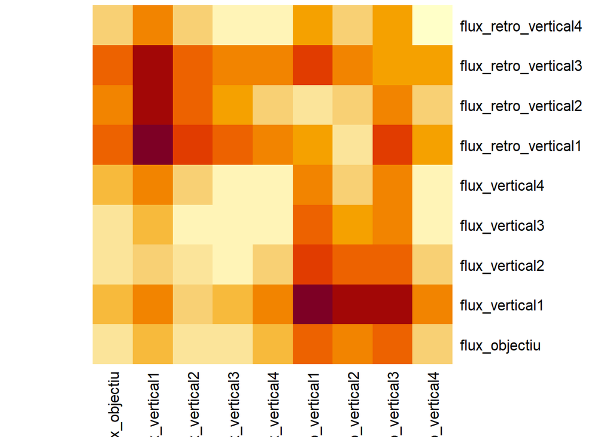

```r
## 0. Preparem taula de puntes dels vectors directors

# Ens quedem només amb els fluxos generals (sense objectiu)
fluxos_sense_obj <- subset(taula_general_fluxos)#, flux != "flux_objectiu")

# Coordenades dels nodes
coords <- coords3Dn_diag_corr1


# Calculem els punts finals dels vectors directors
puntes <- data.frame(
  Xend = coords[fluxos_sense_obj$node_2, "X"] + fluxos_sense_obj$u_bar_X,
  Yend = coords[fluxos_sense_obj$node_2, "Y"] + fluxos_sense_obj$u_bar_Y,
  Zend = coords[fluxos_sense_obj$node_2, "Z"] + fluxos_sense_obj$u_bar_Z,
  row.names = fluxos_sense_obj$flux
)

# 1. Puntes dels fluxos verticals i retroverticals (sense objectiu)
puntes_cm <- puntes

# 2. Centre de masses
centre <- colMeans(puntes_cm)

# 3. Distància al centre
dist_centre <- apply(puntes, 1, function(p)
  sqrt(sum((p - centre)^2)))

# 4. Matriu de distàncies
n <- nrow(puntes)
D <- matrix(0, n, n)
rownames(D) <- colnames(D) <- rownames(puntes)

for (i in 1:n) {
  for (j in 1:n) {
    D[i, j] <- sqrt(sum((puntes[i, ] - puntes[j, ])^2))
  }
}

# 5. Substituïm la diagonal per distància al centre
diag(D) <- dist_centre

# Resultat final
matriu_distancies <- D

heatmap(as.matrix(matriu_distancies), Rowv = NA, Colv = NA, scale = "none")
```

```r
knitr::kable(matriu_distancies)
```

|  | flux_objectiu | flux_vertical1 | flux_vertical2 | flux_vertical3 | flux_vertical4 | flux_retro_vertical1 | flux_retro_vertical2 | flux_retro_vertical3 | flux_retro_vertical4 |
| --- | --- | --- | --- | --- | --- | --- | --- | --- | --- |
| flux_objectiu | 19.56186 | 32.65858 | 19.39109 | 21.62284 | 32.22451 | 48.01474 | 44.02211 | 50.42988 | 23.734042 |
| flux_vertical1 | 32.65858 | 42.08075 | 24.04664 | 33.23507 | 46.40157 | 77.03674 | 69.31054 | 70.58422 | 46.564672 |
| flux_vertical2 | 19.39109 | 24.04664 | 20.43137 | 12.69367 | 27.66749 | 58.71860 | 49.07335 | 47.38882 | 25.074532 |
| flux_vertical3 | 21.62284 | 33.23507 | 12.69367 | 11.62388 | 15.00100 | 49.18087 | 37.90876 | 45.07954 | 14.972098 |
| flux_vertical4 | 32.22451 | 46.40157 | 27.66749 | 15.00100 | 15.24587 | 41.15570 | 27.14627 | 46.44092 | 13.297265 |
| flux_retro_vertical1 | 48.01474 | 77.03674 | 58.71860 | 49.18087 | 41.15570 | 38.89949 | 17.33421 | 56.02190 | 35.121340 |
| flux_retro_vertical2 | 44.02211 | 69.31054 | 49.07335 | 37.90876 | 27.14627 | 17.33421 | 28.87303 | 46.40274 | 24.072799 |
| flux_retro_vertical3 | 50.42988 | 70.58422 | 47.38882 | 45.07954 | 46.44092 | 56.02190 | 46.40274 | 39.29908 | 38.762934 |
| flux_retro_vertical4 | 23.73404 | 46.56467 | 25.07453 | 14.97210 | 13.29726 | 35.12134 | 24.07280 | 38.76293 | 4.971639 |

```r
nodes_cadena_PIP3_Plcg_PKC <- c("PIP3", "Plcg", "PKC")
cadena3n_PIP3_Plcg_PKC <- induced_subgraph(g_bosc, vids = nodes_cadena_PIP3_Plcg_PKC)
coords_cadena3n_PIP3_Plcg_PKC <- coords3Dn_diag_corr1[c("PIP3", "Plcg", "PKC"), c("X", "Y", "Z")]

# longitud camí
len_flux0 <- longitud_cami_fisic(cadena3n_PIP3_Plcg_PKC, coords3Dn_diag_corr1)

res_flux0 <- theta_flux_vectorial_Z_fisic(cadena3n_PIP3_Plcg_PKC, coords3Dn_diag_corr1)
u_bar0 <- as.numeric(res_flux0$u_bar)
u_dir0 <- u_bar0 / sqrt(sum(u_bar0^2))

p0_flux0 <- coords_cadena3n_PIP3_Plcg_PKC["PIP3",c("X","Y","Z")]
p1_flux0 <- p0_flux0 + len_flux0 * u_dir0


#_______________________________________________________________________________

nodes_collididor_PKA_P38_PKC <- c("PKA", "P38", "PKC")
collididor3n_PKA_P38_PKC <- induced_subgraph(g_bosc, vids = nodes_collididor_PKA_P38_PKC)
coords_collididor_PKA_P38_PKC  <- coords3Dn_diag_corr1[c("PKA", "P38", "PKC"), c("X", "Y", "Z")]

# longitud camí
len_flux1 <- longitud_cami_fisic(collididor3n_PKA_P38_PKC, coords3Dn_diag_corr1)

res_flux1 <- theta_flux_collididor_Z_fisic(collididor3n_PKA_P38_PKC, coords3Dn_diag_corr1)
r_in1 <- as.numeric(res_flux1$r_in)
u_dir1 <- r_in1 / sqrt(sum(r_in1^2))

p0_flux1 <- coords_collididor_PKA_P38_PKC["P38",c("X","Y","Z")]
p1_flux1 <- p0_flux1 + len_flux1 * u_dir1
#[1]____________________________________________________________________________

nodes_collididor_PKA_Jnk_PKC <- c("PKA", "Jnk", "PKC")
collididor3n_PKA_Jnk_PKC <- induced_subgraph(g_bosc, vids = nodes_collididor_PKA_Jnk_PKC)
coords_collididor_PKA_Jnk_PKC  <- coords3Dn_diag_corr1[c("PKA", "Jnk", "PKC"), c("X", "Y", "Z")]

# longitud camí
len_flux2 <- longitud_cami_fisic(collididor3n_PKA_Jnk_PKC, coords3Dn_diag_corr1)

res_flux2 <- theta_flux_collididor_Z_fisic(collididor3n_PKA_Jnk_PKC, coords3Dn_diag_corr1)
r_in2 <- as.numeric(res_flux2$r_in)
u_dir2 <- r_in2 / sqrt(sum(r_in2^2))

p0_flux2 <- coords_collididor_PKA_Jnk_PKC["Jnk",c("X","Y","Z")]
p1_flux2 <- p0_flux2 + len_flux2 * u_dir2


#_______________________________________________________________________________

nodes_collididor_PKA_Mek_PKC <- c("PKA", "Mek", "PKC")
collididor3n_PKA_Mek_PKC <- induced_subgraph(g_bosc, vids = nodes_collididor_PKA_Mek_PKC)
coords_collididor_PKA_Mek_PKC  <- coords3Dn_diag_corr1[c("PKA", "Mek", "PKC"), c("X", "Y", "Z")]

# longitud camí
len_flux3 <- longitud_cami_fisic(collididor3n_PKA_Mek_PKC, coords3Dn_diag_corr1)

res_flux3 <- theta_flux_collididor_Z_fisic(collididor3n_PKA_Mek_PKC, coords3Dn_diag_corr1)
r_in3 <- as.numeric(res_flux3$r_in)
u_dir3 <- r_in3 / sqrt(sum(r_in3^2))

p0_flux3 <- coords_collididor_PKA_Mek_PKC["Mek",c("X","Y","Z")]
p1_flux3 <- p0_flux3 + len_flux3 * u_dir3

#_______________________________________________________________________________

nodes_collididor_PKA_Raf_PKC <- c("PKA", "Raf", "PKC")
collididor3n_PKA_Raf_PKC <- induced_subgraph(g_bosc, vids = nodes_collididor_PKA_Raf_PKC)
coords_collididor_PKA_Raf_PKC  <- coords3Dn_diag_corr1[c("PKA", "Raf", "PKC"), c("X", "Y", "Z")]

# longitud camí
len_flux4 <- longitud_cami_fisic(collididor3n_PKA_Raf_PKC, coords3Dn_diag_corr1)

res_flux4 <- theta_flux_collididor_Z_fisic(collididor3n_PKA_Raf_PKC, coords3Dn_diag_corr1)
r_in4 <- as.numeric(res_flux4$r_in)
u_dir4 <- r_in4 / sqrt(sum(r_in4^2))

p0_flux4 <- coords_collididor_PKA_Raf_PKC["Raf",c("X","Y","Z")]
p1_flux4 <- p0_flux4 + len_flux4 * u_dir4



#_______________________________________________________________________________

nodes_cadena_Raf_Mek_Erk <- c("Raf", "Mek", "Erk")
cadena3n_Raf_Mek_Erk <- induced_subgraph(g_bosc, vids = nodes_cadena_Raf_Mek_Erk)
coords_cadena3n_Raf_Mek_Erk <- coords3Dn_diag_corr1[c("Raf", "Mek", "Erk"), c("X", "Y", "Z")]

# longitud camí
len_flux <- longitud_cami_fisic(cadena3n_Raf_Mek_Erk, coords3Dn_diag_corr1)

res_flux <- theta_flux_vectorial_Z_fisic(cadena3n_Raf_Mek_Erk, coords3Dn_diag_corr1)
u_bar <- as.numeric(res_flux$u_bar)
u_dir <- u_bar / sqrt(sum(u_bar^2))

p0_flux <- coords_cadena3n_Raf_Mek_Erk["Raf",c("X","Y","Z")]
p1_flux <- p0_flux + len_flux * u_dir

#_______________________________________________________________________________

# bloc de codi fins a [2] per tal de desplaçar el model a un espai positiu
# hom combina totes les coordenades que apareixen al gràfic
all_coords1 <- rbind(coords3Dn_diag_corr1,
                      p0_flux,  p1_flux,
                      p0_flux0, p1_flux0,
                      p0_flux1, p1_flux1,
                      p0_flux2, p1_flux2,
                      p0_flux3, p1_flux3,
                      p0_flux4, p1_flux4
                      )
# hom calcula quant s'ha de desplaçar cada eix perquè el mínim sigui 000
offset5 <- apply(all_coords1, 2, min)

# hom aplica el desplaçament
coords3Dn_diag_corr5 <- sweep(coords3Dn_diag_corr1, 2, offset5, "-")
p0_flux   <- p0_flux  - offset5
p1_flux   <- p1_flux  - offset5
p0_flux0  <- p0_flux0 - offset5
p1_flux0  <- p1_flux0 - offset5
p0_flux1  <- p0_flux1 - offset5
p1_flux1  <- p1_flux1 - offset5
p0_flux2  <- p0_flux2 - offset5
p1_flux2  <- p1_flux2 - offset5
p0_flux3  <- p0_flux3 - offset5
p1_flux3  <- p1_flux3 - offset5
p0_flux4  <- p0_flux4 - offset5
p1_flux4  <- p1_flux4 - offset5
# [2]___________________________________________________________________________



open3d()
```

```
## wgl
##  35
```

```r
plot3d(coords3Dn_diag_corr5, col = "orangered", size = 1, type = "s")

edges <- as_edgelist(g_bosc)
#edges1 <- edges[-c(1,18),]

# hom converteix els subgrafs en vectors d’arestes (com "A_B")
edges1_vert <- apply(as_edgelist(g_bosc_vertical1), 1, paste, collapse = "_")
edges1_lat <- apply(as_edgelist(g_retrolateral1), 1, paste, collapse = "_")

# assigna color segons pertinença
edge_colors <- sapply(1:nrow(edges1), function(i) {
 e <- paste(edges1[i, 1], edges1[i, 2], sep = "_")
 if (e %in% edges1_vert) {
  return("skyblue3")  # flux vertical (causal)
 } else if (e %in% edges1_lat) {
  return("gold") # connexió retrolateral (retroflux i lateral)
 }
})


for (i in 1:nrow(edges1)) {
 v1 <- which(V(g_bosc)$name == edges1[i, 1])
 v2 <- which(V(g_bosc)$name == edges1[i, 2])
 segments3d(rbind(coords3Dn_diag_corr5[v1, ], coords3Dn_diag_corr5[v2, ]),
      col = edge_colors[i], lwd = 0.9)
}

#offset <- seq(-0.04, 0.04, length.out=nrow(coords3Dn_diag_corr5))
text3d(coords3Dn_diag_corr5[, "X"]+0.02,
       coords3Dn_diag_corr5[, "Y"],
       coords3Dn_diag_corr5[, "Z"]+2,
       texts = rownames(coords3Dn_diag_corr5),
       adj = c(0, 0.2),
       cex=0.9)

#edges1 <- E(g_bosc)[c(18,1)]
#segments3d(rbind(coords3Dn_diag_corr5[7, ], coords3Dn_diag_corr5[1, ]),col = "blue", lwd = 1.5)
#segments3d(rbind(coords3Dn_diag_corr5[1, ], coords3Dn_diag_corr5[8, ]),col = "blue", lwd = 1.5)

# segeta daurada1
arrow3d(
  p0 = p0_flux1,
  p1 = p1_flux1,
  col = "red",
  type = "rotation",
  lwd = 2,
  width = 0.3,
  barblen = 0.02
)
text3d(p1_flux1[1], p1_flux1[2], p1_flux1[3] + 4,
       texts = "Flux retrovertical 1", color = "black")


# segeta blava2
arrow3d(
  p0 = p0_flux2,
  p1 = p1_flux2,
  col = "red",
  type = "rotation",
  lwd = 2,
  width = 0.3,
  barblen = 0.02
)
text3d(p1[1], p1[2], p1[3] + 4,
       texts = "Flux retrovertical 2", color = "black")


# segeta blava2
arrow3d(
  p0 = p0_flux3,
  p1 = p1_flux3,
  col = "red",
  type = "rotation",
  lwd = 2,
  width = 0.3,
  barblen = 0.02
)
text3d(p1[1], p1[2], p1[3] + 4,
       texts = "Flux retrovertical 3", color = "black")



# segeta blava3
arrow3d(
  p0 = p0_flux4,
  p1 = p1_flux4,
  col = "red",
  type = "rotation",
  lwd = 2,
  width = 0.3,
  barblen = 0.02
)
text3d(p1[1], p1[2], p1[3] + 4,
       texts = "Flux retrovertical 4", color = "black")


# segeta blava1
arrow3d(
  p0 = p0_flux0,
  p1 = p1_flux0,
  col = "blue",
  type = "rotation",
  lwd = 2,
  width = 0.3,
  barblen = 0.02
)
text3d(p1_flux1[1], p1_flux1[2], p1_flux1[3] + 4,
       texts = "Flux vertical 1", color = "black")


# segeta blava2
arrow3d(
  p0 = coords3Dn_diag_corr5[3,] ,
  p1 = coords3Dn_diag_corr5[2,] ,
  col = "blue",
  type = "rotation",
  lwd = 2,
  width = 0.3,
  barblen = 0.02
)
text3d(p1[1], p1[2], p1[3] + 1,
       texts = "Flux vertical 2", color = "black")


# segeta blava3
arrow3d(
  p0 = coords3Dn_diag_corr5[3,] ,
  p1 = coords3Dn_diag_corr5[9,] ,
  col = "blue",
  type = "rotation",
  lwd = 2,
  width = 0.3,
  barblen = 0.02
)
text3d(p1[1], p1[2], p1[3] + 1,
       texts = "Flux vertical 3", color = "black")



# segeta blava4
arrow3d(
  p0 = coords3Dn_diag_corr5[4,] ,
  p1 = coords3Dn_diag_corr5[8,] ,
  col = "blue",
  type = "rotation",
  lwd = 2,
  width = 0.3,
  barblen = 0.02
)
text3d(p1[1], p1[2], p1[3] + 1,
       texts = "Flux vertical 4", color = "black")



#edges1 <- E(g_bosc)[c(18,1)]
segments3d(rbind(coords3Dn_diag_corr5[7, ], coords3Dn_diag_corr5[1, ]),
      col = "purple", lwd = 1.5)
segments3d(rbind(coords3Dn_diag_corr5[1, ], coords3Dn_diag_corr5[8, ]),
      col = "purple", lwd = 1.5)

# segeta blava
arrow3d(
  p0 = p0_flux,
  p1 = p1_flux,
  col = "purple1",
  type = "rotation",
  lwd = 3,
  width = 0.3,
  barblen = 0.02
)
text3d(p1_flux[1], p1_flux[2], p1_flux[3] + 1,
       texts = "FC local", color = "purple1")


#   el flux causal global
res_global <- mitjana_vectorial_global(taula_general_fluxos)

v_sum <- res_global$v_sum # components reals
v_global <- res_global$v_global # direcció normalitzada

# hom escala la segeta perquè sigui comparable amb el model
escala <- 20
p0 <- coords3Dn_diag_corr5["Erk",]
p1 <- p0 + v_global * escala # direcció

arrow3d(
  p0 = p0,
  p1 = p1,
  type = "rotation",
  col = "purple4",
  lwd = 3,
  width = 0.3,
  barblen = 0.02
)

text3d(p1,
       texts = "Flux causal vertical",
       col = "purple4")




aspect3d(1,1,1)




centre <- colMeans(coords3Dn_diag_corr5) # mitjana de cada eix X,Y,Z
#  punt del centre
points3d(centre[1], centre[2], centre[3], color = "orangered4", size = 5)
# eixos centrats al centre de masses
dx <- (xmax - xmin) / 2
dy <- (ymax - ymin) / 2
dz <- (zmax - zmin) / 2

segments3d(rbind(centre - c(dx, 0, 0), centre + c(dx, 0, 0)), col="orangered4", lwd=0.9)
segments3d(rbind(centre - c(0, dy, 0), centre + c(0, dy, 0)), col="orangered4", lwd=0.9)
segments3d(rbind(centre - c(0, 0, dz), centre + c(0, 0, dz)), col="orangered4", lwd=0.9)




bbox <- par3d("bbox")
xmin <- bbox[1]; xmax <- bbox[2]
ymin <- bbox[3]; ymax <- bbox[4]
zmin <- bbox[5]; zmax <- bbox[6]

segments3d(rbind(c(xmin, ymin, zmin), c(xmax, ymin, zmin)), col="red", lwd=3)
text3d(xmax, ymin, zmin, texts="X = deg_out", color="red", adj=c(-0.2,0.5))

segments3d(rbind(c(xmin, ymin, zmin), c(xmin, ymax, zmin)), col="green3", lwd=3)
text3d(xmin, ymax, zmin, texts="Y = deg_in", color="green3", adj=c(0.5,-0.2))

segments3d(rbind(c(xmin, ymin, zmin), c(xmin, ymin, zmax)), col="blue3", lwd=3)
text3d(xmin, ymin, zmax, texts="Z = nivell", color="blue3", adj=c(0.5,0))
rglwidget()
```

[interactive chart not shown]

## *5.8 Càlcul de l’angle de flux causal holístic (ZYX) del model topoempíric: flux_fulla_corregit*

```r
collididor3n_PKA_P38_PKC <- crea_collididor_artificial(   g_bosc, chain_nodes = c("PKA","P38","PKC"))
collididor3n_PKA_Jnk_PKC <- crea_collididor_artificial(   g_bosc, chain_nodes = c("PKA","Jnk","PKC"))
collididor3n_PIP3_Akt_PKA <- crea_collididor_artificial(   g_bosc, chain_nodes = c("PIP3","Akt","PKA"))
collididor3n_PKA_Erk_Mek <- crea_collididor_artificial(   g_bosc, chain_nodes = c("PKA","Erk","Mek"))

#_______________________________________________________________________________
nodes_cadena_Raf_Mek_Erk <- c("Raf", "Mek", "Erk")
cadena3n_Raf_Mek_Erk <- induced_subgraph(g_bosc, vids = nodes_cadena_Raf_Mek_Erk)
# Flux objectiu
flux_objectiu <- theta_flux_vectorial_Z_fisic(cadena3n_Raf_Mek_Erk, coords3Dn_diag_corr1)

# Flux fulla vertical (1 col·lididor fulla vertical)
flux1_coll_ver <- theta_flux_collididor_Z_fisic(collididor3n_PIP3_Akt_PKA, coords3Dn_diag_corr1)

# Fluxos fulles retroverticals (2 col·lididors fulla retro-verticals)
flux2_coll_retrover <- theta_flux_collididor_Z_fisic(collididor3n_PKA_P38_PKC, coords3Dn_diag_corr1)
flux3_coll_retrover <- theta_flux_collididor_Z_fisic(collididor3n_PKA_Jnk_PKC, coords3Dn_diag_corr1)

# Flux fulla laterovertical (1 col·lididor fulla latero-vertical)
flux4_coll_laterover <- theta_flux_collididor_Z_fisic(collididor3n_PKA_Erk_Mek, coords3Dn_diag_corr1)


taula_fluxos_general <- function(fluxos) {
  extreu <- function(f) {

    if ("u_bar" %in% names(f$res)) {
      # vertical
      v <- f$res$u_bar
      modul <- f$res$len_u
    } else {
      # col·lidor
      v <- f$res$r_in
      modul <- f$res$len_r
    }

    tibble::tibble(
      flux  = f$nom,
      node_1 = f$nodes[1],
      node_2 = f$nodes[2],
      node_3 = ifelse(length(f$nodes) == 3, f$nodes[3], NA),
      u_bar_X = v[1],
      u_bar_Y = v[2],
      u_bar_Z = v[3],
      modul = modul,
      flux_z = f$res$flux_z,
      theta_z = f$res$theta_z,
      signe = f$res$signe
    )
  }

  dplyr::bind_rows(lapply(fluxos, extreu))
}



fluxos1 <- list(
  list(
    nom = "flux_objectiu",
    res = flux_objectiu,
    nodes = c("Raf", "Mek", "Erk")
  ),
  list(
    nom = "flux1_coll_ver",
    res = flux1_coll_ver,
    nodes = c("PIP3", "Akt", "PKA")
  ),
  list(
    nom = "flux2_coll_retrover",
    res = flux2_coll_retrover,
    nodes = c("PKA", "P38", "PKC")
  ),
  list(
    nom = "flux3_coll_retrover",
    res = flux3_coll_retrover,
    nodes = c("PKA", "Jnk", "PKC")
  ),
  list(
    nom = "flux4_coll_laterover",
    res = flux4_coll_laterover,
    nodes = c("PKA", "Erk", "Mek")
  )
)


# --- Funció: calcula la mitjana vectorial global ----------------------

mitjana_vectorial_global <- function(taula_fluxos) {
  # 1. Excloem el flux objectiu: NO entra en la mitjana
  taula2 <- taula_fluxos %>%
    dplyr::filter(flux != "flux_objectiu")

  # 2. Matriu dels vectors (u_bar_X, u_bar_Y, u_bar_Z)
  V <- as.matrix(taula2[, c("u_bar_X", "u_bar_Y", "u_bar_Z")])

  # 3. Mòduls = pesos
  w <- sqrt(rowSums(V^2))

  # 4. Normalitzem cada vector
  U_norm <- V / w

  # 5. Suma vectorial ponderada
  v_sum <- colSums(w * U_norm)

  # 6. Normalitzem la direcció resultant
  v_global <- v_sum / sqrt(sum(v_sum^2))

  # 7. Angle vertical RESULTANT (respecte Z)
  # → No s’utilitza cap node, només la direcció general
  cos_theta <- v_global[3] / sqrt(sum(v_global^2)) # component Z
  angle_graus <- acos(cos_theta) * 180 / pi

  # 8. Angle del flux objectiu (ja està a la taula!)
  angle_objectiu <- taula_fluxos$theta_z[taula_fluxos$flux == "flux_objectiu"]

  # 9. Diferència d’angles
  diferencia_angles <- abs(angle_objectiu - angle_graus)

  # 10. Retornem tot
  list(
    vectors_utilitzats = taula2$flux,
    v_sum = v_sum,
    v_global = v_global,
    angle_vertical = angle_graus,
    angle_objectiu = angle_objectiu,
    diferencia_angles = diferencia_angles
  )
}


## ---- Diferències angulars detallades ----
taula_general_fluxos_fulla <- taula_fluxos_general(fluxos1)
resultat1 <- mitjana_vectorial_global(taula_general_fluxos_fulla)

v_obj <- as.numeric(t(taula_general_fluxos_fulla[taula_general_fluxos_fulla$flux == "flux_objectiu", c("u_bar_X", "u_bar_Y", "u_bar_Z")]))

# normalitza vectors
ng <- resultat1$v_global / sqrt(sum(resultat1$v_global^2))
no <- v_obj / sqrt(sum(v_obj^2))

# angles per eix
ang_X <- acos(ng[1] * no[1]) * 180 / pi
ang_Y <- acos(ng[2] * no[2]) * 180 / pi
ang_Z <- acos(ng[3] * no[3]) * 180 / pi

# angle total 3D
ang_total <- acos(sum(ng * no)) * 180 / pi

resultat_angles <- list(
  angle_X = ang_X,
  angle_Y = ang_Y,
  angle_Z = ang_Z,
  angle_total_3D = ang_total
)

resultat_angles
```

```
## $angle_X
##  u_bar_X
## 24.55658
##
## $angle_Y
##  u_bar_Y
## 92.91845
##
## $angle_Z
##  u_bar_Z
## 89.53264
##
## $angle_total_3D
## [1] 29.91185
```

```r
## ---- Diferències angulars detallades ----
taula_general_fluxos_fulla <- taula_fluxos_general(fluxos1)
resultat1 <- mitjana_vectorial_global(taula_general_fluxos_fulla)
```